# Detecting Bugs in IOT Applications using Machine Learning Techniques

#### Please use the following Fragment identifiers to reach the relevent sections of the report.

Preparing the Data

Visualising the Data

Training and Testing Machine Learning Algorithms on Features of IoT Applications

Logistic Regression

Decision Tree

Random Forest

Support Vector Machine

10 Fold Cross Validation

Plotting the learnt Decision Tree

# Preparing the Data

**Parsing the text output files from the SAINT tool**

```python
import pandas as pd
```

**Reading Sink ('Method Name', 'Usage', 'Arguments', 'Type') from Malicious Community apps**

```python
#Reading all file names in a directory
import os
fileNames = os.listdir('sorted_apps\\community\\malicious')
fileNames
```

```
['beacon-control.txt',
 'bon-voyage.txt',
 'close-the-valve.txt',
 'curb-energy-monitor.txt',
 'door-jammed-notification.txt',
 'door-lock-code-distress-message.txt',
 'ecobee-connect.txt',
 'elder-care-daily-routine.txt',
 'elder-care-slip-fall.txt',
 'flood-alert.txt',
 'forgiving-security.txt',
 'garage-door-monitor.txt',
 'good-night.txt',
 'goodnight-ubi.txt',
 'greetings-earthling.txt',
 'habit-helper.txt',
 'hello-home-phrase-director.txt',
 'initial-state-event-streamer.txt',
 'it-moved.txt',
 'its-too-hot.txt',
 'jawbone-button-notifier.txt',
 'laundry-monitor.txt',
 'left-it-open.txt',
 'lock-it-at-a-specific-time.txt',
 'lock-it-when-i-leave.groovy.txt',
 'mail-arrived.txt',
 'medicine-management-temp-motion.txt',
 'medicine-reminder.txt',
 'nobody-home.txt',
 'photo-burst-when.txt',
 'presence-change-push.txt',
 'presence-change-text.txt',
 'quirky-connect.txt',
 'ridiculously-automated-garage-door.txt',
 'rise-and-shine.txt',
 'safe-watch.txt',
 'scheduled-mode-change.txt',
 'smart-auto-lock-unlock.txt',
 'smart-energy-service.txt',
 'smartblock-chat-sender.txt',
 'text-me-when-it-opens.txt',
 'text-me-when-theres-motion-and-im-not-here.txt',
 'the-gun-case-moved.txt',
 'thermostats.txt',
 'unlock-it-when-i-arrive.txt',
 'weather-underground-pws-connect.txt',
 'weather-windows.txt',
 'weatherbug-home.txt',
 'when-its-going-to-rain.txt']
```

```python
dfcols = ['App Name','Method Name', 'Usage', 'Arguments','Type']
df_Community_Malicious = pd.DataFrame(columns=dfcols)
for fileName in fileNames:

    appName = fileName[:fileName.index('.')].strip()
    with open(("sorted_apps\\community\\malicious\\"+fileName), 'r') as text:
        i = 0
        dictSink = {}
        for line in text.readlines():
            if (line[:14].strip() == "Data Flow Path"):
                break

            if((len(line.split(':'))<2) and (len(line.strip())>0)):
                #print(line)
                dictSink['App Name'] = appName
                dictSink["Type"] = 'Sink'
                dictSink["Usage"] = line.strip()

            if(line.split(':')[0].strip() == 'Method Name'):
                #print(line)
                dictSink[line.split(':')[0].strip()] = line.split(':')[1].split(' ')[1].strip()
                #print(i,dictSink,' __ ',line)

            if(line.split(':')[0].strip() == 'Arguments'):
                #print(line)
                #if I use a simple split on ':' to read argument and its value it does not read
                #the whole argument is not read in the cases like 'Arguments: ($decodedString, [method:push])'
                #dictSink[line.split(':')[0].strip()] = line.split(':')[1].split(' ')[1].strip()
                dictSink[line[:line.index(':')].strip()] = line[line.index(':')+1:].strip()
                #print(i,dictSink,' __ ',line)

                df_Community_Malicious = df_Community_Malicious.append(dictSink,ignore_index=True)
                dictSink = {}

            #i = i+1
            #print(i)
df_Community_Malicious
```

|  | App Name | Method Name | Usage | Arguments | Type |
| --- | --- | --- | --- | --- | --- |
| 0 | beacon-control | sendNotification | Does CALLING | (msg, options) | Sink |
| 1 | bon-voyage | sendNotificationToContacts | Does CALLING | (msg, recipients) | Sink |
| 2 | bon-voyage | sendNotificationToContacts | Does CALLING | (msg, recipients) | Sink |
| 3 | bon-voyage | sendPush | Sends SMS or MESSAGE | (msg) | Sink |
| 4 | bon-voyage | sendSms | Sends SMS or MESSAGE | (phone, msg) | Sink |
| 5 | close-the-valve | sendPush | Sends SMS or MESSAGE | (msg) | Sink |
| 6 | close-the-valve | sendSms | Sends SMS or MESSAGE | (phone, msg) | Sink |
| 7 | curb-energy-monitor | httpGet | Uses INTERNET | (params) | Sink |
| 8 | curb-energy-monitor | httpGet | Uses INTERNET | (params) | Sink |
| 9 | curb-energy-monitor | httpGet | Uses INTERNET | (params) | Sink |
| 10 | curb-energy-monitor | httpPostJson | Uses INTERNET | ([uri:curbTokenUrl, body:tokenParams]) | Sink |
| 11 | curb-energy-monitor | httpPostJson | Uses INTERNET | ([uri:curbTokenUrl, body:tokenParams]) | Sink |
| 12 | door-jammed-notification | sendNotificationToContacts | Does CALLING | (msg, recipients) | Sink |
| 13 | door-jammed-notification | sendNotificationToContacts | Does CALLING | (msg, recipients) | Sink |
| 14 | door-jammed-notification | sendPush | Sends SMS or MESSAGE | (msg) | Sink |
| 15 | door-jammed-notification | sendSms | Sends SMS or MESSAGE | (phone, msg) | Sink |
| 16 | door-lock-code-distress-message | sendPush | Sends SMS or MESSAGE | (Door unlocked with user code $lockData.usedCode) | Sink |
| 17 | door-lock-code-distress-message | sendSms | Sends SMS or MESSAGE | (phone1, distressMsg) | Sink |
| 18 | ecobee-connect | httpPost | Uses INTERNET | ([uri:tokenUrl]) | Sink |
| 19 | ecobee-connect | httpGet | Uses INTERNET | (deviceListParams) | Sink |
| 20 | ecobee-connect | httpGet | Uses INTERNET | (switchListParams) | Sink |
| 21 | ecobee-connect | sendPushAndFeeds | Sends SMS or MESSAGE | (notificationMessage) | Sink |
| 22 | ecobee-connect | httpGet | Uses INTERNET | (pollParams) | Sink |
| 23 | ecobee-connect | httpGet | Uses INTERNET | (switchListParams) | Sink |
| 24 | ecobee-connect | httpPut | Uses INTERNET | (params) | Sink |
| 25 | ecobee-connect | sendPushAndFeeds | Sends SMS or MESSAGE | (notificationMessage) | Sink |
| 26 | ecobee-connect | httpPost | Uses INTERNET | (refreshParams) | Sink |
| 27 | ecobee-connect | sendPushAndFeeds | Sends SMS or MESSAGE | (notificationMessage) | Sink |
| 28 | ecobee-connect | sendPushAndFeeds | Sends SMS or MESSAGE | (notificationMessage) | Sink |
| 29 | ecobee-connect | httpPost | Uses INTERNET | (cmdParams) | Sink |
| ... | ... | ... | ... | ... | ... |
| 145 | smart-auto-lock-unlock | sendSms | Sends SMS or MESSAGE | (phoneNumber, $lock1 locked after $contact1 wa... | Sink |
| 146 | smart-auto-lock-unlock | sendPush | Sends SMS or MESSAGE | ($lock1 unlocked after $contact1 was open for ... | Sink |
| 147 | smart-auto-lock-unlock | sendSms | Sends SMS or MESSAGE | (phoneNumber, $lock1 unlocked after $contact1 ... | Sink |
| 148 | smart-energy-service | httpPut | Uses INTERNET | (param) | Sink |
| 149 | smart-energy-service | httpPost | Uses INTERNET | (param) | Sink |
| 150 | smart-energy-service | httpGet | Uses INTERNET | (param) | Sink |
| 151 | smart-energy-service | sendNotification | Does CALLING | ($decodedString, [method:push]) | Sink |
| 152 | smart-energy-service | sendNotificationEvent | Does CALLING | ($decodedString) | Sink |
| 153 | smartblock-chat-sender | httpPost | Uses INTERNET | (url, foo=bar, { java.lang.Object response -> ... | Sink |
| 154 | text-me-when-it-opens | sendNotificationToContacts | Does CALLING | (Your $(contact1.label) ? contact1.label : con... | Sink |
| 155 | text-me-when-it-opens | sendNotificationToContacts | Does CALLING | (Your $(contact1.label) ? contact1.label : con... | Sink |
| 156 | text-me-when-it-opens | sendSms | Sends SMS or MESSAGE | (phone1, Your $(contact1.label) ? contact1.lab... | Sink |
| 157 | text-me-when-theres-motion-and-im-not-here | sendNotificationToContacts | Does CALLING | ($motion1.label $motion1.name moved while you ... | Sink |
| 158 | text-me-when-theres-motion-and-im-not-here | sendNotificationToContacts | Does CALLING | ($motion1.label $motion1.name moved while you ... | Sink |
| 159 | text-me-when-theres-motion-and-im-not-here | sendSms | Sends SMS or MESSAGE | (phone1, $motion1.label $motion1.name moved wh... | Sink |
| 160 | the-gun-case-moved | sendNotificationToContacts | Does CALLING | (Gun case has moved!, recipients) | Sink |
| 161 | the-gun-case-moved | sendNotificationToContacts | Does CALLING | (Gun case has moved!, recipients) | Sink |
| 162 | the-gun-case-moved | sendSms | Sends SMS or MESSAGE | (phone1, Gun case has moved!) | Sink |
| 163 | thermostats | sendNotificationToContacts | Does CALLING | (msg, recipients, options) | Sink |
| 164 | thermostats | sendNotificationToContacts | Does CALLING | (msg, recipients, options) | Sink |
| 165 | thermostats | sendNotification | Does CALLING | (msg, options) | Sink |
| 166 | unlock-it-when-i-arrive | sendPush | Sends SMS or MESSAGE | (Unlocked door due to arrival of $evt.displayN... | Sink |
| 167 | weather-underground-pws-connect | httpGet | Uses INTERNET | (params) | Sink |
| 168 | weather-windows | sendPush | Sends SMS or MESSAGE | (msg) | Sink |
| 169 | weather-windows | sendSms | Sends SMS or MESSAGE | (phone1, msg) | Sink |
| 170 | weatherbug-home | httpPostJson | Uses INTERNET | (postParams) | Sink |
| 171 | weatherbug-home | httpPostJson | Uses INTERNET | (postParams) | Sink |
| 172 | when-its-going-to-rain | sendNotificationToContacts | Does CALLING | (A storm is a coming and the following things ... | Sink |
| 173 | when-its-going-to-rain | sendNotificationToContacts | Does CALLING | (A storm is a coming and the following things ... | Sink |
| 174 | when-its-going-to-rain | sendSms | Sends SMS or MESSAGE | (phone, A storm is a coming and the following ... | Sink |

175 rows × 5 columns

```python
df_Community_Malicious['Method Name'].unique()
```

```
array(['sendNotification', 'sendNotificationToContacts', 'sendPush',
       'sendSms', 'httpGet', 'httpPostJson', 'httpPost',
       'sendPushAndFeeds', 'httpPut', 'httpDelete', 'httpPutJson',
       'sendNotificationEvent'], dtype=object)
```

```python
colNames = ['App_Name','Type','Category','numSinks', 'sendNotification', 'sendNotificationToContacts', 'sendPush', 'sendSms'
            , 'httpGet', 'httpPostJson', 'httpPost', 'httpPut', 'httpDelete', 'httpPutJson']

df_Community_Malicious_Sinks = pd.DataFrame(columns=colNames)
for fileName in fileNames:

    appName = fileName[:fileName.index('.')].strip()
    with open(("sorted_apps\\community\\malicious\\"+fileName), 'r') as text:
        i = 0
        dictSink = {'App_Name':'','numSinks':0, 'sendNotification':0, 'sendNotificationToContacts':0, 'sendPush':0, 'sendSms':0, 'httpGet':0,
 'httpPostJson':0, 'httpPost':0, 'httpPut':0, 'httpDelete':0, 'httpPutJson':0}
        dictSink['App_Name'] = appName
        dictSink['Type'] = 'Malicious'
        dictSink['Category'] = 'Community'
        for line in text.readlines():
            if (line[:14].strip() == "Data Flow Path"):
                dictSink[line.split('-->')[1].strip()] = dictSink[line.split('-->')[1].strip()]+1
                dictSink['numSinks'] = dictSink['numSinks']+1

        df_Community_Malicious_Sinks = df_Community_Malicious_Sinks.append(dictSink,ignore_index=True)
        dictSink = {}

df_Community_Malicious_Sinks
```

|  | App_Name | Type | Category | numSinks | sendNotification | sendNotificationToContacts | sendPush | sendSms | httpGet | httpPostJson | httpPost | httpPut | httpDelete | httpPutJson |
| --- | --- | --- | --- | --- | --- | --- | --- | --- | --- | --- | --- | --- | --- | --- |
| 0 | beacon-control | Malicious | Community | 4 | 4 | 0 | 0 | 0 | 0 | 0 | 0 | 0 | 0 | 0 |
| 1 | bon-voyage | Malicious | Community | 5 | 0 | 2 | 1 | 2 | 0 | 0 | 0 | 0 | 0 | 0 |
| 2 | close-the-valve | Malicious | Community | 4 | 0 | 0 | 1 | 3 | 0 | 0 | 0 | 0 | 0 | 0 |
| 3 | curb-energy-monitor | Malicious | Community | 5 | 0 | 0 | 0 | 0 | 3 | 2 | 0 | 0 | 0 | 0 |
| 4 | door-jammed-notification | Malicious | Community | 5 | 0 | 2 | 1 | 2 | 0 | 0 | 0 | 0 | 0 | 0 |
| 5 | door-lock-code-distress-message | Malicious | Community | 3 | 0 | 0 | 1 | 2 | 0 | 0 | 0 | 0 | 0 | 0 |
| 6 | ecobee-connect | Malicious | Community | 5 | 0 | 0 | 0 | 0 | 4 | 0 | 1 | 0 | 0 | 0 |
| 7 | elder-care-daily-routine | Malicious | Community | 5 | 0 | 2 | 1 | 2 | 0 | 0 | 0 | 0 | 0 | 0 |
| 8 | elder-care-slip-fall | Malicious | Community | 8 | 0 | 2 | 1 | 5 | 0 | 0 | 0 | 0 | 0 | 0 |
| 9 | flood-alert | Malicious | Community | 5 | 0 | 2 | 1 | 2 | 0 | 0 | 0 | 0 | 0 | 0 |
| 10 | forgiving-security | Malicious | Community | 3 | 0 | 0 | 1 | 2 | 0 | 0 | 0 | 0 | 0 | 0 |
| 11 | garage-door-monitor | Malicious | Community | 5 | 0 | 2 | 1 | 2 | 0 | 0 | 0 | 0 | 0 | 0 |
| 12 | good-night | Malicious | Community | 5 | 0 | 2 | 1 | 2 | 0 | 0 | 0 | 0 | 0 | 0 |
| 13 | goodnight-ubi | Malicious | Community | 1 | 0 | 0 | 0 | 0 | 1 | 0 | 0 | 0 | 0 | 0 |
| 14 | greetings-earthling | Malicious | Community | 5 | 0 | 2 | 1 | 2 | 0 | 0 | 0 | 0 | 0 | 0 |
| 15 | habit-helper | Malicious | Community | 5 | 0 | 2 | 0 | 3 | 0 | 0 | 0 | 0 | 0 | 0 |
| 16 | hello-home-phrase-director | Malicious | Community | 5 | 3 | 0 | 2 | 0 | 0 | 0 | 0 | 0 | 0 | 0 |
| 17 | initial-state-event-streamer | Malicious | Community | 2 | 0 | 0 | 0 | 0 | 0 | 2 | 0 | 0 | 0 | 0 |
| 18 | it-moved | Malicious | Community | 4 | 0 | 2 | 0 | 2 | 0 | 0 | 0 | 0 | 0 | 0 |
| 19 | its-too-hot | Malicious | Community | 11 | 0 | 2 | 3 | 6 | 0 | 0 | 0 | 0 | 0 | 0 |
| 20 | jawbone-button-notifier | Malicious | Community | 6 | 0 | 0 | 1 | 5 | 0 | 0 | 0 | 0 | 0 | 0 |
| 21 | laundry-monitor | Malicious | Community | 5 | 0 | 2 | 1 | 2 | 0 | 0 | 0 | 0 | 0 | 0 |
| 22 | left-it-open | Malicious | Community | 5 | 0 | 2 | 1 | 2 | 0 | 0 | 0 | 0 | 0 | 0 |
| 23 | lock-it-at-a-specific-time | Malicious | Community | 7 | 0 | 0 | 2 | 5 | 0 | 0 | 0 | 0 | 0 | 0 |
| 24 | lock-it-when-i-leave | Malicious | Community | 5 | 0 | 4 | 1 | 0 | 0 | 0 | 0 | 0 | 0 | 0 |
| 25 | mail-arrived | Malicious | Community | 5 | 0 | 2 | 1 | 2 | 0 | 0 | 0 | 0 | 0 | 0 |
| 26 | medicine-management-temp-motion | Malicious | Community | 4 | 3 | 0 | 1 | 0 | 0 | 0 | 0 | 0 | 0 | 0 |
| 27 | medicine-reminder | Malicious | Community | 5 | 0 | 2 | 1 | 2 | 0 | 0 | 0 | 0 | 0 | 0 |
| 28 | nobody-home | Malicious | Community | 1 | 0 | 0 | 1 | 0 | 0 | 0 | 0 | 0 | 0 | 0 |
| 29 | photo-burst-when | Malicious | Community | 5 | 0 | 2 | 1 | 2 | 0 | 0 | 0 | 0 | 0 | 0 |
| 30 | presence-change-push | Malicious | Community | 2 | 0 | 0 | 2 | 0 | 0 | 0 | 0 | 0 | 0 | 0 |
| 31 | presence-change-text | Malicious | Community | 6 | 0 | 3 | 0 | 3 | 0 | 0 | 0 | 0 | 0 | 0 |
| 32 | quirky-connect | Malicious | Community | 23 | 0 | 0 | 0 | 0 | 7 | 4 | 1 | 0 | 7 | 4 |
| 33 | ridiculously-automated-garage-door | Malicious | Community | 7 | 0 | 2 | 3 | 2 | 0 | 0 | 0 | 0 | 0 | 0 |
| 34 | rise-and-shine | Malicious | Community | 5 | 0 | 2 | 1 | 2 | 0 | 0 | 0 | 0 | 0 | 0 |
| 35 | safe-watch | Malicious | Community | 3 | 0 | 0 | 1 | 2 | 0 | 0 | 0 | 0 | 0 | 0 |
| 36 | scheduled-mode-change | Malicious | Community | 5 | 0 | 2 | 1 | 2 | 0 | 0 | 0 | 0 | 0 | 0 |
| 37 | smart-auto-lock-unlock | Malicious | Community | 6 | 0 | 0 | 2 | 4 | 0 | 0 | 0 | 0 | 0 | 0 |
| 38 | smart-energy-service | Malicious | Community | 10 | 0 | 0 | 0 | 0 | 8 | 0 | 1 | 1 | 0 | 0 |
| 39 | smartblock-chat-sender | Malicious | Community | 4 | 0 | 0 | 0 | 0 | 0 | 0 | 4 | 0 | 0 | 0 |
| 40 | text-me-when-it-opens | Malicious | Community | 4 | 0 | 2 | 0 | 2 | 0 | 0 | 0 | 0 | 0 | 0 |
| 41 | text-me-when-theres-motion-and-im-not-here | Malicious | Community | 4 | 0 | 2 | 0 | 2 | 0 | 0 | 0 | 0 | 0 | 0 |
| 42 | the-gun-case-moved | Malicious | Community | 4 | 0 | 2 | 0 | 2 | 0 | 0 | 0 | 0 | 0 | 0 |
| 43 | thermostats | Malicious | Community | 7 | 4 | 3 | 0 | 0 | 0 | 0 | 0 | 0 | 0 | 0 |
| 44 | unlock-it-when-i-arrive | Malicious | Community | 1 | 0 | 0 | 1 | 0 | 0 | 0 | 0 | 0 | 0 | 0 |
| 45 | weather-underground-pws-connect | Malicious | Community | 1 | 0 | 0 | 0 | 0 | 1 | 0 | 0 | 0 | 0 | 0 |
| 46 | weather-windows | Malicious | Community | 13 | 0 | 0 | 1 | 12 | 0 | 0 | 0 | 0 | 0 | 0 |
| 47 | weatherbug-home | Malicious | Community | 1 | 0 | 0 | 0 | 0 | 0 | 1 | 0 | 0 | 0 | 0 |
| 48 | when-its-going-to-rain | Malicious | Community | 4 | 0 | 2 | 0 | 2 | 0 | 0 | 0 | 0 | 0 | 0 |

**Reading Sink ('Method Name', 'Usage', 'Arguments', 'Type') from Malicious Forum apps**

```python
fileNames = os.listdir('sorted_apps\\forum\\malicious')
fileNames
```

```
['AlarmThing-AlertContact.txt',
 'AlarmThing-AlertMotion.txt',
 'AlarmThing-AlertSensor.txt',
 'AutomaticCarHA.txt',
 'AutomaticReport.txt',
 'BatteryLow.txt',
 'BetterLaundryMonitor.txt',
 'buffered-event-sender.txt',
 'button-controller-for-hlgs.txt',
 'DeviceTamperAlarm.txt',
 'DoubleTapTimedLight.txt',
 'ecobeeAwayFromHome.txt',
 'ecobeeChangeMode.txt',
 'ecobeeControlPlug.txt',
 'ecobeeManageClimate.txt',
 'ecobeeManageGroup.txt',
 'ecobeeManageVacation.txt',
 'ecobeeResumeProg.txt',
 'ecobeeSetClimate.txt',
 'ecobeeSetFanMinOnTime.txt',
 'NotifyIfLeftUnlocked.txt',
 'RemindToCloseDoggyDoor.txt',
 'SmartPresence.txt',
 'unbuffered-event-sender.txt',
 'WorkingFromHome.txt']
```

```python
dfcols = ['App Name','Method Name', 'Usage', 'Arguments','Type']
df_Forum_Malicious = pd.DataFrame(columns=dfcols)
for fileName in fileNames:

    appName = fileName[:fileName.index('.')].strip()
    with open(("sorted_apps\\forum\\malicious\\"+fileName), 'r') as text:
        i = 0
        dictSink = {}
        for line in text.readlines():
            if (line[:14].strip() == "Data Flow Path"):
                break

            if((len(line.split(':'))<2) and (len(line.strip())>0)):
                #print(line)
                dictSink['App Name'] = appName
                dictSink["Type"] = 'Sink'
                dictSink["Usage"] = line.strip()

            if(line.split(':')[0].strip() == 'Method Name'):
                #print(line)
                dictSink[line.split(':')[0].strip()] = line.split(':')[1].split(' ')[1].strip()
                #print(i,dictSink,' __ ',line)

            if(line.split(':')[0].strip() == 'Arguments'):
                #print(line)
                #if I use a simple split on ':' to read argument and its value it does not read
                #the whole argument is not read in the cases like 'Arguments: ($decodedString, [method:push])'
                #dictSink[line.split(':')[0].strip()] = line.split(':')[1].split(' ')[1].strip()
                dictSink[line[:line.index(':')].strip()] = line[line.index(':')+1:].strip()
                #print(i,dictSink,' __ ',line)

                df_Forum_Malicious = df_Forum_Malicious.append(dictSink,ignore_index=True)
                dictSink = {}

            #i = i+1
            #print(i)
df_Forum_Malicious
```

|  | App Name | Method Name | Usage | Arguments | Type |
| --- | --- | --- | --- | --- | --- |
| 0 | AlarmThing-AlertContact | sendPush | Sends SMS or MESSAGE | (theMessage) | Sink |
| 1 | AlarmThing-AlertMotion | sendPush | Sends SMS or MESSAGE | (theMessage) | Sink |
| 2 | AlarmThing-AlertSensor | sendPush | Sends SMS or MESSAGE | (Alarm: $evt.name is $evt.value) | Sink |
| 3 | AutomaticCarHA | sendPush | Sends SMS or MESSAGE | (msg) | Sink |
| 4 | AutomaticCarHA | sendSms | Sends SMS or MESSAGE | (phoneNumber, msg) | Sink |
| 5 | AutomaticReport | sendPush | Sends SMS or MESSAGE | (msg) | Sink |
| 6 | AutomaticReport | sendSms | Sends SMS or MESSAGE | (phoneNumber, msg) | Sink |
| 7 | BatteryLow | sendPush | Sends SMS or MESSAGE | (Battery level should be between 5 and 90 perc... | Sink |
| 8 | BatteryLow | sendSms | Sends SMS or MESSAGE | (phone, message) | Sink |
| 9 | BatteryLow | sendPush | Sends SMS or MESSAGE | (message) | Sink |
| 10 | BetterLaundryMonitor | sendPush | Sends SMS or MESSAGE | (msg) | Sink |
| 11 | BetterLaundryMonitor | sendSms | Sends SMS or MESSAGE | (phone, msg) | Sink |
| 12 | buffered-event-sender | httpPostJson | Uses INTERNET | (bucketCreatePost) | Sink |
| 13 | buffered-event-sender | httpPostJson | Uses INTERNET | (bucketCreatePost) | Sink |
| 14 | buffered-event-sender | httpPostJson | Uses INTERNET | (eventPost) | Sink |
| 15 | buffered-event-sender | httpPostJson | Uses INTERNET | (eventPost) | Sink |
| 16 | button-controller-for-hlgs | sendPush | Sends SMS or MESSAGE | ((textMessage) ? textMessage : Button $buttonN... | Sink |
| 17 | button-controller-for-hlgs | sendSms | Sends SMS or MESSAGE | (phone, (textMessage) ? textMessage : Button $... | Sink |
| 18 | DeviceTamperAlarm | sendPush | Sends SMS or MESSAGE | (msg) | Sink |
| 19 | DeviceTamperAlarm | sendSms | Sends SMS or MESSAGE | (phone, msg) | Sink |
| 20 | DoubleTapTimedLight | sendPush | Sends SMS or MESSAGE | (msg) | Sink |
| 21 | DoubleTapTimedLight | sendSms | Sends SMS or MESSAGE | (phone, msg) | Sink |
| 22 | ecobeeAwayFromHome | sendPush | Sends SMS or MESSAGE | (msg) | Sink |
| 23 | ecobeeAwayFromHome | sendSms | Sends SMS or MESSAGE | (phone, msg) | Sink |
| 24 | ecobeeChangeMode | sendPush | Sends SMS or MESSAGE | (msg) | Sink |
| 25 | ecobeeChangeMode | sendSms | Sends SMS or MESSAGE | (phone, msg) | Sink |
| 26 | ecobeeControlPlug | sendPush | Sends SMS or MESSAGE | (msg) | Sink |
| 27 | ecobeeControlPlug | sendSms | Sends SMS or MESSAGE | (phoneNumber, msg) | Sink |
| 28 | ecobeeManageClimate | sendPush | Sends SMS or MESSAGE | (msg) | Sink |
| 29 | ecobeeManageClimate | sendSms | Sends SMS or MESSAGE | (phone, msg) | Sink |
| 30 | ecobeeManageGroup | sendPush | Sends SMS or MESSAGE | (msg) | Sink |
| 31 | ecobeeManageGroup | sendSms | Sends SMS or MESSAGE | (phone, msg) | Sink |
| 32 | ecobeeManageVacation | sendPush | Sends SMS or MESSAGE | (msg) | Sink |
| 33 | ecobeeManageVacation | sendSms | Sends SMS or MESSAGE | (phoneNumber, msg) | Sink |
| 34 | ecobeeResumeProg | sendPush | Sends SMS or MESSAGE | (msg) | Sink |
| 35 | ecobeeResumeProg | sendSms | Sends SMS or MESSAGE | (phone, msg) | Sink |
| 36 | ecobeeSetClimate | sendPush | Sends SMS or MESSAGE | (msg) | Sink |
| 37 | ecobeeSetClimate | sendSms | Sends SMS or MESSAGE | (phoneNumber, msg) | Sink |
| 38 | ecobeeSetFanMinOnTime | sendPush | Sends SMS or MESSAGE | (msg) | Sink |
| 39 | ecobeeSetFanMinOnTime | sendSms | Sends SMS or MESSAGE | (phone, msg) | Sink |
| 40 | NotifyIfLeftUnlocked | sendPush | Sends SMS or MESSAGE | (msg) | Sink |
| 41 | RemindToCloseDoggyDoor | sendPush | Sends SMS or MESSAGE | (msg) | Sink |
| 42 | RemindToCloseDoggyDoor | sendSms | Sends SMS or MESSAGE | (phone, msg) | Sink |
| 43 | SmartPresence | sendSms | Sends SMS or MESSAGE | (phone1, message) | Sink |
| 44 | SmartPresence | sendSms | Sends SMS or MESSAGE | (phone1, message) | Sink |
| 45 | SmartPresence | sendPush | Sends SMS or MESSAGE | (msg) | Sink |
| 46 | unbuffered-event-sender | httpPostJson | Uses INTERNET | (bucketCreatePost) | Sink |
| 47 | unbuffered-event-sender | httpPostJson | Uses INTERNET | (bucketCreatePost) | Sink |
| 48 | unbuffered-event-sender | httpPostJson | Uses INTERNET | (eventPost) | Sink |
| 49 | unbuffered-event-sender | httpPostJson | Uses INTERNET | (eventPost) | Sink |
| 50 | WorkingFromHome | sendPush | Sends SMS or MESSAGE | (msg) | Sink |
| 51 | WorkingFromHome | sendSms | Sends SMS or MESSAGE | (phone, msg) | Sink |

```python
colNames = ['App_Name','Type','Category','numSinks', 'sendNotification', 'sendNotificationToContacts', 'sendPush', 'sendSms', 'httpGet',
 'httpPostJson', 'httpPost', 'httpPut', 'httpDelete', 'httpPutJson']

df_Forum_Malicious_Sinks = pd.DataFrame(columns=colNames)
for fileName in fileNames:

    appName = fileName[:fileName.index('.')].strip()
    with open(("sorted_apps\\forum\\malicious\\"+fileName), 'r') as text:
        i = 0
        dictSink = {'App_Name':'','numSinks':0, 'sendNotification':0, 'sendNotificationToContacts':0, 'sendPush':0, 'sendSms':0, 'httpGet':0,
 'httpPostJson':0, 'httpPost':0, 'httpPut':0, 'httpDelete':0, 'httpPutJson':0}
        dictSink['App_Name'] = appName
        dictSink['Type'] = 'Malicious'
        dictSink['Category'] = 'Forum'
        for line in text.readlines():
            if (line[:14].strip() == "Data Flow Path"):
                dictSink[line.split('-->')[1].strip()] = dictSink[line.split('-->')[1].strip()]+1
                dictSink['numSinks'] = dictSink['numSinks']+1

        df_Forum_Malicious_Sinks = df_Forum_Malicious_Sinks.append(dictSink,ignore_index=True)
        dictSink = {}

df_Forum_Malicious_Sinks
```

|  | App_Name | Type | Category | numSinks | sendNotification | sendNotificationToContacts | sendPush | sendSms | httpGet | httpPostJson | httpPost | httpPut | httpDelete | httpPutJson |
| --- | --- | --- | --- | --- | --- | --- | --- | --- | --- | --- | --- | --- | --- | --- |
| 0 | AlarmThing-AlertContact | Malicious | Forum | 1 | 0 | 0 | 1 | 0 | 0 | 0 | 0 | 0 | 0 | 0 |
| 1 | AlarmThing-AlertMotion | Malicious | Forum | 1 | 0 | 0 | 1 | 0 | 0 | 0 | 0 | 0 | 0 | 0 |
| 2 | AlarmThing-AlertSensor | Malicious | Forum | 1 | 0 | 0 | 1 | 0 | 0 | 0 | 0 | 0 | 0 | 0 |
| 3 | AutomaticCarHA | Malicious | Forum | 4 | 0 | 0 | 1 | 3 | 0 | 0 | 0 | 0 | 0 | 0 |
| 4 | AutomaticReport | Malicious | Forum | 3 | 0 | 0 | 1 | 2 | 0 | 0 | 0 | 0 | 0 | 0 |
| 5 | BatteryLow | Malicious | Forum | 6 | 0 | 0 | 3 | 3 | 0 | 0 | 0 | 0 | 0 | 0 |
| 6 | BetterLaundryMonitor | Malicious | Forum | 3 | 0 | 0 | 1 | 2 | 0 | 0 | 0 | 0 | 0 | 0 |
| 7 | buffered-event-sender | Malicious | Forum | 3 | 0 | 0 | 0 | 0 | 0 | 3 | 0 | 0 | 0 | 0 |
| 8 | button-controller-for-hlgs | Malicious | Forum | 14 | 0 | 0 | 1 | 13 | 0 | 0 | 0 | 0 | 0 | 0 |
| 9 | DeviceTamperAlarm | Malicious | Forum | 3 | 0 | 0 | 1 | 2 | 0 | 0 | 0 | 0 | 0 | 0 |
| 10 | DoubleTapTimedLight | Malicious | Forum | 3 | 0 | 0 | 1 | 2 | 0 | 0 | 0 | 0 | 0 | 0 |
| 11 | ecobeeAwayFromHome | Malicious | Forum | 21 | 0 | 0 | 1 | 20 | 0 | 0 | 0 | 0 | 0 | 0 |
| 12 | ecobeeChangeMode | Malicious | Forum | 3 | 0 | 0 | 1 | 2 | 0 | 0 | 0 | 0 | 0 | 0 |
| 13 | ecobeeControlPlug | Malicious | Forum | 4 | 0 | 0 | 1 | 3 | 0 | 0 | 0 | 0 | 0 | 0 |
| 14 | ecobeeManageClimate | Malicious | Forum | 3 | 0 | 0 | 1 | 2 | 0 | 0 | 0 | 0 | 0 | 0 |
| 15 | ecobeeManageGroup | Malicious | Forum | 3 | 0 | 0 | 1 | 2 | 0 | 0 | 0 | 0 | 0 | 0 |
| 16 | ecobeeManageVacation | Malicious | Forum | 3 | 0 | 0 | 1 | 2 | 0 | 0 | 0 | 0 | 0 | 0 |
| 17 | ecobeeResumeProg | Malicious | Forum | 4 | 0 | 0 | 1 | 3 | 0 | 0 | 0 | 0 | 0 | 0 |
| 18 | ecobeeSetClimate | Malicious | Forum | 3 | 0 | 0 | 1 | 2 | 0 | 0 | 0 | 0 | 0 | 0 |
| 19 | ecobeeSetFanMinOnTime | Malicious | Forum | 3 | 0 | 0 | 1 | 2 | 0 | 0 | 0 | 0 | 0 | 0 |
| 20 | NotifyIfLeftUnlocked | Malicious | Forum | 3 | 0 | 0 | 3 | 0 | 0 | 0 | 0 | 0 | 0 | 0 |
| 21 | RemindToCloseDoggyDoor | Malicious | Forum | 3 | 0 | 0 | 1 | 2 | 0 | 0 | 0 | 0 | 0 | 0 |
| 22 | SmartPresence | Malicious | Forum | 4 | 0 | 0 | 1 | 3 | 0 | 0 | 0 | 0 | 0 | 0 |
| 23 | unbuffered-event-sender | Malicious | Forum | 2 | 0 | 0 | 0 | 0 | 0 | 2 | 0 | 0 | 0 | 0 |
| 24 | WorkingFromHome | Malicious | Forum | 3 | 0 | 0 | 1 | 2 | 0 | 0 | 0 | 0 | 0 | 0 |

**Reading Sink ('Method Name', 'Usage', 'Arguments', 'Type') from Malicious Marketeplace apps**

```python
fileNames = os.listdir('sorted_apps\\marketeplace\\malicious')
fileNames
```

```
['carpool-notifier.txt',
 'door-knocker.txt',
 'energy-alerts.txt',
 'enhanced-auto-lock-door.txt',
 'gentle-wake-up.txt',
 'has-barkley-been-fed.txt',
 'humidity-alert.txt',
 'its-too-cold.txt',
 'jenkins-notifier.txt',
 'notify-me-when-it-opens.txt',
 'notify-me-when.txt',
 'plantlink-connector.txt',
 'ready-for-rain.txt',
 'routine-director.txt',
 'severe-weather-alert.txt',
 'shabbat-and-holiday-modes.txt',
 'smart-care-daily-routine.txt',
 'smart-care-detect-motion.txt',
 'smart-humidifier.txt',
 'smart-security.txt',
 'smart-windows.txt',
 'thermostat-window-check.txt',
 'working-from-home.txt']
```

```python
dfcols = ['App Name','Method Name', 'Usage', 'Arguments','Type']
df_Marketeplace_Malicious = pd.DataFrame(columns=dfcols)
for fileName in fileNames:

    appName = fileName[:fileName.index('.')].strip()
    with open(("sorted_apps\\marketeplace\\malicious\\"+fileName), 'r') as text:
        i = 0
        dictSink = {}
        for line in text.readlines():
            if (line[:14].strip() == "Data Flow Path"):
                break

            if((len(line.split(':'))<2) and (len(line.strip())>0)):
                #print(line)
                dictSink['App Name'] = appName
                dictSink["Type"] = 'Sink'
                dictSink["Usage"] = line.strip()

            if(line.split(':')[0].strip() == 'Method Name'):
                #print(line)
                dictSink[line.split(':')[0].strip()] = line.split(':')[1].split(' ')[1].strip()
                #print(i,dictSink,' __ ',line)

            if(line.split(':')[0].strip() == 'Arguments'):
                #print(line)
                #if I use a simple split on ':' to read argument and its value it does not read
                #the whole argument is not read in the cases like 'Arguments: ($decodedString, [method:push])'
                #dictSink[line.split(':')[0].strip()] = line.split(':')[1].split(' ')[1].strip()
                dictSink[line[:line.index(':')].strip()] = line[line.index(':')+1:].strip()
                #print(i,dictSink,' __ ',line)

                df_Marketeplace_Malicious = df_Marketeplace_Malicious.append(dictSink,ignore_index=True)
                dictSink = {}

            #i = i+1
            #print(i)
df_Marketeplace_Malicious
```

|  | App Name | Method Name | Usage | Arguments | Type |
| --- | --- | --- | --- | --- | --- |
| 0 | carpool-notifier | sendNotificationToContacts | Does CALLING | ((message) ? message : Your ride is here!, rec... | Sink |
| 1 | carpool-notifier | sendNotificationToContacts | Does CALLING | ((message) ? message : Your ride is here!, rec... | Sink |
| 2 | carpool-notifier | sendSms | Sends SMS or MESSAGE | (phoneNumber, (message) ? message : Your ride ... | Sink |
| 3 | door-knocker | sendPush | Sends SMS or MESSAGE | (msg) | Sink |
| 4 | door-knocker | sendSms | Sends SMS or MESSAGE | (phone, msg) | Sink |
| 5 | energy-alerts | sendNotificationToContacts | Does CALLING | (msg, recipients) | Sink |
| 6 | energy-alerts | sendNotificationToContacts | Does CALLING | (msg, recipients) | Sink |
| 7 | energy-alerts | sendSms | Sends SMS or MESSAGE | (sms, msg) | Sink |
| 8 | energy-alerts | sendPush | Sends SMS or MESSAGE | (msg) | Sink |
| 9 | enhanced-auto-lock-door | sendNotificationToContacts | Does CALLING | ($lock1 locked after $contact was closed for $... | Sink |
| 10 | enhanced-auto-lock-door | sendNotificationToContacts | Does CALLING | ($lock1 locked after $contact was closed for $... | Sink |
| 11 | enhanced-auto-lock-door | sendSms | Sends SMS or MESSAGE | (phoneNumber, $lock1 locked after $contact was... | Sink |
| 12 | enhanced-auto-lock-door | sendNotificationToContacts | Does CALLING | ($lock1 unlocked after $contact was opened for... | Sink |
| 13 | enhanced-auto-lock-door | sendNotificationToContacts | Does CALLING | ($lock1 unlocked after $contact was opened for... | Sink |
| 14 | enhanced-auto-lock-door | sendSms | Sends SMS or MESSAGE | (phoneNumber, $lock1 unlocked after $contact w... | Sink |
| 15 | enhanced-auto-lock-door | sendNotificationToContacts | Does CALLING | ($lock1 unlocked after $contact was opened or ... | Sink |
| 16 | enhanced-auto-lock-door | sendNotificationToContacts | Does CALLING | ($lock1 unlocked after $contact was opened or ... | Sink |
| 17 | enhanced-auto-lock-door | sendSms | Sends SMS or MESSAGE | (phoneNumber, $lock1 unlocked after $contact w... | Sink |
| 18 | gentle-wake-up | sendNotificationToContacts | Does CALLING | (completionMessage, recipients) | Sink |
| 19 | gentle-wake-up | sendNotificationToContacts | Does CALLING | (completionMessage, recipients) | Sink |
| 20 | gentle-wake-up | sendSms | Sends SMS or MESSAGE | (completionPhoneNumber, completionMessage) | Sink |
| 21 | gentle-wake-up | sendPush | Sends SMS or MESSAGE | (completionMessage) | Sink |
| 22 | has-barkley-been-fed | sendNotificationToContacts | Does CALLING | (No one has fed the dog, recipients) | Sink |
| 23 | has-barkley-been-fed | sendNotificationToContacts | Does CALLING | (No one has fed the dog, recipients) | Sink |
| 24 | has-barkley-been-fed | sendSms | Sends SMS or MESSAGE | (phone1, No one has fed the dog) | Sink |
| 25 | humidity-alert | sendPush | Sends SMS or MESSAGE | (msg) | Sink |
| 26 | humidity-alert | sendSms | Sends SMS or MESSAGE | (phone1, msg) | Sink |
| 27 | its-too-cold | sendNotificationToContacts | Does CALLING | (msg, recipients) | Sink |
| 28 | its-too-cold | sendNotificationToContacts | Does CALLING | (msg, recipients) | Sink |
| 29 | its-too-cold | sendPush | Sends SMS or MESSAGE | (msg) | Sink |
| ... | ... | ... | ... | ... | ... |
| 55 | severe-weather-alert | sendSms | Sends SMS or MESSAGE | (phone1, message) | Sink |
| 56 | severe-weather-alert | sendSms | Sends SMS or MESSAGE | (phone2, message) | Sink |
| 57 | severe-weather-alert | sendSms | Sends SMS or MESSAGE | (phone3, message) | Sink |
| 58 | shabbat-and-holiday-modes | httpGet | Uses INTERNET | (urlRequest, hebcal) | Sink |
| 59 | shabbat-and-holiday-modes | sendSms | Sends SMS or MESSAGE | (phone, msg) | Sink |
| 60 | smart-care-daily-routine | sendNotificationToContacts | Does CALLING | (msg, recipients) | Sink |
| 61 | smart-care-daily-routine | sendNotificationToContacts | Does CALLING | (msg, recipients) | Sink |
| 62 | smart-care-daily-routine | sendSms | Sends SMS or MESSAGE | (phone1, msg) | Sink |
| 63 | smart-care-daily-routine | sendPush | Sends SMS or MESSAGE | (msg) | Sink |
| 64 | smart-care-detect-motion | sendNotificationToContacts | Does CALLING | (msg, recipients) | Sink |
| 65 | smart-care-detect-motion | sendNotificationToContacts | Does CALLING | (msg, recipients) | Sink |
| 66 | smart-care-detect-motion | sendPush | Sends SMS or MESSAGE | (msg) | Sink |
| 67 | smart-care-detect-motion | sendSms | Sends SMS or MESSAGE | (phone1, msg) | Sink |
| 68 | smart-care-detect-motion | sendSms | Sends SMS or MESSAGE | (phone2, msg) | Sink |
| 69 | smart-care-detect-motion | sendSms | Sends SMS or MESSAGE | (phone3, msg) | Sink |
| 70 | smart-humidifier | sendPush | Sends SMS or MESSAGE | (msg) | Sink |
| 71 | smart-humidifier | sendSms | Sends SMS or MESSAGE | (phone1, msg) | Sink |
| 72 | smart-security | sendPush | Sends SMS or MESSAGE | (Potential intruder detected!) | Sink |
| 73 | smart-security | sendNotificationToContacts | Does CALLING | ((textMessage) ? textMessage : Potential intru... | Sink |
| 74 | smart-security | sendNotificationToContacts | Does CALLING | ((textMessage) ? textMessage : Potential intru... | Sink |
| 75 | smart-security | sendSms | Sends SMS or MESSAGE | (phone, (textMessage) ? textMessage : Potentia... | Sink |
| 76 | smart-security | sendNotificationToContacts | Does CALLING | ((textMessage) ? textMessage : Potential intru... | Sink |
| 77 | smart-security | sendNotificationToContacts | Does CALLING | ((textMessage) ? textMessage : Potential intru... | Sink |
| 78 | smart-security | sendSms | Sends SMS or MESSAGE | (phone, (textMessage) ? textMessage : Potentia... | Sink |
| 79 | smart-windows | sendPush | Sends SMS or MESSAGE | (msg) | Sink |
| 80 | smart-windows | sendSms | Sends SMS or MESSAGE | (phone1, msg) | Sink |
| 81 | thermostat-window-check | sendPush | Sends SMS or MESSAGE | (msg) | Sink |
| 82 | thermostat-window-check | sendSms | Sends SMS or MESSAGE | (phone, msg) | Sink |
| 83 | working-from-home | sendPush | Sends SMS or MESSAGE | (msg) | Sink |
| 84 | working-from-home | sendSms | Sends SMS or MESSAGE | (phone, msg) | Sink |

85 rows × 5 columns

```python
colNames = ['App_Name','Type','Category','numSinks', 'sendNotification', 'sendNotificationToContacts', 'sendPush', 'sendSms', 'httpGet',
 'httpPostJson', 'httpPost', 'httpPut', 'httpDelete', 'httpPutJson']

df_Marketeplace_Malicious_Sinks = pd.DataFrame(columns=colNames)
for fileName in fileNames:

    appName = fileName[:fileName.index('.')].strip()
    with open(("sorted_apps\\marketeplace\\malicious\\"+fileName), 'r') as text:
        i = 0
        dictSink = {'App_Name':'','numSinks':0, 'sendNotification':0, 'sendNotificationToContacts':0, 'sendPush':0, 'sendSms':0, 'httpGet':0,
 'httpPostJson':0, 'httpPost':0, 'httpPut':0, 'httpDelete':0, 'httpPutJson':0}
        dictSink['App_Name'] = appName
        dictSink['Type'] = 'Malicious'
        dictSink['Category'] = 'Marketeplace'
        for line in text.readlines():
            if (line[:14].strip() == "Data Flow Path"):
                dictSink[line.split('-->')[1].strip()] = dictSink[line.split('-->')[1].strip()]+1
                dictSink['numSinks'] = dictSink['numSinks']+1

        df_Marketeplace_Malicious_Sinks = df_Marketeplace_Malicious_Sinks.append(dictSink,ignore_index=True)
        dictSink = {}

df_Marketeplace_Malicious_Sinks
```

|  | App_Name | Type | Category | numSinks | sendNotification | sendNotificationToContacts | sendPush | sendSms | httpGet | httpPostJson | httpPost | httpPut | httpDelete | httpPutJson |
| --- | --- | --- | --- | --- | --- | --- | --- | --- | --- | --- | --- | --- | --- | --- |
| 0 | carpool-notifier | Malicious | Marketeplace | 4 | 0 | 2 | 0 | 2 | 0 | 0 | 0 | 0 | 0 | 0 |
| 1 | door-knocker | Malicious | Marketeplace | 7 | 0 | 0 | 1 | 6 | 0 | 0 | 0 | 0 | 0 | 0 |
| 2 | energy-alerts | Malicious | Marketeplace | 5 | 0 | 2 | 1 | 2 | 0 | 0 | 0 | 0 | 0 | 0 |
| 3 | enhanced-auto-lock-door | Malicious | Marketeplace | 12 | 0 | 6 | 0 | 6 | 0 | 0 | 0 | 0 | 0 | 0 |
| 4 | gentle-wake-up | Malicious | Marketeplace | 5 | 0 | 2 | 1 | 2 | 0 | 0 | 0 | 0 | 0 | 0 |
| 5 | has-barkley-been-fed | Malicious | Marketeplace | 4 | 0 | 2 | 0 | 2 | 0 | 0 | 0 | 0 | 0 | 0 |
| 6 | humidity-alert | Malicious | Marketeplace | 3 | 0 | 0 | 1 | 2 | 0 | 0 | 0 | 0 | 0 | 0 |
| 7 | its-too-cold | Malicious | Marketeplace | 11 | 0 | 2 | 3 | 6 | 0 | 0 | 0 | 0 | 0 | 0 |
| 8 | jenkins-notifier | Malicious | Marketeplace | 2 | 0 | 0 | 0 | 0 | 2 | 0 | 0 | 0 | 0 | 0 |
| 9 | notify-me-when-it-opens | Malicious | Marketeplace | 1 | 0 | 0 | 1 | 0 | 0 | 0 | 0 | 0 | 0 | 0 |
| 10 | notify-me-when | Malicious | Marketeplace | 7 | 4 | 3 | 0 | 0 | 0 | 0 | 0 | 0 | 0 | 0 |
| 11 | plantlink-connector | Malicious | Marketeplace | 24 | 0 | 0 | 0 | 0 | 0 | 0 | 22 | 2 | 0 | 0 |
| 12 | ready-for-rain | Malicious | Marketeplace | 9 | 0 | 0 | 1 | 8 | 0 | 0 | 0 | 0 | 0 | 0 |
| 13 | routine-director | Malicious | Marketeplace | 10 | 0 | 4 | 2 | 4 | 0 | 0 | 0 | 0 | 0 | 0 |
| 14 | severe-weather-alert | Malicious | Marketeplace | 9 | 0 | 2 | 1 | 6 | 0 | 0 | 0 | 0 | 0 | 0 |
| 15 | shabbat-and-holiday-modes | Malicious | Marketeplace | 6 | 0 | 0 | 0 | 4 | 2 | 0 | 0 | 0 | 0 | 0 |
| 16 | smart-care-daily-routine | Malicious | Marketeplace | 5 | 0 | 2 | 1 | 2 | 0 | 0 | 0 | 0 | 0 | 0 |
| 17 | smart-care-detect-motion | Malicious | Marketeplace | 8 | 0 | 2 | 1 | 5 | 0 | 0 | 0 | 0 | 0 | 0 |
| 18 | smart-humidifier | Malicious | Marketeplace | 11 | 0 | 0 | 1 | 10 | 0 | 0 | 0 | 0 | 0 | 0 |
| 19 | smart-security | Malicious | Marketeplace | 9 | 0 | 4 | 1 | 4 | 0 | 0 | 0 | 0 | 0 | 0 |
| 20 | smart-windows | Malicious | Marketeplace | 13 | 0 | 0 | 1 | 12 | 0 | 0 | 0 | 0 | 0 | 0 |
| 21 | thermostat-window-check | Malicious | Marketeplace | 13 | 0 | 0 | 1 | 12 | 0 | 0 | 0 | 0 | 0 | 0 |
| 22 | working-from-home | Malicious | Marketeplace | 3 | 0 | 0 | 1 | 2 | 0 | 0 | 0 | 0 | 0 | 0 |

**Reading Sink ('Method Name', 'Usage', 'Arguments', 'Type') from Malicious Saint apps**

```python
fileNames = os.listdir('sorted_apps\\saint\\malicious')
fileNames
```

```
['call_by_reflection_1.txt',
 'call_by_reflection_2.txt',
 'call_by_reflection_3.txt',
 'explicit.txt',
 'global_variable_1.txt',
 'implicit_1.txt',
 'implicit_2.txt',
 'implicit_explicit.txt',
 'leaking_via_closures.txt',
 'multiple_devices_1.txt',
 'multiple_devices_2.txt',
 'multiple_devices_3.txt',
 'multiple_entrypoint_2.txt',
 'multiple_leakage_1.txt',
 'multiple_leakage_2.txt',
 'multiple_leakage_3.txt',
 'side_channel_2.txt']
```

```python
dfcols = ['App Name','Method Name', 'Usage', 'Arguments','Type']
df_Saint_Malicious = pd.DataFrame(columns=dfcols)
for fileName in fileNames:

    appName = fileName[:fileName.index('.')].strip()
    with open(("sorted_apps\\saint\\malicious\\"+fileName), 'r') as text:
        i = 0
        dictSink = {}
        for line in text.readlines():
            if (line[:14].strip() == "Data Flow Path"):
                break

            if((len(line.split(':'))<2) and (len(line.strip())>0)):
                #print(line)
                dictSink['App Name'] = appName
                dictSink["Type"] = 'Sink'
                dictSink["Usage"] = line.strip()

            if(line.split(':')[0].strip() == 'Method Name'):
                #print(line)
                dictSink[line.split(':')[0].strip()] = line.split(':')[1].split(' ')[1].strip()
                #print(i,dictSink,' __ ',line)

            if(line.split(':')[0].strip() == 'Arguments'):
                #print(line)
                #if I use a simple split on ':' to read argument and its value it does not read
                #the whole argument is not read in the cases like 'Arguments: ($decodedString, [method:push])'
                #dictSink[line.split(':')[0].strip()] = line.split(':')[1].split(' ')[1].strip()
                dictSink[line[:line.index(':')].strip()] = line[line.index(':')+1:].strip()
                #print(i,dictSink,' __ ',line)

                df_Saint_Malicious = df_Saint_Malicious.append(dictSink,ignore_index=True)
                dictSink = {}

            #i = i+1
            #print(i)
df_Saint_Malicious
```

|  | App Name | Method Name | Usage | Arguments | Type |
| --- | --- | --- | --- | --- | --- |
| 0 | call_by_reflection_1 | httpGet | Uses INTERNET | (cameraListParams) | Sink |
| 1 | call_by_reflection_1 | httpPost | Uses INTERNET | (loginParams) | Sink |
| 2 | call_by_reflection_1 | httpGet | Uses INTERNET | (takeParams) | Sink |
| 3 | call_by_reflection_1 | httpPost | Uses INTERNET | (takeParams) | Sink |
| 4 | call_by_reflection_2 | sendSms | Sends SMS or MESSAGE | (phone, msg) | Sink |
| 5 | call_by_reflection_2 | sendPush | Sends SMS or MESSAGE | (msg) | Sink |
| 6 | call_by_reflection_3 | sendNotificationToContacts | Does CALLING | (msg, recipients) | Sink |
| 7 | call_by_reflection_3 | sendNotificationToContacts | Does CALLING | (msg, recipients) | Sink |
| 8 | call_by_reflection_3 | sendPush | Sends SMS or MESSAGE | (msg) | Sink |
| 9 | call_by_reflection_3 | sendSms | Sends SMS or MESSAGE | (phone, msg) | Sink |
| 10 | explicit | sendNotificationToContacts | Does CALLING | (msg, recipients) | Sink |
| 11 | explicit | sendNotificationToContacts | Does CALLING | (msg, recipients) | Sink |
| 12 | explicit | sendPush | Sends SMS or MESSAGE | (msg) | Sink |
| 13 | explicit | httpPost | Uses INTERNET | (link, (message + $state.Id)) | Sink |
| 14 | global_variable_1 | sendNotificationToContacts | Does CALLING | (msg, recipients) | Sink |
| 15 | global_variable_1 | sendNotificationToContacts | Does CALLING | (msg, recipients) | Sink |
| 16 | global_variable_1 | sendPush | Sends SMS or MESSAGE | (msg) | Sink |
| 17 | global_variable_1 | sendSms | Sends SMS or MESSAGE | (phoneNumber, state.msg) | Sink |
| 18 | implicit_1 | sendPush | Sends SMS or MESSAGE | (message) | Sink |
| 19 | implicit_1 | sendSms | Sends SMS or MESSAGE | (phone, message) | Sink |
| 20 | implicit_1 | httpPost | Uses INTERNET | (takeParams) | Sink |
| 21 | implicit_1 | httpPost | Uses INTERNET | (takeParams) | Sink |
| 22 | implicit_2 | sendNotificationToContacts | Does CALLING | (msg, recipients) | Sink |
| 23 | implicit_2 | sendNotificationToContacts | Does CALLING | (msg, recipients) | Sink |
| 24 | implicit_2 | sendPush | Sends SMS or MESSAGE | (message) | Sink |
| 25 | implicit_2 | sendSms | Sends SMS or MESSAGE | (phone, message) | Sink |
| 26 | implicit_explicit | sendNotificationToContacts | Does CALLING | (msg, recipients) | Sink |
| 27 | implicit_explicit | sendNotificationToContacts | Does CALLING | (msg, recipients) | Sink |
| 28 | implicit_explicit | sendPush | Sends SMS or MESSAGE | (message) | Sink |
| 29 | implicit_explicit | sendSms | Sends SMS or MESSAGE | (phone, message) | Sink |
| ... | ... | ... | ... | ... | ... |
| 43 | multiple_devices_3 | sendNotificationToContacts | Does CALLING | (msg, recipients) | Sink |
| 44 | multiple_devices_3 | sendPush | Sends SMS or MESSAGE | (messages) | Sink |
| 45 | multiple_devices_3 | sendSms | Sends SMS or MESSAGE | (phone1, messages) | Sink |
| 46 | multiple_entrypoint_2 | sendNotificationToContacts | Does CALLING | (msg, recipients) | Sink |
| 47 | multiple_entrypoint_2 | sendNotificationToContacts | Does CALLING | (msg, recipients) | Sink |
| 48 | multiple_entrypoint_2 | sendPush | Sends SMS or MESSAGE | (message) | Sink |
| 49 | multiple_entrypoint_2 | sendSms | Sends SMS or MESSAGE | (phone1, message) | Sink |
| 50 | multiple_leakage_1 | sendNotificationToContacts | Does CALLING | (msg, sm) | Sink |
| 51 | multiple_leakage_1 | sendNotificationToContacts | Does CALLING | (msg, sm) | Sink |
| 52 | multiple_leakage_1 | sendPush | Sends SMS or MESSAGE | (msg) | Sink |
| 53 | multiple_leakage_1 | sendSms | Sends SMS or MESSAGE | (phonenumber, $onSwitches.size()) | Sink |
| 54 | multiple_leakage_1 | sendSms | Sends SMS or MESSAGE | (phonenumber, state.msg) | Sink |
| 55 | multiple_leakage_1 | sendSms | Sends SMS or MESSAGE | (phonenumber, messages) | Sink |
| 56 | multiple_leakage_2 | sendNotificationToContacts | Does CALLING | (messages2, recipients) | Sink |
| 57 | multiple_leakage_2 | sendNotificationToContacts | Does CALLING | (messages2, recipients) | Sink |
| 58 | multiple_leakage_2 | sendPush | Sends SMS or MESSAGE | (msg) | Sink |
| 59 | multiple_leakage_2 | sendSms | Sends SMS or MESSAGE | (phoneNumber, $onSwitches.size()) | Sink |
| 60 | multiple_leakage_2 | sendSms | Sends SMS or MESSAGE | (phoneNumber2, state.msg) | Sink |
| 61 | multiple_leakage_2 | sendSms | Sends SMS or MESSAGE | (phonenumber, messages2) | Sink |
| 62 | multiple_leakage_3 | httpGet | Uses INTERNET | (cameraListParams) | Sink |
| 63 | multiple_leakage_3 | httpPost | Uses INTERNET | (takeParams) | Sink |
| 64 | multiple_leakage_3 | sendNotificationToContacts | Does CALLING | (messages2, recipients) | Sink |
| 65 | multiple_leakage_3 | sendNotificationToContacts | Does CALLING | (messages2, recipients) | Sink |
| 66 | multiple_leakage_3 | sendPush | Sends SMS or MESSAGE | (msg) | Sink |
| 67 | multiple_leakage_3 | sendSms | Sends SMS or MESSAGE | (phoneNumber, $onSwitches.size()) | Sink |
| 68 | multiple_leakage_3 | sendSms | Sends SMS or MESSAGE | (phoneNumber2, messages) | Sink |
| 69 | multiple_leakage_3 | sendSms | Sends SMS or MESSAGE | (phonenumber, messages2) | Sink |
| 70 | side_channel_2 | httpGet | Uses INTERNET | (cameraListParams) | Sink |
| 71 | side_channel_2 | httpPost | Uses INTERNET | (loginParams) | Sink |
| 72 | side_channel_2 | httpGet | Uses INTERNET | (takeParams) | Sink |

73 rows × 5 columns

```python
colNames = ['App_Name','Type','Category','numSinks', 'sendNotification', 'sendNotificationToContacts', 'sendPush', 'sendSms', 'httpGet',
 'httpPostJson', 'httpPost', 'httpPut', 'httpDelete', 'httpPutJson']

df_Saint_Malicious_Sinks = pd.DataFrame(columns=colNames)
for fileName in fileNames:

    appName = fileName[:fileName.index('.')].strip()
    with open(("sorted_apps\\saint\\malicious\\"+fileName), 'r') as text:
        i = 0
        dictSink = {'App_Name':'','numSinks':0, 'sendNotification':0, 'sendNotificationToContacts':0, 'sendPush':0, 'sendSms':0, 'httpGet':0,
 'httpPostJson':0, 'httpPost':0, 'httpPut':0, 'httpDelete':0, 'httpPutJson':0}
        dictSink['App_Name'] = appName
        dictSink['Type'] = 'Malicious'
        dictSink['Category'] = 'Saint'
        for line in text.readlines():
            if (line[:14].strip() == "Data Flow Path"):
                dictSink[line.split('-->')[1].strip()] = dictSink[line.split('-->')[1].strip()]+1
                dictSink['numSinks'] = dictSink['numSinks']+1

        df_Saint_Malicious_Sinks = df_Saint_Malicious_Sinks.append(dictSink,ignore_index=True)
        dictSink = {}

df_Saint_Malicious_Sinks
```

|  | App_Name | Type | Category | numSinks | sendNotification | sendNotificationToContacts | sendPush | sendSms | httpGet | httpPostJson | httpPost | httpPut | httpDelete | httpPutJson |
| --- | --- | --- | --- | --- | --- | --- | --- | --- | --- | --- | --- | --- | --- | --- |
| 0 | call_by_reflection_1 | Malicious | Saint | 10 | 0 | 0 | 0 | 0 | 5 | 0 | 5 | 0 | 0 | 0 |
| 1 | call_by_reflection_2 | Malicious | Saint | 3 | 0 | 0 | 1 | 2 | 0 | 0 | 0 | 0 | 0 | 0 |
| 2 | call_by_reflection_3 | Malicious | Saint | 7 | 0 | 2 | 1 | 4 | 0 | 0 | 0 | 0 | 0 | 0 |
| 3 | explicit | Malicious | Saint | 5 | 0 | 2 | 1 | 0 | 0 | 0 | 2 | 0 | 0 | 0 |
| 4 | global_variable_1 | Malicious | Saint | 5 | 0 | 2 | 1 | 2 | 0 | 0 | 0 | 0 | 0 | 0 |
| 5 | implicit_1 | Malicious | Saint | 5 | 0 | 0 | 1 | 2 | 0 | 0 | 2 | 0 | 0 | 0 |
| 6 | implicit_2 | Malicious | Saint | 6 | 0 | 2 | 1 | 3 | 0 | 0 | 0 | 0 | 0 | 0 |
| 7 | implicit_explicit | Malicious | Saint | 6 | 0 | 2 | 1 | 3 | 0 | 0 | 0 | 0 | 0 | 0 |
| 8 | leaking_via_closures | Malicious | Saint | 5 | 0 | 2 | 1 | 2 | 0 | 0 | 0 | 0 | 0 | 0 |
| 9 | multiple_devices_1 | Malicious | Saint | 7 | 0 | 2 | 1 | 4 | 0 | 0 | 0 | 0 | 0 | 0 |
| 10 | multiple_devices_2 | Malicious | Saint | 7 | 0 | 2 | 2 | 3 | 0 | 0 | 0 | 0 | 0 | 0 |
| 11 | multiple_devices_3 | Malicious | Saint | 5 | 0 | 2 | 1 | 2 | 0 | 0 | 0 | 0 | 0 | 0 |
| 12 | multiple_entrypoint_2 | Malicious | Saint | 5 | 0 | 2 | 1 | 2 | 0 | 0 | 0 | 0 | 0 | 0 |
| 13 | multiple_leakage_1 | Malicious | Saint | 7 | 0 | 2 | 1 | 4 | 0 | 0 | 0 | 0 | 0 | 0 |
| 14 | multiple_leakage_2 | Malicious | Saint | 11 | 0 | 2 | 1 | 8 | 0 | 0 | 0 | 0 | 0 | 0 |
| 15 | multiple_leakage_3 | Malicious | Saint | 37 | 0 | 2 | 5 | 28 | 1 | 0 | 1 | 0 | 0 | 0 |
| 16 | side_channel_2 | Malicious | Saint | 6 | 0 | 0 | 0 | 0 | 4 | 0 | 2 | 0 | 0 | 0 |

# Reading Summary for ('SMSsSent','notificationsSent', 'internetUsed') from Malicious Community apps

```python
fileNames = os.listdir('sorted_apps\\community\\malicious')
fileNames
```

```
['beacon-control.txt',
 'bon-voyage.txt',
 'close-the-valve.txt',
 'curb-energy-monitor.txt',
 'door-jammed-notification.txt',
 'door-lock-code-distress-message.txt',
 'ecobee-connect.txt',
 'elder-care-daily-routine.txt',
 'elder-care-slip-fall.txt',
 'flood-alert.txt',
 'forgiving-security.txt',
 'garage-door-monitor.txt',
 'good-night.txt',
 'goodnight-ubi.txt',
 'greetings-earthling.txt',
 'habit-helper.txt',
 'hello-home-phrase-director.txt',
 'initial-state-event-streamer.txt',
 'it-moved.txt',
 'its-too-hot.txt',
 'jawbone-button-notifier.txt',
 'laundry-monitor.txt',
 'left-it-open.txt',
 'lock-it-at-a-specific-time.txt',
 'lock-it-when-i-leave.groovy.txt',
 'mail-arrived.txt',
 'medicine-management-temp-motion.txt',
 'medicine-reminder.txt',
 'nobody-home.txt',
 'photo-burst-when.txt',
 'presence-change-push.txt',
 'presence-change-text.txt',
 'quirky-connect.txt',
 'ridiculously-automated-garage-door.txt',
 'rise-and-shine.txt',
 'safe-watch.txt',
 'scheduled-mode-change.txt',
 'smart-auto-lock-unlock.txt',
 'smart-energy-service.txt',
 'smartblock-chat-sender.txt',
 'text-me-when-it-opens.txt',
 'text-me-when-theres-motion-and-im-not-here.txt',
 'the-gun-case-moved.txt',
 'thermostats.txt',
 'unlock-it-when-i-arrive.txt',
 'weather-underground-pws-connect.txt',
 'weather-windows.txt',
 'weatherbug-home.txt',
 'when-its-going-to-rain.txt']
```

```python
df_Saint_Malicious_Sinks.columns
```

```
Index(['App_Name', 'Type', 'Category', 'numSinks', 'sendNotification',
       'sendNotificationToContacts', 'sendPush', 'sendSms', 'httpGet',
       'httpPostJson', 'httpPost', 'httpPut', 'httpDelete', 'httpPutJson'],
      dtype='object')
```

```python
summaryCols = ['App_Name','SMSsSent','notificationsSent', 'internetUsed']
df_Community_Malicious_Summary = pd.DataFrame(columns=summaryCols)
for fileName in fileNames:
    appName = fileName[:fileName.index('.')].strip()

    with open(("sorted_apps\\community\\malicious\\"+fileName), 'r') as text:

        dictSumSink = {}
        dictSumSink['App_Name'] = appName
        #for optimised parsing reversed the order of lines.
        #The data that I'm interested in is at the end of the file
        for line in list(reversed(text.readlines())):

            #print(line)
            if(':' in line):
                if (line[:line.index(':')].strip() == "Total times using internet"):
                    dictSumSink["internetUsed"] = line.split(':')[1].strip()

            if(':' in line):
                if (line[:line.index(':')].strip() == "Total times sending notifications"):
                    dictSumSink["notificationsSent"] = line.split(':')[1].strip()

            if(':' in line):
                if (line[:line.index(':')].strip() == "Total times sending SMSs or messages"):
                    dictSumSink["SMSsSent"] = line.split(':')[1].strip()
                    break
        df_Community_Malicious_Summary = df_Community_Malicious_Summary.append(dictSumSink,ignore_index=True)
        df_SumSinks = {}
df_Community_Malicious_Summary
```

|  | App_Name | SMSsSent | notificationsSent | internetUsed |
| --- | --- | --- | --- | --- |
| 0 | beacon-control | 0 | 1 | 0 |
| 1 | bon-voyage | 2 | 2 | 0 |
| 2 | close-the-valve | 2 | 0 | 0 |
| 3 | curb-energy-monitor | 0 | 0 | 5 |
| 4 | door-jammed-notification | 2 | 2 | 0 |
| 5 | door-lock-code-distress-message | 2 | 0 | 0 |
| 6 | ecobee-connect | 5 | 0 | 8 |
| 7 | elder-care-daily-routine | 2 | 2 | 0 |
| 8 | elder-care-slip-fall | 4 | 2 | 0 |
| 9 | flood-alert | 2 | 2 | 0 |
| 10 | forgiving-security | 2 | 0 | 0 |
| 11 | garage-door-monitor | 2 | 2 | 0 |
| 12 | good-night | 2 | 2 | 0 |
| 13 | goodnight-ubi | 0 | 0 | 1 |
| 14 | greetings-earthling | 2 | 2 | 0 |
| 15 | habit-helper | 1 | 2 | 0 |
| 16 | hello-home-phrase-director | 2 | 2 | 0 |
| 17 | initial-state-event-streamer | 0 | 0 | 4 |
| 18 | it-moved | 1 | 2 | 0 |
| 19 | its-too-hot | 2 | 2 | 0 |
| 20 | jawbone-button-notifier | 4 | 0 | 0 |
| 21 | laundry-monitor | 2 | 2 | 0 |
| 22 | left-it-open | 2 | 2 | 0 |
| 23 | lock-it-at-a-specific-time | 4 | 0 | 0 |
| 24 | lock-it-when-i-leave | 1 | 2 | 0 |
| 25 | mail-arrived | 2 | 2 | 0 |
| 26 | medicine-management-temp-motion | 1 | 2 | 0 |
| 27 | medicine-reminder | 2 | 2 | 0 |
| 28 | nobody-home | 1 | 0 | 0 |
| 29 | photo-burst-when | 2 | 2 | 0 |
| 30 | presence-change-push | 2 | 0 | 0 |
| 31 | presence-change-text | 2 | 4 | 0 |
| 32 | quirky-connect | 0 | 0 | 7 |
| 33 | ridiculously-automated-garage-door | 4 | 2 | 0 |
| 34 | rise-and-shine | 2 | 2 | 0 |
| 35 | safe-watch | 2 | 0 | 0 |
| 36 | scheduled-mode-change | 2 | 2 | 0 |
| 37 | smart-auto-lock-unlock | 4 | 0 | 0 |
| 38 | smart-energy-service | 0 | 2 | 3 |
| 39 | smartblock-chat-sender | 0 | 0 | 1 |
| 40 | text-me-when-it-opens | 1 | 2 | 0 |
| 41 | text-me-when-theres-motion-and-im-not-here | 1 | 2 | 0 |
| 42 | the-gun-case-moved | 1 | 2 | 0 |
| 43 | thermostats | 0 | 3 | 0 |
| 44 | unlock-it-when-i-arrive | 1 | 0 | 0 |
| 45 | weather-underground-pws-connect | 0 | 0 | 1 |
| 46 | weather-windows | 2 | 0 | 0 |
| 47 | weatherbug-home | 0 | 0 | 2 |
| 48 | when-its-going-to-rain | 1 | 2 | 0 |

**Merging df_Community_Malicious_Summary and df_Community_Malicious_Sinks datasets**

```python
df_Community_Mal = pd.merge(df_Community_Malicious_Sinks,df_Community_Malicious_Summary,how='inner',on='App_Name')
df_Community_Mal
```

|  | App_Name | Type | Category | numSinks | sendNotification | sendNotificationToContacts | sendPush | sendSms | httpGet | httpPostJson | httpPost | httpPut | httpDelete | httpPutJson | SMSsSent | notificationsSent | internetUsed |
| --- | --- | --- | --- | --- | --- | --- | --- | --- | --- | --- | --- | --- | --- | --- | --- | --- | --- |
| 0 | beacon-control | Malicious | Community | 4 | 4 | 0 | 0 | 0 | 0 | 0 | 0 | 0 | 0 | 0 | 0 | 1 | 0 |
| 1 | bon-voyage | Malicious | Community | 5 | 0 | 2 | 1 | 2 | 0 | 0 | 0 | 0 | 0 | 0 | 2 | 2 | 0 |
| 2 | close-the-valve | Malicious | Community | 4 | 0 | 0 | 1 | 3 | 0 | 0 | 0 | 0 | 0 | 0 | 2 | 0 | 0 |
| 3 | curb-energy-monitor | Malicious | Community | 5 | 0 | 0 | 0 | 0 | 3 | 2 | 0 | 0 | 0 | 0 | 0 | 0 | 5 |
| 4 | door-jammed-notification | Malicious | Community | 5 | 0 | 2 | 1 | 2 | 0 | 0 | 0 | 0 | 0 | 0 | 2 | 2 | 0 |
| 5 | door-lock-code-distress-message | Malicious | Community | 3 | 0 | 0 | 1 | 2 | 0 | 0 | 0 | 0 | 0 | 0 | 2 | 0 | 0 |
| 6 | ecobee-connect | Malicious | Community | 5 | 0 | 0 | 0 | 0 | 4 | 0 | 1 | 0 | 0 | 0 | 5 | 0 | 8 |
| 7 | elder-care-daily-routine | Malicious | Community | 5 | 0 | 2 | 1 | 2 | 0 | 0 | 0 | 0 | 0 | 0 | 2 | 2 | 0 |
| 8 | elder-care-slip-fall | Malicious | Community | 8 | 0 | 2 | 1 | 5 | 0 | 0 | 0 | 0 | 0 | 0 | 4 | 2 | 0 |
| 9 | flood-alert | Malicious | Community | 5 | 0 | 2 | 1 | 2 | 0 | 0 | 0 | 0 | 0 | 0 | 2 | 2 | 0 |
| 10 | forgiving-security | Malicious | Community | 3 | 0 | 0 | 1 | 2 | 0 | 0 | 0 | 0 | 0 | 0 | 2 | 0 | 0 |
| 11 | garage-door-monitor | Malicious | Community | 5 | 0 | 2 | 1 | 2 | 0 | 0 | 0 | 0 | 0 | 0 | 2 | 2 | 0 |
| 12 | good-night | Malicious | Community | 5 | 0 | 2 | 1 | 2 | 0 | 0 | 0 | 0 | 0 | 0 | 2 | 2 | 0 |
| 13 | goodnight-ubi | Malicious | Community | 1 | 0 | 0 | 0 | 0 | 1 | 0 | 0 | 0 | 0 | 0 | 0 | 0 | 1 |
| 14 | greetings-earthling | Malicious | Community | 5 | 0 | 2 | 1 | 2 | 0 | 0 | 0 | 0 | 0 | 0 | 2 | 2 | 0 |
| 15 | habit-helper | Malicious | Community | 5 | 0 | 2 | 0 | 3 | 0 | 0 | 0 | 0 | 0 | 0 | 1 | 2 | 0 |
| 16 | hello-home-phrase-director | Malicious | Community | 5 | 3 | 0 | 2 | 0 | 0 | 0 | 0 | 0 | 0 | 0 | 2 | 2 | 0 |
| 17 | initial-state-event-streamer | Malicious | Community | 2 | 0 | 0 | 0 | 0 | 0 | 2 | 0 | 0 | 0 | 0 | 0 | 0 | 4 |
| 18 | it-moved | Malicious | Community | 4 | 0 | 2 | 0 | 2 | 0 | 0 | 0 | 0 | 0 | 0 | 1 | 2 | 0 |
| 19 | its-too-hot | Malicious | Community | 11 | 0 | 2 | 3 | 6 | 0 | 0 | 0 | 0 | 0 | 0 | 2 | 2 | 0 |
| 20 | jawbone-button-notifier | Malicious | Community | 6 | 0 | 0 | 1 | 5 | 0 | 0 | 0 | 0 | 0 | 0 | 4 | 0 | 0 |
| 21 | laundry-monitor | Malicious | Community | 5 | 0 | 2 | 1 | 2 | 0 | 0 | 0 | 0 | 0 | 0 | 2 | 2 | 0 |
| 22 | left-it-open | Malicious | Community | 5 | 0 | 2 | 1 | 2 | 0 | 0 | 0 | 0 | 0 | 0 | 2 | 2 | 0 |
| 23 | lock-it-at-a-specific-time | Malicious | Community | 7 | 0 | 0 | 2 | 5 | 0 | 0 | 0 | 0 | 0 | 0 | 4 | 0 | 0 |
| 24 | lock-it-when-i-leave | Malicious | Community | 5 | 0 | 4 | 1 | 0 | 0 | 0 | 0 | 0 | 0 | 0 | 1 | 2 | 0 |
| 25 | mail-arrived | Malicious | Community | 5 | 0 | 2 | 1 | 2 | 0 | 0 | 0 | 0 | 0 | 0 | 2 | 2 | 0 |
| 26 | medicine-management-temp-motion | Malicious | Community | 4 | 3 | 0 | 1 | 0 | 0 | 0 | 0 | 0 | 0 | 0 | 1 | 2 | 0 |
| 27 | medicine-reminder | Malicious | Community | 5 | 0 | 2 | 1 | 2 | 0 | 0 | 0 | 0 | 0 | 0 | 2 | 2 | 0 |
| 28 | nobody-home | Malicious | Community | 1 | 0 | 0 | 1 | 0 | 0 | 0 | 0 | 0 | 0 | 0 | 1 | 0 | 0 |
| 29 | photo-burst-when | Malicious | Community | 5 | 0 | 2 | 1 | 2 | 0 | 0 | 0 | 0 | 0 | 0 | 2 | 2 | 0 |
| 30 | presence-change-push | Malicious | Community | 2 | 0 | 0 | 2 | 0 | 0 | 0 | 0 | 0 | 0 | 0 | 2 | 0 | 0 |
| 31 | presence-change-text | Malicious | Community | 6 | 0 | 3 | 0 | 3 | 0 | 0 | 0 | 0 | 0 | 0 | 2 | 4 | 0 |
| 32 | quirky-connect | Malicious | Community | 23 | 0 | 0 | 0 | 0 | 7 | 4 | 1 | 0 | 7 | 4 | 0 | 0 | 7 |
| 33 | ridiculously-automated-garage-door | Malicious | Community | 7 | 0 | 2 | 3 | 2 | 0 | 0 | 0 | 0 | 0 | 0 | 4 | 2 | 0 |
| 34 | rise-and-shine | Malicious | Community | 5 | 0 | 2 | 1 | 2 | 0 | 0 | 0 | 0 | 0 | 0 | 2 | 2 | 0 |
| 35 | safe-watch | Malicious | Community | 3 | 0 | 0 | 1 | 2 | 0 | 0 | 0 | 0 | 0 | 0 | 2 | 0 | 0 |
| 36 | scheduled-mode-change | Malicious | Community | 5 | 0 | 2 | 1 | 2 | 0 | 0 | 0 | 0 | 0 | 0 | 2 | 2 | 0 |
| 37 | smart-auto-lock-unlock | Malicious | Community | 6 | 0 | 0 | 2 | 4 | 0 | 0 | 0 | 0 | 0 | 0 | 4 | 0 | 0 |
| 38 | smart-energy-service | Malicious | Community | 10 | 0 | 0 | 0 | 0 | 8 | 0 | 1 | 1 | 0 | 0 | 0 | 2 | 3 |
| 39 | smartblock-chat-sender | Malicious | Community | 4 | 0 | 0 | 0 | 0 | 0 | 0 | 4 | 0 | 0 | 0 | 0 | 0 | 1 |
| 40 | text-me-when-it-opens | Malicious | Community | 4 | 0 | 2 | 0 | 2 | 0 | 0 | 0 | 0 | 0 | 0 | 1 | 2 | 0 |
| 41 | text-me-when-theres-motion-and-im-not-here | Malicious | Community | 4 | 0 | 2 | 0 | 2 | 0 | 0 | 0 | 0 | 0 | 0 | 1 | 2 | 0 |
| 42 | the-gun-case-moved | Malicious | Community | 4 | 0 | 2 | 0 | 2 | 0 | 0 | 0 | 0 | 0 | 0 | 1 | 2 | 0 |
| 43 | thermostats | Malicious | Community | 7 | 4 | 3 | 0 | 0 | 0 | 0 | 0 | 0 | 0 | 0 | 0 | 3 | 0 |
| 44 | unlock-it-when-i-arrive | Malicious | Community | 1 | 0 | 0 | 1 | 0 | 0 | 0 | 0 | 0 | 0 | 0 | 1 | 0 | 0 |
| 45 | weather-underground-pws-connect | Malicious | Community | 1 | 0 | 0 | 0 | 0 | 1 | 0 | 0 | 0 | 0 | 0 | 0 | 0 | 1 |
| 46 | weather-windows | Malicious | Community | 13 | 0 | 0 | 1 | 12 | 0 | 0 | 0 | 0 | 0 | 0 | 2 | 0 | 0 |
| 47 | weatherbug-home | Malicious | Community | 1 | 0 | 0 | 0 | 0 | 0 | 1 | 0 | 0 | 0 | 0 | 0 | 0 | 2 |
| 48 | when-its-going-to-rain | Malicious | Community | 4 | 0 | 2 | 0 | 2 | 0 | 0 | 0 | 0 | 0 | 0 | 1 | 2 | 0 |

## Reading Summary for ('SMSsSent','notificationsSent', 'internetUsed') from Malicious Forum apps

```python
fileNames = os.listdir('sorted_apps\\forum\\malicious')
fileNames
```

```
['AlarmThing-AlertContact.txt',
 'AlarmThing-AlertMotion.txt',
 'AlarmThing-AlertSensor.txt',
 'AutomaticCarHA.txt',
 'AutomaticReport.txt',
 'BatteryLow.txt',
 'BetterLaundryMonitor.txt',
 'buffered-event-sender.txt',
 'button-controller-for-hlgs.txt',
 'DeviceTamperAlarm.txt',
 'DoubleTapTimedLight.txt',
 'ecobeeAwayFromHome.txt',
 'ecobeeChangeMode.txt',
 'ecobeeControlPlug.txt',
 'ecobeeManageClimate.txt',
 'ecobeeManageGroup.txt',
 'ecobeeManageVacation.txt',
 'ecobeeResumeProg.txt',
 'ecobeeSetClimate.txt',
 'ecobeeSetFanMinOnTime.txt',
 'NotifyIfLeftUnlocked.txt',
 'RemindToCloseDoggyDoor.txt',
 'SmartPresence.txt',
 'unbuffered-event-sender.txt',
 'WorkingFromHome.txt']
```

```python
summaryCols = ['App_Name','SMSsSent','notificationsSent', 'internetUsed']
df_Forum_Malicious_Summary = pd.DataFrame(columns=summaryCols)
for fileName in fileNames:
    appName = fileName[:fileName.index('.')].strip()

    with open(("sorted_apps\\forum\\malicious\\"+fileName), 'r') as text:

        dictSumSink = {}
        dictSumSink['App_Name'] = appName
        #for optimised parsing reversed the order of lines.
        #The data that I'm interested in is at the end of the file
        for line in list(reversed(text.readlines())):

            #print(line)
            if(':' in line):
                if (line[:line.index(':')].strip() == "Total times using internet"):
                    dictSumSink["internetUsed"] = line.split(':')[1].strip()

            if(':' in line):
                if (line[:line.index(':')].strip() == "Total times sending notifications"):
                    dictSumSink["notificationsSent"] = line.split(':')[1].strip()

            if(':' in line):
                if (line[:line.index(':')].strip() == "Total times sending SMSs or messages"):
                    dictSumSink["SMSsSent"] = line.split(':')[1].strip()
                    break
        df_Forum_Malicious_Summary = df_Forum_Malicious_Summary.append(dictSumSink,ignore_index=True)
        df_SumSinks = {}
df_Forum_Malicious_Summary
```

|  | App_Name | SMSsSent | notificationsSent | internetUsed |
| --- | --- | --- | --- | --- |
| 0 | AlarmThing-AlertContact | 1 | 0 | 0 |
| 1 | AlarmThing-AlertMotion | 1 | 0 | 0 |
| 2 | AlarmThing-AlertSensor | 1 | 0 | 0 |
| 3 | AutomaticCarHA | 2 | 0 | 0 |
| 4 | AutomaticReport | 2 | 0 | 0 |
| 5 | BatteryLow | 3 | 0 | 0 |
| 6 | BetterLaundryMonitor | 2 | 0 | 0 |
| 7 | buffered-event-sender | 0 | 0 | 4 |
| 8 | button-controller-for-hlgs | 2 | 0 | 0 |
| 9 | DeviceTamperAlarm | 2 | 0 | 0 |
| 10 | DoubleTapTimedLight | 2 | 0 | 0 |
| 11 | ecobeeAwayFromHome | 2 | 0 | 0 |
| 12 | ecobeeChangeMode | 2 | 0 | 0 |
| 13 | ecobeeControlPlug | 2 | 0 | 0 |
| 14 | ecobeeManageClimate | 2 | 0 | 0 |
| 15 | ecobeeManageGroup | 2 | 0 | 0 |
| 16 | ecobeeManageVacation | 2 | 0 | 0 |
| 17 | ecobeeResumeProg | 2 | 0 | 0 |
| 18 | ecobeeSetClimate | 2 | 0 | 0 |
| 19 | ecobeeSetFanMinOnTime | 2 | 0 | 0 |
| 20 | NotifyIfLeftUnlocked | 1 | 0 | 0 |
| 21 | RemindToCloseDoggyDoor | 2 | 0 | 0 |
| 22 | SmartPresence | 3 | 0 | 0 |
| 23 | unbuffered-event-sender | 0 | 0 | 4 |
| 24 | WorkingFromHome | 2 | 0 | 0 |

```python
df_Forum_Mal = pd.merge(df_Forum_Malicious_Sinks,df_Forum_Malicious_Summary,how='inner',on='App_Name')
df_Forum_Mal
```

|  | App_Name | Type | Category | numSinks | sendNotification | sendNotificationToContacts | sendPush | sendSms | httpGet | httpPostJson | httpPost | httpPut | httpDelete | httpPutJson | SMSsSent | notificationsSent | internetUsed |
| --- | --- | --- | --- | --- | --- | --- | --- | --- | --- | --- | --- | --- | --- | --- | --- | --- | --- |
| 0 | AlarmThing-AlertContact | Malicious | Forum | 1 | 0 | 0 | 1 | 0 | 0 | 0 | 0 | 0 | 0 | 0 | 1 | 0 | 0 |
| 1 | AlarmThing-AlertMotion | Malicious | Forum | 1 | 0 | 0 | 1 | 0 | 0 | 0 | 0 | 0 | 0 | 0 | 1 | 0 | 0 |
| 2 | AlarmThing-AlertSensor | Malicious | Forum | 1 | 0 | 0 | 1 | 0 | 0 | 0 | 0 | 0 | 0 | 0 | 1 | 0 | 0 |
| 3 | AutomaticCarHA | Malicious | Forum | 4 | 0 | 0 | 1 | 3 | 0 | 0 | 0 | 0 | 0 | 0 | 2 | 0 | 0 |
| 4 | AutomaticReport | Malicious | Forum | 3 | 0 | 0 | 1 | 2 | 0 | 0 | 0 | 0 | 0 | 0 | 2 | 0 | 0 |
| 5 | BatteryLow | Malicious | Forum | 6 | 0 | 0 | 3 | 3 | 0 | 0 | 0 | 0 | 0 | 0 | 3 | 0 | 0 |
| 6 | BetterLaundryMonitor | Malicious | Forum | 3 | 0 | 0 | 1 | 2 | 0 | 0 | 0 | 0 | 0 | 0 | 2 | 0 | 0 |
| 7 | buffered-event-sender | Malicious | Forum | 3 | 0 | 0 | 0 | 0 | 0 | 3 | 0 | 0 | 0 | 0 | 0 | 0 | 4 |
| 8 | button-controller-for-hlgs | Malicious | Forum | 14 | 0 | 0 | 1 | 13 | 0 | 0 | 0 | 0 | 0 | 0 | 2 | 0 | 0 |
| 9 | DeviceTamperAlarm | Malicious | Forum | 3 | 0 | 0 | 1 | 2 | 0 | 0 | 0 | 0 | 0 | 0 | 2 | 0 | 0 |
| 10 | DoubleTapTimedLight | Malicious | Forum | 3 | 0 | 0 | 1 | 2 | 0 | 0 | 0 | 0 | 0 | 0 | 2 | 0 | 0 |
| 11 | ecobeeAwayFromHome | Malicious | Forum | 21 | 0 | 0 | 1 | 20 | 0 | 0 | 0 | 0 | 0 | 0 | 2 | 0 | 0 |
| 12 | ecobeeChangeMode | Malicious | Forum | 3 | 0 | 0 | 1 | 2 | 0 | 0 | 0 | 0 | 0 | 0 | 2 | 0 | 0 |
| 13 | ecobeeControlPlug | Malicious | Forum | 4 | 0 | 0 | 1 | 3 | 0 | 0 | 0 | 0 | 0 | 0 | 2 | 0 | 0 |
| 14 | ecobeeManageClimate | Malicious | Forum | 3 | 0 | 0 | 1 | 2 | 0 | 0 | 0 | 0 | 0 | 0 | 2 | 0 | 0 |
| 15 | ecobeeManageGroup | Malicious | Forum | 3 | 0 | 0 | 1 | 2 | 0 | 0 | 0 | 0 | 0 | 0 | 2 | 0 | 0 |
| 16 | ecobeeManageVacation | Malicious | Forum | 3 | 0 | 0 | 1 | 2 | 0 | 0 | 0 | 0 | 0 | 0 | 2 | 0 | 0 |
| 17 | ecobeeResumeProg | Malicious | Forum | 4 | 0 | 0 | 1 | 3 | 0 | 0 | 0 | 0 | 0 | 0 | 2 | 0 | 0 |
| 18 | ecobeeSetClimate | Malicious | Forum | 3 | 0 | 0 | 1 | 2 | 0 | 0 | 0 | 0 | 0 | 0 | 2 | 0 | 0 |
| 19 | ecobeeSetFanMinOnTime | Malicious | Forum | 3 | 0 | 0 | 1 | 2 | 0 | 0 | 0 | 0 | 0 | 0 | 2 | 0 | 0 |
| 20 | NotifyIfLeftUnlocked | Malicious | Forum | 3 | 0 | 0 | 3 | 0 | 0 | 0 | 0 | 0 | 0 | 0 | 1 | 0 | 0 |
| 21 | RemindToCloseDoggyDoor | Malicious | Forum | 3 | 0 | 0 | 1 | 2 | 0 | 0 | 0 | 0 | 0 | 0 | 2 | 0 | 0 |
| 22 | SmartPresence | Malicious | Forum | 4 | 0 | 0 | 1 | 3 | 0 | 0 | 0 | 0 | 0 | 0 | 3 | 0 | 0 |
| 23 | unbuffered-event-sender | Malicious | Forum | 2 | 0 | 0 | 0 | 0 | 0 | 2 | 0 | 0 | 0 | 0 | 0 | 0 | 4 |
| 24 | WorkingFromHome | Malicious | Forum | 3 | 0 | 0 | 1 | 2 | 0 | 0 | 0 | 0 | 0 | 0 | 2 | 0 | 0 |

## Reading Summary for ('SMSsSent','notificationsSent', 'internetUsed') from Malicious Marketeplace apps

```python
fileNames = os.listdir('sorted_apps\\marketeplace\\malicious')
fileNames
```

```
['carpool-notifier.txt',
 'door-knocker.txt',
 'energy-alerts.txt',
 'enhanced-auto-lock-door.txt',
 'gentle-wake-up.txt',
 'has-barkley-been-fed.txt',
 'humidity-alert.txt',
 'its-too-cold.txt',
 'jenkins-notifier.txt',
 'notify-me-when-it-opens.txt',
 'notify-me-when.txt',
 'plantlink-connector.txt',
 'ready-for-rain.txt',
 'routine-director.txt',
 'severe-weather-alert.txt',
 'shabbat-and-holiday-modes.txt',
 'smart-care-daily-routine.txt',
 'smart-care-detect-motion.txt',
 'smart-humidifier.txt',
 'smart-security.txt',
 'smart-windows.txt',
 'thermostat-window-check.txt',
 'working-from-home.txt']
```

```python
summaryCols = ['App_Name','SMSsSent','notificationsSent', 'internetUsed']
df_Marketeplace_Malicious_Summary = pd.DataFrame(columns=summaryCols)
for fileName in fileNames:
    appName = fileName[:fileName.index('.')].strip()

    with open(("sorted_apps\\marketeplace\\malicious\\"+fileName), 'r') as text:

        dictSumSink = {}
        dictSumSink['App_Name'] = appName
        #for optimised parsing reversed the order of lines.
        #The data that I'm interested in is at the end of the file
        for line in list(reversed(text.readlines())):

            #print(line)
            if(':' in line):
                if (line[:line.index(':')].strip() == "Total times using internet"):
                    dictSumSink["internetUsed"] = line.split(':')[1].strip()

            if(':' in line):
                if (line[:line.index(':')].strip() == "Total times sending notifications"):
                    dictSumSink["notificationsSent"] = line.split(':')[1].strip()

            if(':' in line):
                if (line[:line.index(':')].strip() == "Total times sending SMSs or messages"):
                    dictSumSink["SMSsSent"] = line.split(':')[1].strip()
                    break
        df_Marketeplace_Malicious_Summary = df_Marketeplace_Malicious_Summary.append(dictSumSink,ignore_index=True)
        df_SumSinks = {}
df_Marketeplace_Malicious_Summary
```

|  | App_Name | SMSsSent | notificationsSent | internetUsed |
| --- | --- | --- | --- | --- |
| 0 | carpool-notifier | 1 | 2 | 0 |
| 1 | door-knocker | 2 | 0 | 0 |
| 2 | energy-alerts | 2 | 2 | 0 |
| 3 | enhanced-auto-lock-door | 3 | 6 | 0 |
| 4 | gentle-wake-up | 2 | 2 | 0 |
| 5 | has-barkley-been-fed | 1 | 2 | 0 |
| 6 | humidity-alert | 2 | 0 | 0 |
| 7 | its-too-cold | 2 | 2 | 0 |
| 8 | jenkins-notifier | 0 | 0 | 1 |
| 9 | notify-me-when-it-opens | 1 | 0 | 0 |
| 10 | notify-me-when | 0 | 3 | 0 |
| 11 | plantlink-connector | 0 | 0 | 6 |
| 12 | ready-for-rain | 2 | 0 | 0 |
| 13 | routine-director | 4 | 4 | 0 |
| 14 | severe-weather-alert | 4 | 2 | 0 |
| 15 | shabbat-and-holiday-modes | 1 | 0 | 1 |
| 16 | smart-care-daily-routine | 2 | 2 | 0 |
| 17 | smart-care-detect-motion | 4 | 2 | 0 |
| 18 | smart-humidifier | 2 | 0 | 0 |
| 19 | smart-security | 3 | 4 | 0 |
| 20 | smart-windows | 2 | 0 | 0 |
| 21 | thermostat-window-check | 2 | 0 | 0 |
| 22 | working-from-home | 2 | 0 | 0 |

```python
df_Marketeplace_Mal = pd.merge(df_Marketeplace_Malicious_Sinks,df_Marketeplace_Malicious_Summary,how='inner',on='App_Name')
df_Marketeplace_Mal
```

|  | App_Name | Type | Category | numSinks | sendNotification | sendNotificationToContacts | sendPush | sendSms | httpGet | httpPostJson | httpPost | httpPut | httpDelete | httpPutJson | SMSsSent | notificationsSent | internetUsed |
| --- | --- | --- | --- | --- | --- | --- | --- | --- | --- | --- | --- | --- | --- | --- | --- | --- | --- |
| 0 | carpool-notifier | Malicious | Marketeplace | 4 | 0 | 2 | 0 | 2 | 0 | 0 | 0 | 0 | 0 | 0 | 1 | 2 | 0 |
| 1 | door-knocker | Malicious | Marketeplace | 7 | 0 | 0 | 1 | 6 | 0 | 0 | 0 | 0 | 0 | 0 | 2 | 0 | 0 |
| 2 | energy-alerts | Malicious | Marketeplace | 5 | 0 | 2 | 1 | 2 | 0 | 0 | 0 | 0 | 0 | 0 | 2 | 2 | 0 |
| 3 | enhanced-auto-lock-door | Malicious | Marketeplace | 12 | 0 | 6 | 0 | 6 | 0 | 0 | 0 | 0 | 0 | 0 | 3 | 6 | 0 |
| 4 | gentle-wake-up | Malicious | Marketeplace | 5 | 0 | 2 | 1 | 2 | 0 | 0 | 0 | 0 | 0 | 0 | 2 | 2 | 0 |
| 5 | has-barkley-been-fed | Malicious | Marketeplace | 4 | 0 | 2 | 0 | 2 | 0 | 0 | 0 | 0 | 0 | 0 | 1 | 2 | 0 |
| 6 | humidity-alert | Malicious | Marketeplace | 3 | 0 | 0 | 1 | 2 | 0 | 0 | 0 | 0 | 0 | 0 | 2 | 0 | 0 |
| 7 | its-too-cold | Malicious | Marketeplace | 11 | 0 | 2 | 3 | 6 | 0 | 0 | 0 | 0 | 0 | 0 | 2 | 2 | 0 |
| 8 | jenkins-notifier | Malicious | Marketeplace | 2 | 0 | 0 | 0 | 0 | 2 | 0 | 0 | 0 | 0 | 0 | 0 | 0 | 1 |
| 9 | notify-me-when-it-opens | Malicious | Marketeplace | 1 | 0 | 0 | 1 | 0 | 0 | 0 | 0 | 0 | 0 | 0 | 1 | 0 | 0 |
| 10 | notify-me-when | Malicious | Marketeplace | 7 | 4 | 3 | 0 | 0 | 0 | 0 | 0 | 0 | 0 | 0 | 0 | 3 | 0 |
| 11 | plantlink-connector | Malicious | Marketeplace | 24 | 0 | 0 | 0 | 0 | 0 | 0 | 22 | 2 | 0 | 0 | 0 | 0 | 6 |
| 12 | ready-for-rain | Malicious | Marketeplace | 9 | 0 | 0 | 1 | 8 | 0 | 0 | 0 | 0 | 0 | 0 | 2 | 0 | 0 |
| 13 | routine-director | Malicious | Marketeplace | 10 | 0 | 4 | 2 | 4 | 0 | 0 | 0 | 0 | 0 | 0 | 4 | 4 | 0 |
| 14 | severe-weather-alert | Malicious | Marketeplace | 9 | 0 | 2 | 1 | 6 | 0 | 0 | 0 | 0 | 0 | 0 | 4 | 2 | 0 |
| 15 | shabbat-and-holiday-modes | Malicious | Marketeplace | 6 | 0 | 0 | 0 | 4 | 2 | 0 | 0 | 0 | 0 | 0 | 1 | 0 | 1 |
| 16 | smart-care-daily-routine | Malicious | Marketeplace | 5 | 0 | 2 | 1 | 2 | 0 | 0 | 0 | 0 | 0 | 0 | 2 | 2 | 0 |
| 17 | smart-care-detect-motion | Malicious | Marketeplace | 8 | 0 | 2 | 1 | 5 | 0 | 0 | 0 | 0 | 0 | 0 | 4 | 2 | 0 |
| 18 | smart-humidifier | Malicious | Marketeplace | 11 | 0 | 0 | 1 | 10 | 0 | 0 | 0 | 0 | 0 | 0 | 2 | 0 | 0 |
| 19 | smart-security | Malicious | Marketeplace | 9 | 0 | 4 | 1 | 4 | 0 | 0 | 0 | 0 | 0 | 0 | 3 | 4 | 0 |
| 20 | smart-windows | Malicious | Marketeplace | 13 | 0 | 0 | 1 | 12 | 0 | 0 | 0 | 0 | 0 | 0 | 2 | 0 | 0 |
| 21 | thermostat-window-check | Malicious | Marketeplace | 13 | 0 | 0 | 1 | 12 | 0 | 0 | 0 | 0 | 0 | 0 | 2 | 0 | 0 |
| 22 | working-from-home | Malicious | Marketeplace | 3 | 0 | 0 | 1 | 2 | 0 | 0 | 0 | 0 | 0 | 0 | 2 | 0 | 0 |

## Reading the Summary for ('SMSsSent','notificationsSent', 'internetUsed') from Malicious Saint apps

```python
fileNames = os.listdir('sorted_apps\\saint\\malicious')
fileNames
```

```
['call_by_reflection_1.txt',
 'call_by_reflection_2.txt',
 'call_by_reflection_3.txt',
 'explicit.txt',
 'global_variable_1.txt',
 'implicit_1.txt',
 'implicit_2.txt',
 'implicit_explicit.txt',
 'leaking_via_closures.txt',
 'multiple_devices_1.txt',
 'multiple_devices_2.txt',
 'multiple_devices_3.txt',
 'multiple_entrypoint_2.txt',
 'multiple_leakage_1.txt',
 'multiple_leakage_2.txt',
 'multiple_leakage_3.txt',
 'side_channel_2.txt']
```

```python
summaryCols = ['App_Name','SMSsSent','notificationsSent', 'internetUsed']
df_Saint_Malicious_Summary = pd.DataFrame(columns=summaryCols)
for fileName in fileNames:
    appName = fileName[:fileName.index('.')].strip()

    with open(("sorted_apps\\saint\\malicious\\"+fileName), 'r') as text:

        dictSumSink = {}
        dictSumSink['App_Name'] = appName
        #for optimised parsing reversed the order of lines.
        #The data that I'm interested in is at the end of the file
        for line in list(reversed(text.readlines())):

            #print(line)
            if(':' in line):
                if (line[:line.index(':')].strip() == "Total times using internet"):
                    dictSumSink["internetUsed"] = line.split(':')[1].strip()

            if(':' in line):
                if (line[:line.index(':')].strip() == "Total times sending notifications"):
                    dictSumSink["notificationsSent"] = line.split(':')[1].strip()

            if(':' in line):
                if (line[:line.index(':')].strip() == "Total times sending SMSs or messages"):
                    dictSumSink["SMSsSent"] = line.split(':')[1].strip()
                    break
        df_Saint_Malicious_Summary = df_Saint_Malicious_Summary.append(dictSumSink,ignore_index=True)
        df_SumSinks = {}
df_Saint_Malicious_Summary
```

|  | App_Name | SMSsSent | notificationsSent | internetUsed |
| --- | --- | --- | --- | --- |
| 0 | call_by_reflection_1 | 0 | 0 | 4 |
| 1 | call_by_reflection_2 | 2 | 0 | 0 |
| 2 | call_by_reflection_3 | 2 | 2 | 0 |
| 3 | explicit | 1 | 2 | 1 |
| 4 | global_variable_1 | 2 | 2 | 0 |
| 5 | implicit_1 | 2 | 0 | 2 |
| 6 | implicit_2 | 2 | 2 | 0 |
| 7 | implicit_explicit | 2 | 2 | 0 |
| 8 | leaking_via_closures | 2 | 2 | 0 |
| 9 | multiple_devices_1 | 2 | 2 | 0 |
| 10 | multiple_devices_2 | 2 | 2 | 0 |
| 11 | multiple_devices_3 | 2 | 2 | 0 |
| 12 | multiple_entrypoint_2 | 2 | 2 | 0 |
| 13 | multiple_leakage_1 | 4 | 2 | 0 |
| 14 | multiple_leakage_2 | 4 | 2 | 0 |
| 15 | multiple_leakage_3 | 4 | 2 | 2 |
| 16 | side_channel_2 | 0 | 0 | 3 |

```python
df_Saint_Mal = pd.merge(df_Saint_Malicious_Sinks,df_Saint_Malicious_Summary,how='inner',on='App_Name')
df_Saint_Mal
```

|  | App_Name | Type | Category | numSinks | sendNotification | sendNotificationToContacts | sendPush | sendSms | httpGet | httpPostJson | httpPost | httpPut | httpDelete | httpPutJson | SMSsSent | notificationsSent | internetUsed |
| --- | --- | --- | --- | --- | --- | --- | --- | --- | --- | --- | --- | --- | --- | --- | --- | --- | --- |
| 0 | call_by_reflection_1 | Malicious | Saint | 10 | 0 | 0 | 0 | 0 | 5 | 0 | 5 | 0 | 0 | 0 | 0 | 0 | 4 |
| 1 | call_by_reflection_2 | Malicious | Saint | 3 | 0 | 0 | 1 | 2 | 0 | 0 | 0 | 0 | 0 | 0 | 2 | 0 | 0 |
| 2 | call_by_reflection_3 | Malicious | Saint | 7 | 0 | 2 | 1 | 4 | 0 | 0 | 0 | 0 | 0 | 0 | 2 | 2 | 0 |
| 3 | explicit | Malicious | Saint | 5 | 0 | 2 | 1 | 0 | 0 | 0 | 2 | 0 | 0 | 0 | 1 | 2 | 1 |
| 4 | global_variable_1 | Malicious | Saint | 5 | 0 | 2 | 1 | 2 | 0 | 0 | 0 | 0 | 0 | 0 | 2 | 2 | 0 |
| 5 | implicit_1 | Malicious | Saint | 5 | 0 | 0 | 1 | 2 | 0 | 0 | 2 | 0 | 0 | 0 | 2 | 0 | 2 |
| 6 | implicit_2 | Malicious | Saint | 6 | 0 | 2 | 1 | 3 | 0 | 0 | 0 | 0 | 0 | 0 | 2 | 2 | 0 |
| 7 | implicit_explicit | Malicious | Saint | 6 | 0 | 2 | 1 | 3 | 0 | 0 | 0 | 0 | 0 | 0 | 2 | 2 | 0 |
| 8 | leaking_via_closures | Malicious | Saint | 5 | 0 | 2 | 1 | 2 | 0 | 0 | 0 | 0 | 0 | 0 | 2 | 2 | 0 |
| 9 | multiple_devices_1 | Malicious | Saint | 7 | 0 | 2 | 1 | 4 | 0 | 0 | 0 | 0 | 0 | 0 | 2 | 2 | 0 |
| 10 | multiple_devices_2 | Malicious | Saint | 7 | 0 | 2 | 2 | 3 | 0 | 0 | 0 | 0 | 0 | 0 | 2 | 2 | 0 |
| 11 | multiple_devices_3 | Malicious | Saint | 5 | 0 | 2 | 1 | 2 | 0 | 0 | 0 | 0 | 0 | 0 | 2 | 2 | 0 |
| 12 | multiple_entrypoint_2 | Malicious | Saint | 5 | 0 | 2 | 1 | 2 | 0 | 0 | 0 | 0 | 0 | 0 | 2 | 2 | 0 |
| 13 | multiple_leakage_1 | Malicious | Saint | 7 | 0 | 2 | 1 | 4 | 0 | 0 | 0 | 0 | 0 | 0 | 4 | 2 | 0 |
| 14 | multiple_leakage_2 | Malicious | Saint | 11 | 0 | 2 | 1 | 8 | 0 | 0 | 0 | 0 | 0 | 0 | 4 | 2 | 0 |
| 15 | multiple_leakage_3 | Malicious | Saint | 37 | 0 | 2 | 5 | 28 | 1 | 0 | 1 | 0 | 0 | 0 | 4 | 2 | 2 |
| 16 | side_channel_2 | Malicious | Saint | 6 | 0 | 0 | 0 | 0 | 4 | 0 | 2 | 0 | 0 | 0 | 0 | 0 | 3 |

## Reading the Summary for ('SMSsSent','notificationsSent', 'internetUsed') from Benign Community apps

```python
fileNames = os.listdir('sorted_apps\\community\\benign')
fileNames
```

```
['beaconthings-manager.txt',
 'BeaconThingsManager.txt',
 'big-turn-off.txt',
 'big-turn-on.txt',
 'bose-soundtouch-control.txt',
 'bright-when-dark-and-or-bright-after-sunset.txt',
 'brighten-dark-places.txt',
 'brighten-my-path.txt',
 'camera-power-scheduler.txt',
 'cameras-on-when-im-away.txt',
 'coffee-after-shower.txt',
 'curling-iron.txt',
 'darken-behind-me.txt',
 'device-tile-controller.txt',
 'door-state-to-color-light-hue-bulb.txt',
 'double-tap.txt',
 'every-element.txt',
 'feed-my-pet.txt',
 'garage-door-opener.txt',
 'gideon-smart-home.txt',
 'gideon.txt',
 'good-night-house.txt',
 'hall-light-welcome-home.txt',
 'hub-ip-notifier.txt',
 'hue-mood-lighting.txt',
 'ifttt.txt',
 'keep-me-cozy-ii.txt',
 'let-there-be-dark.txt',
 'let-there-be-light.txt',
 'light-follows-me.txt',
 'light-up-the-night.txt',
 'lights-off-when-closed.txt',
 'lights-off-with-no-motion-and-presence.txt',
 'make-it-so.txt',
 'medicine-management-contact-sensor.txt',
 'mini-hue-controller.txt',
 'monitor-on-sense.txt',
 'my-light-toggle.txt',
 'nfc-tag-toggle.txt',
 'notify-me-with-hue.txt',
```

[output cut: 17 more lines]

```
 'speaker-weather-forecast.txt',
 'sprayer-controller-2.txt',
 'switch-activates-home-phrase-or-mode.txt',
 'switch-activates-home-phrase.txt',
 'the-big-switch.txt',
 'the-flasher.txt',
 'thermostat-auto-off.txt',
 'turn-it-on-for-5-minutes.txt',
 'turn-it-on-when-im-here.txt',
 'turn-it-on-when-it-opens.txt',
 'turn-off-with-motion.txt',
 'turn-on-only-if-i-arrive-after-sunset.txt',
 'undead-early-warning.txt',
 'vacation-lighting-director.txt',
 'wattvision-manager.txt']
```

```python
summaryCols = ['App_Name','SMSsSent','notificationsSent', 'internetUsed']
df_Community_Benign_Summary = pd.DataFrame(columns=summaryCols)
for fileName in fileNames:
    appName = fileName[:fileName.index('.')].strip()

    with open(("sorted_apps\\community\\benign\\"+fileName), 'r') as text:

        dictSumSink = {}
        dictSumSink['App_Name'] = appName
        #for optimised parsing reversed the order of lines.
        #The data that I'm interested in is at the end of the file
        for line in list(reversed(text.readlines())):

            #print(line)
            if(':' in line):
                if (line[:line.index(':')].strip() == "Total times using internet"):
                    dictSumSink["internetUsed"] = line.split(':')[1].strip()

            if(':' in line):
                if (line[:line.index(':')].strip() == "Total times sending notifications"):
                    dictSumSink["notificationsSent"] = line.split(':')[1].strip()

            if(':' in line):
                if (line[:line.index(':')].strip() == "Total times sending SMSs or messages"):
                    dictSumSink["SMSsSent"] = line.split(':')[1].strip()
                    break
        df_Community_Benign_Summary = df_Community_Benign_Summary.append(dictSumSink,ignore_index=True)
        df_SumSinks = {}
df_Community_Benign_Summary
```

|  | App_Name | SMSsSent | notificationsSent | internetUsed |
| --- | --- | --- | --- | --- |
| 0 | beaconthings-manager | 0 | 0 | 0 |
| 1 | BeaconThingsManager | 0 | 0 | 0 |
| 2 | big-turn-off | 0 | 0 | 0 |
| 3 | big-turn-on | 0 | 0 | 0 |
| 4 | bose-soundtouch-control | 0 | 0 | 0 |
| 5 | bright-when-dark-and-or-bright-after-sunset | 0 | 0 | 0 |
| 6 | brighten-dark-places | 0 | 0 | 0 |
| 7 | brighten-my-path | 0 | 0 | 0 |
| 8 | camera-power-scheduler | 0 | 0 | 0 |
| 9 | cameras-on-when-im-away | 0 | 0 | 0 |
| 10 | coffee-after-shower | 0 | 0 | 0 |
| 11 | curling-iron | 0 | 0 | 0 |
| 12 | darken-behind-me | 0 | 0 | 0 |
| 13 | device-tile-controller | 0 | 0 | 0 |
| 14 | door-state-to-color-light-hue-bulb | 0 | 0 | 0 |
| 15 | double-tap | 0 | 0 | 0 |
| 16 | every-element | 0 | 0 | 0 |
| 17 | feed-my-pet | 0 | 0 | 0 |
| 18 | garage-door-opener | 0 | 0 | 0 |
| 19 | gideon-smart-home | 0 | 0 | 0 |
| 20 | gideon | 0 | 0 | 0 |
| 21 | good-night-house | 0 | 0 | 0 |
| 22 | hall-light-welcome-home | 0 | 0 | 0 |
| 23 | hub-ip-notifier | 0 | 1 | 0 |
| 24 | hue-mood-lighting | 0 | 0 | 0 |
| 25 | ifttt | 0 | 0 | 2 |
| 26 | keep-me-cozy-ii | 0 | 0 | 0 |
| 27 | let-there-be-dark | 0 | 0 | 0 |
| 28 | let-there-be-light | 0 | 0 | 0 |
| 29 | light-follows-me | 0 | 0 | 0 |
| ... | ... | ... | ... | ... |
| 42 | power-allowance | 0 | 0 | 0 |
| 43 | simple-sync-trigger | 0 | 0 | 0 |
| 44 | single-button-controller | 0 | 0 | 0 |
| 45 | sleepy-time | 0 | 2 | 0 |
| 46 | smart-light-timer-x-minutes-unless-already-on | 0 | 0 | 0 |
| 47 | smart-nightlight | 0 | 0 | 0 |
| 48 | smart-turn-it-on | 0 | 0 | 0 |
| 49 | smartblock-linker | 0 | 0 | 0 |
| 50 | smartblock-manager | 0 | 0 | 0 |
| 51 | smartweather-station-controller | 0 | 0 | 0 |
| 52 | sonos-music-modes | 0 | 0 | 0 |
| 53 | sonos-remote-control | 0 | 0 | 0 |
| 54 | speaker-control | 0 | 0 | 0 |
| 55 | speaker-mood-music | 0 | 0 | 0 |
| 56 | speaker-notify-with-sound | 0 | 0 | 0 |
| 57 | speaker-weather-forecast | 0 | 0 | 0 |
| 58 | sprayer-controller-2 | 0 | 0 | 0 |
| 59 | switch-activates-home-phrase-or-mode | 0 | 0 | 0 |
| 60 | switch-activates-home-phrase | 0 | 0 | 0 |
| 61 | the-big-switch | 0 | 0 | 0 |
| 62 | the-flasher | 0 | 0 | 0 |
| 63 | thermostat-auto-off | 0 | 0 | 0 |
| 64 | turn-it-on-for-5-minutes | 0 | 0 | 0 |
| 65 | turn-it-on-when-im-here | 0 | 0 | 0 |
| 66 | turn-it-on-when-it-opens | 0 | 0 | 0 |
| 67 | turn-off-with-motion | 0 | 0 | 0 |
| 68 | turn-on-only-if-i-arrive-after-sunset | 0 | 0 | 0 |
| 69 | undead-early-warning | 0 | 0 | 0 |
| 70 | vacation-lighting-director | 0 | 0 | 0 |
| 71 | wattvision-manager | 0 | 0 | 2 |

72 rows × 4 columns

```python
colNames = ['App_Name','Type','Category','numSinks', 'sendNotification', 'sendNotificationToContacts', 'sendPush', 'sendSms', 'httpGet',
 'httpPostJson', 'httpPost', 'httpPut', 'httpDelete', 'httpPutJson']

df_Community_Benign_Sinks = pd.DataFrame(columns=colNames)
for fileName in fileNames:

    appName = fileName[:fileName.index('.')].strip()
    with open(("sorted_apps\\community\\benign\\"+fileName), 'r') as text:
        i = 0
        dictSink = {'App_Name':'','numSinks':0, 'sendNotification':0, 'sendNotificationToContacts':0, 'sendPush':0, 'sendSms':0, 'httpGet':0,
 'httpPostJson':0, 'httpPost':0, 'httpPut':0, 'httpDelete':0, 'httpPutJson':0}
        dictSink['App_Name'] = appName
        dictSink['Type'] = 'Benign'
        dictSink['Category'] = 'Community'
        for line in text.readlines():
            if (line[:14].strip() == "Data Flow Path"):
                dictSink[line.split('-->')[1].strip()] = dictSink[line.split('-->')[1].strip()]+1
                dictSink['numSinks'] = dictSink['numSinks']+1

        df_Community_Benign_Sinks = df_Community_Benign_Sinks.append(dictSink,ignore_index=True)
        dictSink = {}

df_Community_Benign_Sinks
```

|  | App_Name | Type | Category | numSinks | sendNotification | sendNotificationToContacts | sendPush | sendSms | httpGet | httpPostJson | httpPost | httpPut | httpDelete | httpPutJson |
| --- | --- | --- | --- | --- | --- | --- | --- | --- | --- | --- | --- | --- | --- | --- |
| 0 | beaconthings-manager | Benign | Community | 0 | 0 | 0 | 0 | 0 | 0 | 0 | 0 | 0 | 0 | 0 |
| 1 | BeaconThingsManager | Benign | Community | 0 | 0 | 0 | 0 | 0 | 0 | 0 | 0 | 0 | 0 | 0 |
| 2 | big-turn-off | Benign | Community | 0 | 0 | 0 | 0 | 0 | 0 | 0 | 0 | 0 | 0 | 0 |
| 3 | big-turn-on | Benign | Community | 0 | 0 | 0 | 0 | 0 | 0 | 0 | 0 | 0 | 0 | 0 |
| 4 | bose-soundtouch-control | Benign | Community | 0 | 0 | 0 | 0 | 0 | 0 | 0 | 0 | 0 | 0 | 0 |
| 5 | bright-when-dark-and-or-bright-after-sunset | Benign | Community | 0 | 0 | 0 | 0 | 0 | 0 | 0 | 0 | 0 | 0 | 0 |
| 6 | brighten-dark-places | Benign | Community | 0 | 0 | 0 | 0 | 0 | 0 | 0 | 0 | 0 | 0 | 0 |
| 7 | brighten-my-path | Benign | Community | 0 | 0 | 0 | 0 | 0 | 0 | 0 | 0 | 0 | 0 | 0 |
| 8 | camera-power-scheduler | Benign | Community | 0 | 0 | 0 | 0 | 0 | 0 | 0 | 0 | 0 | 0 | 0 |
| 9 | cameras-on-when-im-away | Benign | Community | 0 | 0 | 0 | 0 | 0 | 0 | 0 | 0 | 0 | 0 | 0 |
| 10 | coffee-after-shower | Benign | Community | 0 | 0 | 0 | 0 | 0 | 0 | 0 | 0 | 0 | 0 | 0 |
| 11 | curling-iron | Benign | Community | 0 | 0 | 0 | 0 | 0 | 0 | 0 | 0 | 0 | 0 | 0 |
| 12 | darken-behind-me | Benign | Community | 0 | 0 | 0 | 0 | 0 | 0 | 0 | 0 | 0 | 0 | 0 |
| 13 | device-tile-controller | Benign | Community | 0 | 0 | 0 | 0 | 0 | 0 | 0 | 0 | 0 | 0 | 0 |
| 14 | door-state-to-color-light-hue-bulb | Benign | Community | 0 | 0 | 0 | 0 | 0 | 0 | 0 | 0 | 0 | 0 | 0 |
| 15 | double-tap | Benign | Community | 0 | 0 | 0 | 0 | 0 | 0 | 0 | 0 | 0 | 0 | 0 |
| 16 | every-element | Benign | Community | 0 | 0 | 0 | 0 | 0 | 0 | 0 | 0 | 0 | 0 | 0 |
| 17 | feed-my-pet | Benign | Community | 0 | 0 | 0 | 0 | 0 | 0 | 0 | 0 | 0 | 0 | 0 |
| 18 | garage-door-opener | Benign | Community | 0 | 0 | 0 | 0 | 0 | 0 | 0 | 0 | 0 | 0 | 0 |
| 19 | gideon-smart-home | Benign | Community | 0 | 0 | 0 | 0 | 0 | 0 | 0 | 0 | 0 | 0 | 0 |
| 20 | gideon | Benign | Community | 0 | 0 | 0 | 0 | 0 | 0 | 0 | 0 | 0 | 0 | 0 |
| 21 | good-night-house | Benign | Community | 0 | 0 | 0 | 0 | 0 | 0 | 0 | 0 | 0 | 0 | 0 |
| 22 | hall-light-welcome-home | Benign | Community | 0 | 0 | 0 | 0 | 0 | 0 | 0 | 0 | 0 | 0 | 0 |
| 23 | hub-ip-notifier | Benign | Community | 0 | 0 | 0 | 0 | 0 | 0 | 0 | 0 | 0 | 0 | 0 |
| 24 | hue-mood-lighting | Benign | Community | 0 | 0 | 0 | 0 | 0 | 0 | 0 | 0 | 0 | 0 | 0 |
| 25 | ifttt | Benign | Community | 5 | 0 | 0 | 0 | 0 | 0 | 5 | 0 | 0 | 0 | 0 |
| 26 | keep-me-cozy-ii | Benign | Community | 0 | 0 | 0 | 0 | 0 | 0 | 0 | 0 | 0 | 0 | 0 |
| 27 | let-there-be-dark | Benign | Community | 0 | 0 | 0 | 0 | 0 | 0 | 0 | 0 | 0 | 0 | 0 |
| 28 | let-there-be-light | Benign | Community | 0 | 0 | 0 | 0 | 0 | 0 | 0 | 0 | 0 | 0 | 0 |
| 29 | light-follows-me | Benign | Community | 0 | 0 | 0 | 0 | 0 | 0 | 0 | 0 | 0 | 0 | 0 |
| ... | ... | ... | ... | ... | ... | ... | ... | ... | ... | ... | ... | ... | ... | ... |
| 42 | power-allowance | Benign | Community | 0 | 0 | 0 | 0 | 0 | 0 | 0 | 0 | 0 | 0 | 0 |
| 43 | simple-sync-trigger | Benign | Community | 0 | 0 | 0 | 0 | 0 | 0 | 0 | 0 | 0 | 0 | 0 |
| 44 | single-button-controller | Benign | Community | 0 | 0 | 0 | 0 | 0 | 0 | 0 | 0 | 0 | 0 | 0 |
| 45 | sleepy-time | Benign | Community | 0 | 0 | 0 | 0 | 0 | 0 | 0 | 0 | 0 | 0 | 0 |
| 46 | smart-light-timer-x-minutes-unless-already-on | Benign | Community | 0 | 0 | 0 | 0 | 0 | 0 | 0 | 0 | 0 | 0 | 0 |
| 47 | smart-nightlight | Benign | Community | 0 | 0 | 0 | 0 | 0 | 0 | 0 | 0 | 0 | 0 | 0 |
| 48 | smart-turn-it-on | Benign | Community | 0 | 0 | 0 | 0 | 0 | 0 | 0 | 0 | 0 | 0 | 0 |
| 49 | smartblock-linker | Benign | Community | 0 | 0 | 0 | 0 | 0 | 0 | 0 | 0 | 0 | 0 | 0 |
| 50 | smartblock-manager | Benign | Community | 0 | 0 | 0 | 0 | 0 | 0 | 0 | 0 | 0 | 0 | 0 |
| 51 | smartweather-station-controller | Benign | Community | 0 | 0 | 0 | 0 | 0 | 0 | 0 | 0 | 0 | 0 | 0 |
| 52 | sonos-music-modes | Benign | Community | 0 | 0 | 0 | 0 | 0 | 0 | 0 | 0 | 0 | 0 | 0 |
| 53 | sonos-remote-control | Benign | Community | 0 | 0 | 0 | 0 | 0 | 0 | 0 | 0 | 0 | 0 | 0 |
| 54 | speaker-control | Benign | Community | 0 | 0 | 0 | 0 | 0 | 0 | 0 | 0 | 0 | 0 | 0 |
| 55 | speaker-mood-music | Benign | Community | 0 | 0 | 0 | 0 | 0 | 0 | 0 | 0 | 0 | 0 | 0 |
| 56 | speaker-notify-with-sound | Benign | Community | 0 | 0 | 0 | 0 | 0 | 0 | 0 | 0 | 0 | 0 | 0 |
| 57 | speaker-weather-forecast | Benign | Community | 0 | 0 | 0 | 0 | 0 | 0 | 0 | 0 | 0 | 0 | 0 |
| 58 | sprayer-controller-2 | Benign | Community | 0 | 0 | 0 | 0 | 0 | 0 | 0 | 0 | 0 | 0 | 0 |
| 59 | switch-activates-home-phrase-or-mode | Benign | Community | 0 | 0 | 0 | 0 | 0 | 0 | 0 | 0 | 0 | 0 | 0 |
| 60 | switch-activates-home-phrase | Benign | Community | 0 | 0 | 0 | 0 | 0 | 0 | 0 | 0 | 0 | 0 | 0 |
| 61 | the-big-switch | Benign | Community | 0 | 0 | 0 | 0 | 0 | 0 | 0 | 0 | 0 | 0 | 0 |
| 62 | the-flasher | Benign | Community | 0 | 0 | 0 | 0 | 0 | 0 | 0 | 0 | 0 | 0 | 0 |
| 63 | thermostat-auto-off | Benign | Community | 0 | 0 | 0 | 0 | 0 | 0 | 0 | 0 | 0 | 0 | 0 |
| 64 | turn-it-on-for-5-minutes | Benign | Community | 0 | 0 | 0 | 0 | 0 | 0 | 0 | 0 | 0 | 0 | 0 |
| 65 | turn-it-on-when-im-here | Benign | Community | 0 | 0 | 0 | 0 | 0 | 0 | 0 | 0 | 0 | 0 | 0 |
| 66 | turn-it-on-when-it-opens | Benign | Community | 0 | 0 | 0 | 0 | 0 | 0 | 0 | 0 | 0 | 0 | 0 |
| 67 | turn-off-with-motion | Benign | Community | 0 | 0 | 0 | 0 | 0 | 0 | 0 | 0 | 0 | 0 | 0 |
| 68 | turn-on-only-if-i-arrive-after-sunset | Benign | Community | 0 | 0 | 0 | 0 | 0 | 0 | 0 | 0 | 0 | 0 | 0 |
| 69 | undead-early-warning | Benign | Community | 0 | 0 | 0 | 0 | 0 | 0 | 0 | 0 | 0 | 0 | 0 |
| 70 | vacation-lighting-director | Benign | Community | 0 | 0 | 0 | 0 | 0 | 0 | 0 | 0 | 0 | 0 | 0 |
| 71 | wattvision-manager | Benign | Community | 8 | 0 | 0 | 0 | 0 | 8 | 0 | 0 | 0 | 0 | 0 |

72 rows × 14 columns

**Merging df_Community_Benign_Sinks,df_Community_Benign_Summary**

```python
df_Community_Ben = pd.merge(df_Community_Benign_Sinks,df_Community_Benign_Summary,how='inner',on='App_Name')
df_Community_Ben
```

|  | App_Name | Type | Category | numSinks | sendNotification | sendNotificationToContacts | sendPush | sendSms | httpGet | httpPostJson | httpPost | httpPut | httpDelete | httpPutJson | SMSsSent | notificationsSent | internetUsed |
| --- | --- | --- | --- | --- | --- | --- | --- | --- | --- | --- | --- | --- | --- | --- | --- | --- | --- |
| 0 | beaconthings-manager | Benign | Community | 0 | 0 | 0 | 0 | 0 | 0 | 0 | 0 | 0 | 0 | 0 | 0 | 0 | 0 |
| 1 | BeaconThingsManager | Benign | Community | 0 | 0 | 0 | 0 | 0 | 0 | 0 | 0 | 0 | 0 | 0 | 0 | 0 | 0 |
| 2 | big-turn-off | Benign | Community | 0 | 0 | 0 | 0 | 0 | 0 | 0 | 0 | 0 | 0 | 0 | 0 | 0 | 0 |
| 3 | big-turn-on | Benign | Community | 0 | 0 | 0 | 0 | 0 | 0 | 0 | 0 | 0 | 0 | 0 | 0 | 0 | 0 |
| 4 | bose-soundtouch-control | Benign | Community | 0 | 0 | 0 | 0 | 0 | 0 | 0 | 0 | 0 | 0 | 0 | 0 | 0 | 0 |
| 5 | bright-when-dark-and-or-bright-after-sunset | Benign | Community | 0 | 0 | 0 | 0 | 0 | 0 | 0 | 0 | 0 | 0 | 0 | 0 | 0 | 0 |
| 6 | brighten-dark-places | Benign | Community | 0 | 0 | 0 | 0 | 0 | 0 | 0 | 0 | 0 | 0 | 0 | 0 | 0 | 0 |
| 7 | brighten-my-path | Benign | Community | 0 | 0 | 0 | 0 | 0 | 0 | 0 | 0 | 0 | 0 | 0 | 0 | 0 | 0 |
| 8 | camera-power-scheduler | Benign | Community | 0 | 0 | 0 | 0 | 0 | 0 | 0 | 0 | 0 | 0 | 0 | 0 | 0 | 0 |
| 9 | cameras-on-when-im-away | Benign | Community | 0 | 0 | 0 | 0 | 0 | 0 | 0 | 0 | 0 | 0 | 0 | 0 | 0 | 0 |
| 10 | coffee-after-shower | Benign | Community | 0 | 0 | 0 | 0 | 0 | 0 | 0 | 0 | 0 | 0 | 0 | 0 | 0 | 0 |
| 11 | curling-iron | Benign | Community | 0 | 0 | 0 | 0 | 0 | 0 | 0 | 0 | 0 | 0 | 0 | 0 | 0 | 0 |
| 12 | darken-behind-me | Benign | Community | 0 | 0 | 0 | 0 | 0 | 0 | 0 | 0 | 0 | 0 | 0 | 0 | 0 | 0 |
| 13 | device-tile-controller | Benign | Community | 0 | 0 | 0 | 0 | 0 | 0 | 0 | 0 | 0 | 0 | 0 | 0 | 0 | 0 |
| 14 | door-state-to-color-light-hue-bulb | Benign | Community | 0 | 0 | 0 | 0 | 0 | 0 | 0 | 0 | 0 | 0 | 0 | 0 | 0 | 0 |
| 15 | double-tap | Benign | Community | 0 | 0 | 0 | 0 | 0 | 0 | 0 | 0 | 0 | 0 | 0 | 0 | 0 | 0 |
| 16 | every-element | Benign | Community | 0 | 0 | 0 | 0 | 0 | 0 | 0 | 0 | 0 | 0 | 0 | 0 | 0 | 0 |
| 17 | feed-my-pet | Benign | Community | 0 | 0 | 0 | 0 | 0 | 0 | 0 | 0 | 0 | 0 | 0 | 0 | 0 | 0 |
| 18 | garage-door-opener | Benign | Community | 0 | 0 | 0 | 0 | 0 | 0 | 0 | 0 | 0 | 0 | 0 | 0 | 0 | 0 |
| 19 | gideon-smart-home | Benign | Community | 0 | 0 | 0 | 0 | 0 | 0 | 0 | 0 | 0 | 0 | 0 | 0 | 0 | 0 |
| 20 | gideon | Benign | Community | 0 | 0 | 0 | 0 | 0 | 0 | 0 | 0 | 0 | 0 | 0 | 0 | 0 | 0 |
| 21 | good-night-house | Benign | Community | 0 | 0 | 0 | 0 | 0 | 0 | 0 | 0 | 0 | 0 | 0 | 0 | 0 | 0 |
| 22 | hall-light-welcome-home | Benign | Community | 0 | 0 | 0 | 0 | 0 | 0 | 0 | 0 | 0 | 0 | 0 | 0 | 0 | 0 |
| 23 | hub-ip-notifier | Benign | Community | 0 | 0 | 0 | 0 | 0 | 0 | 0 | 0 | 0 | 0 | 0 | 0 | 1 | 0 |
| 24 | hue-mood-lighting | Benign | Community | 0 | 0 | 0 | 0 | 0 | 0 | 0 | 0 | 0 | 0 | 0 | 0 | 0 | 0 |
| 25 | ifttt | Benign | Community | 5 | 0 | 0 | 0 | 0 | 0 | 5 | 0 | 0 | 0 | 0 | 0 | 0 | 2 |
| 26 | keep-me-cozy-ii | Benign | Community | 0 | 0 | 0 | 0 | 0 | 0 | 0 | 0 | 0 | 0 | 0 | 0 | 0 | 0 |
| 27 | let-there-be-dark | Benign | Community | 0 | 0 | 0 | 0 | 0 | 0 | 0 | 0 | 0 | 0 | 0 | 0 | 0 | 0 |
| 28 | let-there-be-light | Benign | Community | 0 | 0 | 0 | 0 | 0 | 0 | 0 | 0 | 0 | 0 | 0 | 0 | 0 | 0 |
| 29 | light-follows-me | Benign | Community | 0 | 0 | 0 | 0 | 0 | 0 | 0 | 0 | 0 | 0 | 0 | 0 | 0 | 0 |
| ... | ... | ... | ... | ... | ... | ... | ... | ... | ... | ... | ... | ... | ... | ... | ... | ... | ... |
| 42 | power-allowance | Benign | Community | 0 | 0 | 0 | 0 | 0 | 0 | 0 | 0 | 0 | 0 | 0 | 0 | 0 | 0 |
| 43 | simple-sync-trigger | Benign | Community | 0 | 0 | 0 | 0 | 0 | 0 | 0 | 0 | 0 | 0 | 0 | 0 | 0 | 0 |
| 44 | single-button-controller | Benign | Community | 0 | 0 | 0 | 0 | 0 | 0 | 0 | 0 | 0 | 0 | 0 | 0 | 0 | 0 |
| 45 | sleepy-time | Benign | Community | 0 | 0 | 0 | 0 | 0 | 0 | 0 | 0 | 0 | 0 | 0 | 0 | 2 | 0 |
| 46 | smart-light-timer-x-minutes-unless-already-on | Benign | Community | 0 | 0 | 0 | 0 | 0 | 0 | 0 | 0 | 0 | 0 | 0 | 0 | 0 | 0 |
| 47 | smart-nightlight | Benign | Community | 0 | 0 | 0 | 0 | 0 | 0 | 0 | 0 | 0 | 0 | 0 | 0 | 0 | 0 |
| 48 | smart-turn-it-on | Benign | Community | 0 | 0 | 0 | 0 | 0 | 0 | 0 | 0 | 0 | 0 | 0 | 0 | 0 | 0 |
| 49 | smartblock-linker | Benign | Community | 0 | 0 | 0 | 0 | 0 | 0 | 0 | 0 | 0 | 0 | 0 | 0 | 0 | 0 |
| 50 | smartblock-manager | Benign | Community | 0 | 0 | 0 | 0 | 0 | 0 | 0 | 0 | 0 | 0 | 0 | 0 | 0 | 0 |
| 51 | smartweather-station-controller | Benign | Community | 0 | 0 | 0 | 0 | 0 | 0 | 0 | 0 | 0 | 0 | 0 | 0 | 0 | 0 |
| 52 | sonos-music-modes | Benign | Community | 0 | 0 | 0 | 0 | 0 | 0 | 0 | 0 | 0 | 0 | 0 | 0 | 0 | 0 |
| 53 | sonos-remote-control | Benign | Community | 0 | 0 | 0 | 0 | 0 | 0 | 0 | 0 | 0 | 0 | 0 | 0 | 0 | 0 |
| 54 | speaker-control | Benign | Community | 0 | 0 | 0 | 0 | 0 | 0 | 0 | 0 | 0 | 0 | 0 | 0 | 0 | 0 |
| 55 | speaker-mood-music | Benign | Community | 0 | 0 | 0 | 0 | 0 | 0 | 0 | 0 | 0 | 0 | 0 | 0 | 0 | 0 |
| 56 | speaker-notify-with-sound | Benign | Community | 0 | 0 | 0 | 0 | 0 | 0 | 0 | 0 | 0 | 0 | 0 | 0 | 0 | 0 |
| 57 | speaker-weather-forecast | Benign | Community | 0 | 0 | 0 | 0 | 0 | 0 | 0 | 0 | 0 | 0 | 0 | 0 | 0 | 0 |
| 58 | sprayer-controller-2 | Benign | Community | 0 | 0 | 0 | 0 | 0 | 0 | 0 | 0 | 0 | 0 | 0 | 0 | 0 | 0 |
| 59 | switch-activates-home-phrase-or-mode | Benign | Community | 0 | 0 | 0 | 0 | 0 | 0 | 0 | 0 | 0 | 0 | 0 | 0 | 0 | 0 |
| 60 | switch-activates-home-phrase | Benign | Community | 0 | 0 | 0 | 0 | 0 | 0 | 0 | 0 | 0 | 0 | 0 | 0 | 0 | 0 |
| 61 | the-big-switch | Benign | Community | 0 | 0 | 0 | 0 | 0 | 0 | 0 | 0 | 0 | 0 | 0 | 0 | 0 | 0 |
| 62 | the-flasher | Benign | Community | 0 | 0 | 0 | 0 | 0 | 0 | 0 | 0 | 0 | 0 | 0 | 0 | 0 | 0 |
| 63 | thermostat-auto-off | Benign | Community | 0 | 0 | 0 | 0 | 0 | 0 | 0 | 0 | 0 | 0 | 0 | 0 | 0 | 0 |
| 64 | turn-it-on-for-5-minutes | Benign | Community | 0 | 0 | 0 | 0 | 0 | 0 | 0 | 0 | 0 | 0 | 0 | 0 | 0 | 0 |
| 65 | turn-it-on-when-im-here | Benign | Community | 0 | 0 | 0 | 0 | 0 | 0 | 0 | 0 | 0 | 0 | 0 | 0 | 0 | 0 |
| 66 | turn-it-on-when-it-opens | Benign | Community | 0 | 0 | 0 | 0 | 0 | 0 | 0 | 0 | 0 | 0 | 0 | 0 | 0 | 0 |
| 67 | turn-off-with-motion | Benign | Community | 0 | 0 | 0 | 0 | 0 | 0 | 0 | 0 | 0 | 0 | 0 | 0 | 0 | 0 |
| 68 | turn-on-only-if-i-arrive-after-sunset | Benign | Community | 0 | 0 | 0 | 0 | 0 | 0 | 0 | 0 | 0 | 0 | 0 | 0 | 0 | 0 |
| 69 | undead-early-warning | Benign | Community | 0 | 0 | 0 | 0 | 0 | 0 | 0 | 0 | 0 | 0 | 0 | 0 | 0 | 0 |
| 70 | vacation-lighting-director | Benign | Community | 0 | 0 | 0 | 0 | 0 | 0 | 0 | 0 | 0 | 0 | 0 | 0 | 0 | 0 |
| 71 | wattvision-manager | Benign | Community | 8 | 0 | 0 | 0 | 0 | 8 | 0 | 0 | 0 | 0 | 0 | 0 | 0 | 2 |

72 rows × 17 columns

## Reading the Summary for ('SMSsSent','notificationsSent', 'internetUsed') from Benign Forum apps

```python
fileNames = os.listdir('sorted_apps\\forum\\benign')
fileNames
```

```
['AlarmThing-Alert.txt',
 'AlarmThing-AlertAll.txt',
 'auto-lock-door.smartapp.txt',
 'BeaconThingsManager.txt',
 'camera-motion.txt',
 'Color Temp via Virtual Dimmer.txt',
 'ecobeeGenerateStats.txt',
 'ecobeeGenerateWeeklyStats.txt',
 'ecobeeGetTips.txt',
 'garage-switch.txt',
 'Hue Party Mode.txt',
 'hvac-auto-off.smartapp.txt',
 'JSON.txt',
 'Light-Alert-SmartApp.txt',
 'loft.txt',
 'Lutron-Group-Control.txt',
 'MonitorAndSetEcobeeTemp.txt',
 'Switches.txt',
 'VirtualButtons.txt']
```

```python
summaryCols = ['App_Name','SMSsSent','notificationsSent', 'internetUsed']
df_Forum_Benign_Summary = pd.DataFrame(columns=summaryCols)
for fileName in fileNames:
    appName = fileName[:fileName.index('.')].strip()

    with open(("sorted_apps\\forum\\benign\\"+fileName), 'r') as text:

        dictSumSink = {}
        dictSumSink['App_Name'] = appName
        #for optimised parsing reversed the order of lines.
        #The data that I'm interested in is at the end of the file
        for line in list(reversed(text.readlines())):

            #print(line)
            if(':' in line):
                if (line[:line.index(':')].strip() == "Total times using internet"):
                    dictSumSink["internetUsed"] = line.split(':')[1].strip()

            if(':' in line):
                if (line[:line.index(':')].strip() == "Total times sending notifications"):
                    dictSumSink["notificationsSent"] = line.split(':')[1].strip()

            if(':' in line):
                if (line[:line.index(':')].strip() == "Total times sending SMSs or messages"):
                    dictSumSink["SMSsSent"] = line.split(':')[1].strip()
                    break
        df_Forum_Benign_Summary = df_Forum_Benign_Summary.append(dictSumSink,ignore_index=True)
        df_SumSinks = {}
df_Forum_Benign_Summary
```

|  | App_Name | SMSsSent | notificationsSent | internetUsed |
| --- | --- | --- | --- | --- |
| 0 | AlarmThing-Alert | 5 | 0 | 0 |
| 1 | AlarmThing-AlertAll | 3 | 0 | 0 |
| 2 | auto-lock-door | 0 | 0 | 0 |
| 3 | BeaconThingsManager | 0 | 0 | 0 |
| 4 | camera-motion | 0 | 0 | 0 |
| 5 | Color Temp via Virtual Dimmer | 0 | 0 | 0 |
| 6 | ecobeeGenerateStats | 2 | 0 | 0 |
| 7 | ecobeeGenerateWeeklyStats | 2 | 0 | 0 |
| 8 | ecobeeGetTips | 0 | 0 | 0 |
| 9 | garage-switch | 0 | 0 | 0 |
| 10 | Hue Party Mode | 0 | 0 | 0 |
| 11 | hvac-auto-off | 0 | 0 | 0 |
| 12 | JSON | 0 | 0 | 0 |
| 13 | Light-Alert-SmartApp | 0 | 0 | 0 |
| 14 | loft | 0 | 0 | 2 |
| 15 | Lutron-Group-Control | 0 | 0 | 0 |
| 16 | MonitorAndSetEcobeeTemp | 2 | 2 | 0 |
| 17 | Switches | 0 | 0 | 0 |
| 18 | VirtualButtons | 0 | 0 | 0 |

```python
colNames = ['App_Name','Type','Category','numSinks', 'sendNotification', 'sendNotificationToContacts', 'sendPush', 'sendSms', 'httpGet',
 'httpPostJson', 'httpPost', 'httpPut', 'httpDelete', 'httpPutJson']

df_Forum_Benign_Sinks = pd.DataFrame(columns=colNames)
for fileName in fileNames:

    appName = fileName[:fileName.index('.')].strip()
    with open(("sorted_apps\\forum\\benign\\"+fileName), 'r') as text:
        i = 0
        dictSink = {'App_Name':'','numSinks':0, 'sendNotification':0, 'sendNotificationToContacts':0, 'sendPush':0, 'sendSms':0, 'httpGet':0,
 'httpPostJson':0, 'httpPost':0, 'httpPut':0, 'httpDelete':0, 'httpPutJson':0}
        dictSink['App_Name'] = appName
        dictSink['Type'] = 'Benign'
        dictSink['Category'] = 'Forum'
        for line in text.readlines():
            if (line[:14].strip() == "Data Flow Path"):
                dictSink[line.split('-->')[1].strip()] = dictSink[line.split('-->')[1].strip()]+1
                dictSink['numSinks'] = dictSink['numSinks']+1

        df_Forum_Benign_Sinks = df_Forum_Benign_Sinks.append(dictSink,ignore_index=True)
        dictSink = {}

df_Forum_Benign_Sinks
```

|  | App_Name | Type | Category | numSinks | sendNotification | sendNotificationToContacts | sendPush | sendSms | httpGet | httpPostJson | httpPost | httpPut | httpDelete | httpPutJson |
| --- | --- | --- | --- | --- | --- | --- | --- | --- | --- | --- | --- | --- | --- | --- |
| 0 | AlarmThing-Alert | Benign | Forum | 5 | 0 | 0 | 5 | 0 | 0 | 0 | 0 | 0 | 0 | 0 |
| 1 | AlarmThing-AlertAll | Benign | Forum | 3 | 0 | 0 | 3 | 0 | 0 | 0 | 0 | 0 | 0 | 0 |
| 2 | auto-lock-door | Benign | Forum | 0 | 0 | 0 | 0 | 0 | 0 | 0 | 0 | 0 | 0 | 0 |
| 3 | BeaconThingsManager | Benign | Forum | 0 | 0 | 0 | 0 | 0 | 0 | 0 | 0 | 0 | 0 | 0 |
| 4 | camera-motion | Benign | Forum | 0 | 0 | 0 | 0 | 0 | 0 | 0 | 0 | 0 | 0 | 0 |
| 5 | Color Temp via Virtual Dimmer | Benign | Forum | 0 | 0 | 0 | 0 | 0 | 0 | 0 | 0 | 0 | 0 | 0 |
| 6 | ecobeeGenerateStats | Benign | Forum | 0 | 0 | 0 | 0 | 0 | 0 | 0 | 0 | 0 | 0 | 0 |
| 7 | ecobeeGenerateWeeklyStats | Benign | Forum | 0 | 0 | 0 | 0 | 0 | 0 | 0 | 0 | 0 | 0 | 0 |
| 8 | ecobeeGetTips | Benign | Forum | 0 | 0 | 0 | 0 | 0 | 0 | 0 | 0 | 0 | 0 | 0 |
| 9 | garage-switch | Benign | Forum | 0 | 0 | 0 | 0 | 0 | 0 | 0 | 0 | 0 | 0 | 0 |
| 10 | Hue Party Mode | Benign | Forum | 0 | 0 | 0 | 0 | 0 | 0 | 0 | 0 | 0 | 0 | 0 |
| 11 | hvac-auto-off | Benign | Forum | 0 | 0 | 0 | 0 | 0 | 0 | 0 | 0 | 0 | 0 | 0 |
| 12 | JSON | Benign | Forum | 0 | 0 | 0 | 0 | 0 | 0 | 0 | 0 | 0 | 0 | 0 |
| 13 | Light-Alert-SmartApp | Benign | Forum | 0 | 0 | 0 | 0 | 0 | 0 | 0 | 0 | 0 | 0 | 0 |
| 14 | loft | Benign | Forum | 13 | 0 | 0 | 0 | 0 | 0 | 13 | 0 | 0 | 0 | 0 |
| 15 | Lutron-Group-Control | Benign | Forum | 0 | 0 | 0 | 0 | 0 | 0 | 0 | 0 | 0 | 0 | 0 |
| 16 | MonitorAndSetEcobeeTemp | Benign | Forum | 0 | 0 | 0 | 0 | 0 | 0 | 0 | 0 | 0 | 0 | 0 |
| 17 | Switches | Benign | Forum | 0 | 0 | 0 | 0 | 0 | 0 | 0 | 0 | 0 | 0 | 0 |
| 18 | VirtualButtons | Benign | Forum | 0 | 0 | 0 | 0 | 0 | 0 | 0 | 0 | 0 | 0 | 0 |

**Merging df_Forum_Benign_Sinks, df_Forum_Benign_Summary datasets**

```python
df_Forum_Ben = pd.merge(df_Forum_Benign_Sinks,df_Forum_Benign_Summary,how='inner',on='App_Name')
df_Forum_Ben
```

|  | App_Name | Type | Category | numSinks | sendNotification | sendNotificationToContacts | sendPush | sendSms | httpGet | httpPostJson | httpPost | httpPut | httpDelete | httpPutJson | SMSsSent | notificationsSent | internetUsed |
| --- | --- | --- | --- | --- | --- | --- | --- | --- | --- | --- | --- | --- | --- | --- | --- | --- | --- |
| 0 | AlarmThing-Alert | Benign | Forum | 5 | 0 | 0 | 5 | 0 | 0 | 0 | 0 | 0 | 0 | 0 | 5 | 0 | 0 |
| 1 | AlarmThing-AlertAll | Benign | Forum | 3 | 0 | 0 | 3 | 0 | 0 | 0 | 0 | 0 | 0 | 0 | 3 | 0 | 0 |
| 2 | auto-lock-door | Benign | Forum | 0 | 0 | 0 | 0 | 0 | 0 | 0 | 0 | 0 | 0 | 0 | 0 | 0 | 0 |
| 3 | BeaconThingsManager | Benign | Forum | 0 | 0 | 0 | 0 | 0 | 0 | 0 | 0 | 0 | 0 | 0 | 0 | 0 | 0 |
| 4 | camera-motion | Benign | Forum | 0 | 0 | 0 | 0 | 0 | 0 | 0 | 0 | 0 | 0 | 0 | 0 | 0 | 0 |
| 5 | Color Temp via Virtual Dimmer | Benign | Forum | 0 | 0 | 0 | 0 | 0 | 0 | 0 | 0 | 0 | 0 | 0 | 0 | 0 | 0 |
| 6 | ecobeeGenerateStats | Benign | Forum | 0 | 0 | 0 | 0 | 0 | 0 | 0 | 0 | 0 | 0 | 0 | 2 | 0 | 0 |
| 7 | ecobeeGenerateWeeklyStats | Benign | Forum | 0 | 0 | 0 | 0 | 0 | 0 | 0 | 0 | 0 | 0 | 0 | 2 | 0 | 0 |
| 8 | ecobeeGetTips | Benign | Forum | 0 | 0 | 0 | 0 | 0 | 0 | 0 | 0 | 0 | 0 | 0 | 0 | 0 | 0 |
| 9 | garage-switch | Benign | Forum | 0 | 0 | 0 | 0 | 0 | 0 | 0 | 0 | 0 | 0 | 0 | 0 | 0 | 0 |
| 10 | Hue Party Mode | Benign | Forum | 0 | 0 | 0 | 0 | 0 | 0 | 0 | 0 | 0 | 0 | 0 | 0 | 0 | 0 |
| 11 | hvac-auto-off | Benign | Forum | 0 | 0 | 0 | 0 | 0 | 0 | 0 | 0 | 0 | 0 | 0 | 0 | 0 | 0 |
| 12 | JSON | Benign | Forum | 0 | 0 | 0 | 0 | 0 | 0 | 0 | 0 | 0 | 0 | 0 | 0 | 0 | 0 |
| 13 | Light-Alert-SmartApp | Benign | Forum | 0 | 0 | 0 | 0 | 0 | 0 | 0 | 0 | 0 | 0 | 0 | 0 | 0 | 0 |
| 14 | loft | Benign | Forum | 13 | 0 | 0 | 0 | 0 | 0 | 13 | 0 | 0 | 0 | 0 | 0 | 0 | 2 |
| 15 | Lutron-Group-Control | Benign | Forum | 0 | 0 | 0 | 0 | 0 | 0 | 0 | 0 | 0 | 0 | 0 | 0 | 0 | 0 |
| 16 | MonitorAndSetEcobeeTemp | Benign | Forum | 0 | 0 | 0 | 0 | 0 | 0 | 0 | 0 | 0 | 0 | 0 | 2 | 2 | 0 |
| 17 | Switches | Benign | Forum | 0 | 0 | 0 | 0 | 0 | 0 | 0 | 0 | 0 | 0 | 0 | 0 | 0 | 0 |
| 18 | VirtualButtons | Benign | Forum | 0 | 0 | 0 | 0 | 0 | 0 | 0 | 0 | 0 | 0 | 0 | 0 | 0 | 0 |

## Reading the Summary for ('SMSsSent','notificationsSent', 'internetUsed') from Benign Marketplace apps

```python
fileNames = os.listdir('sorted_apps\\marketeplace\\benign')
fileNames
```

```
['alfred-workflow.txt',
 'co2-vent.txt',
 'color-coordinator.txt',
 'curb-control.txt',
 'curb-energy-manager.txt',
 'dry-the-wetspot.txt',
 'energy-saver.txt',
 'keep-me-cozy.txt',
 'obything-music-connect.txt',
 'spruce-scheduler.txt',
 'virtual-device-creator.txt',
 'virtual-thermostat.txt',
 'whole-house-fan.txt']
```

```python
summaryCols = ['App_Name','SMSsSent','notificationsSent', 'internetUsed']
df_Marketeplace_Benign_Summary = pd.DataFrame(columns=summaryCols)
for fileName in fileNames:
    appName = fileName[:fileName.index('.')].strip()

    with open(("sorted_apps\\marketeplace\\benign\\"+fileName), 'r') as text:

        dictSumSink = {}
        dictSumSink['App_Name'] = appName
        #for optimised parsing reversed the order of lines.
        #The data that I'm interested in is at the end of the file
        for line in list(reversed(text.readlines())):

            #print(line)
            if(':' in line):
                if (line[:line.index(':')].strip() == "Total times using internet"):
                    dictSumSink["internetUsed"] = line.split(':')[1].strip()

            if(':' in line):
                if (line[:line.index(':')].strip() == "Total times sending notifications"):
                    dictSumSink["notificationsSent"] = line.split(':')[1].strip()

            if(':' in line):
                if (line[:line.index(':')].strip() == "Total times sending SMSs or messages"):
                    dictSumSink["SMSsSent"] = line.split(':')[1].strip()
                    break
        df_Marketeplace_Benign_Summary = df_Marketeplace_Benign_Summary.append(dictSumSink,ignore_index=True)
        df_SumSinks = {}
df_Marketeplace_Benign_Summary
```

|  | App_Name | SMSsSent | notificationsSent | internetUsed |
| --- | --- | --- | --- | --- |
| 0 | alfred-workflow | 0 | 0 | 0 |
| 1 | co2-vent | 0 | 0 | 0 |
| 2 | color-coordinator | 0 | 0 | 0 |
| 3 | curb-control | 0 | 0 | 0 |
| 4 | curb-energy-manager | 1 | 1 | 0 |
| 5 | dry-the-wetspot | 0 | 0 | 0 |
| 6 | energy-saver | 0 | 0 | 0 |
| 7 | keep-me-cozy | 0 | 0 | 0 |
| 8 | obything-music-connect | 0 | 0 | 0 |
| 9 | spruce-scheduler | 1 | 8 | 0 |
| 10 | virtual-device-creator | 0 | 0 | 0 |
| 11 | virtual-thermostat | 0 | 0 | 0 |
| 12 | whole-house-fan | 0 | 0 | 0 |

```python
colNames = ['App_Name','Type','Category','numSinks', 'sendNotification', 'sendNotificationToContacts', 'sendPush', 'sendSms', 'httpGet',
 'httpPostJson', 'httpPost', 'httpPut', 'httpDelete', 'httpPutJson']

df_Marketeplace_Benign_Sinks = pd.DataFrame(columns=colNames)
for fileName in fileNames:

    appName = fileName[:fileName.index('.')].strip()
    with open(("sorted_apps\\marketeplace\\benign\\"+fileName), 'r') as text:
        i = 0
        dictSink = {'App_Name':'','numSinks':0, 'sendNotification':0, 'sendNotificationToContacts':0, 'sendPush':0, 'sendSms':0, 'httpGet':0,
 'httpPostJson':0, 'httpPost':0, 'httpPut':0, 'httpDelete':0, 'httpPutJson':0}
        dictSink['App_Name'] = appName
        dictSink['Type'] = 'Benign'
        dictSink['Category'] = 'Marketeplace'
        for line in text.readlines():
            if (line[:14].strip() == "Data Flow Path"):
                dictSink[line.split('-->')[1].strip()] = dictSink[line.split('-->')[1].strip()]+1
                dictSink['numSinks'] = dictSink['numSinks']+1

        df_Marketeplace_Benign_Sinks = df_Marketeplace_Benign_Sinks.append(dictSink,ignore_index=True)
        dictSink = {}

df_Marketeplace_Benign_Sinks
```

|  | App_Name | Type | Category | numSinks | sendNotification | sendNotificationToContacts | sendPush | sendSms | httpGet | httpPostJson | httpPost | httpPut | httpDelete | httpPutJson |
| --- | --- | --- | --- | --- | --- | --- | --- | --- | --- | --- | --- | --- | --- | --- |
| 0 | alfred-workflow | Benign | Marketeplace | 0 | 0 | 0 | 0 | 0 | 0 | 0 | 0 | 0 | 0 | 0 |
| 1 | co2-vent | Benign | Marketeplace | 0 | 0 | 0 | 0 | 0 | 0 | 0 | 0 | 0 | 0 | 0 |
| 2 | color-coordinator | Benign | Marketeplace | 0 | 0 | 0 | 0 | 0 | 0 | 0 | 0 | 0 | 0 | 0 |
| 3 | curb-control | Benign | Marketeplace | 0 | 0 | 0 | 0 | 0 | 0 | 0 | 0 | 0 | 0 | 0 |
| 4 | curb-energy-manager | Benign | Marketeplace | 1 | 0 | 0 | 1 | 0 | 0 | 0 | 0 | 0 | 0 | 0 |
| 5 | dry-the-wetspot | Benign | Marketeplace | 0 | 0 | 0 | 0 | 0 | 0 | 0 | 0 | 0 | 0 | 0 |
| 6 | energy-saver | Benign | Marketeplace | 0 | 0 | 0 | 0 | 0 | 0 | 0 | 0 | 0 | 0 | 0 |
| 7 | keep-me-cozy | Benign | Marketeplace | 0 | 0 | 0 | 0 | 0 | 0 | 0 | 0 | 0 | 0 | 0 |
| 8 | obything-music-connect | Benign | Marketeplace | 0 | 0 | 0 | 0 | 0 | 0 | 0 | 0 | 0 | 0 | 0 |
| 9 | spruce-scheduler | Benign | Marketeplace | 0 | 0 | 0 | 0 | 0 | 0 | 0 | 0 | 0 | 0 | 0 |
| 10 | virtual-device-creator | Benign | Marketeplace | 0 | 0 | 0 | 0 | 0 | 0 | 0 | 0 | 0 | 0 | 0 |
| 11 | virtual-thermostat | Benign | Marketeplace | 0 | 0 | 0 | 0 | 0 | 0 | 0 | 0 | 0 | 0 | 0 |
| 12 | whole-house-fan | Benign | Marketeplace | 0 | 0 | 0 | 0 | 0 | 0 | 0 | 0 | 0 | 0 | 0 |

```python
df_Marketeplace_Ben = pd.merge(df_Marketeplace_Benign_Sinks,df_Marketeplace_Benign_Summary,how='inner',on='App_Name')
df_Marketeplace_Ben
```

|  | App_Name | Type | Category | numSinks | sendNotification | sendNotificationToContacts | sendPush | sendSms | httpGet | httpPostJson | httpPost | httpPut | httpDelete | httpPutJson | SMSsSent | notificationsSent | internetUsed |
| --- | --- | --- | --- | --- | --- | --- | --- | --- | --- | --- | --- | --- | --- | --- | --- | --- | --- |
| 0 | alfred-workflow | Benign | Marketeplace | 0 | 0 | 0 | 0 | 0 | 0 | 0 | 0 | 0 | 0 | 0 | 0 | 0 | 0 |
| 1 | co2-vent | Benign | Marketeplace | 0 | 0 | 0 | 0 | 0 | 0 | 0 | 0 | 0 | 0 | 0 | 0 | 0 | 0 |
| 2 | color-coordinator | Benign | Marketeplace | 0 | 0 | 0 | 0 | 0 | 0 | 0 | 0 | 0 | 0 | 0 | 0 | 0 | 0 |
| 3 | curb-control | Benign | Marketeplace | 0 | 0 | 0 | 0 | 0 | 0 | 0 | 0 | 0 | 0 | 0 | 0 | 0 | 0 |
| 4 | curb-energy-manager | Benign | Marketeplace | 1 | 0 | 0 | 1 | 0 | 0 | 0 | 0 | 0 | 0 | 0 | 1 | 1 | 0 |
| 5 | dry-the-wetspot | Benign | Marketeplace | 0 | 0 | 0 | 0 | 0 | 0 | 0 | 0 | 0 | 0 | 0 | 0 | 0 | 0 |
| 6 | energy-saver | Benign | Marketeplace | 0 | 0 | 0 | 0 | 0 | 0 | 0 | 0 | 0 | 0 | 0 | 0 | 0 | 0 |
| 7 | keep-me-cozy | Benign | Marketeplace | 0 | 0 | 0 | 0 | 0 | 0 | 0 | 0 | 0 | 0 | 0 | 0 | 0 | 0 |
| 8 | obything-music-connect | Benign | Marketeplace | 0 | 0 | 0 | 0 | 0 | 0 | 0 | 0 | 0 | 0 | 0 | 0 | 0 | 0 |
| 9 | spruce-scheduler | Benign | Marketeplace | 0 | 0 | 0 | 0 | 0 | 0 | 0 | 0 | 0 | 0 | 0 | 1 | 8 | 0 |
| 10 | virtual-device-creator | Benign | Marketeplace | 0 | 0 | 0 | 0 | 0 | 0 | 0 | 0 | 0 | 0 | 0 | 0 | 0 | 0 |
| 11 | virtual-thermostat | Benign | Marketeplace | 0 | 0 | 0 | 0 | 0 | 0 | 0 | 0 | 0 | 0 | 0 | 0 | 0 | 0 |
| 12 | whole-house-fan | Benign | Marketeplace | 0 | 0 | 0 | 0 | 0 | 0 | 0 | 0 | 0 | 0 | 0 | 0 | 0 | 0 |

## Reading the Summary for ('SMSsSent','notificationsSent', 'internetUsed') from Benign Saint apps

```python
fileNames = os.listdir('sorted_apps\\saint\\benign')
fileNames
```

```
['multiple_entrypoint_1.txt', 'side_channel_1.txt']
```

```python
summaryCols = ['App_Name','SMSsSent','notificationsSent', 'internetUsed']
df_Saint_Benign_Summary = pd.DataFrame(columns=summaryCols)
for fileName in fileNames:
    appName = fileName[:fileName.index('.')].strip()

    with open(("sorted_apps\\saint\\benign\\"+fileName), 'r') as text:

        dictSumSink = {}
        dictSumSink['App_Name'] = appName
        #for optimised parsing reversed the order of lines.
        #The data that I'm interested in is at the end of the file
        for line in list(reversed(text.readlines())):

            #print(line)
            if(':' in line):
                if (line[:line.index(':')].strip() == "Total times using internet"):
                    dictSumSink["internetUsed"] = line.split(':')[1].strip()

            if(':' in line):
                if (line[:line.index(':')].strip() == "Total times sending notifications"):
                    dictSumSink["notificationsSent"] = line.split(':')[1].strip()

            if(':' in line):
                if (line[:line.index(':')].strip() == "Total times sending SMSs or messages"):
                    dictSumSink["SMSsSent"] = line.split(':')[1].strip()
                    break
        df_Saint_Benign_Summary = df_Saint_Benign_Summary.append(dictSumSink,ignore_index=True)
        df_SumSinks = {}
df_Saint_Benign_Summary
```

|  | App_Name | SMSsSent | notificationsSent | internetUsed |
| --- | --- | --- | --- | --- |
| 0 | multiple_entrypoint_1 | 0 | 0 | 0 |
| 1 | side_channel_1 | 0 | 0 | 0 |

```python
colNames = ['App_Name','Type','Category','numSinks', 'sendNotification', 'sendNotificationToContacts', 'sendPush', 'sendSms', 'httpGet',
 'httpPostJson', 'httpPost', 'httpPut', 'httpDelete', 'httpPutJson']

df_Saint_Benign_Sinks = pd.DataFrame(columns=colNames)
for fileName in fileNames:

    appName = fileName[:fileName.index('.')].strip()
    with open(("sorted_apps\\saint\\benign\\"+fileName), 'r') as text:
        i = 0
        dictSink = {'App_Name':'','numSinks':0, 'sendNotification':0, 'sendNotificationToContacts':0, 'sendPush':0, 'sendSms':0, 'httpGet':0,
 'httpPostJson':0, 'httpPost':0, 'httpPut':0, 'httpDelete':0, 'httpPutJson':0}
        dictSink['App_Name'] = appName
        dictSink['Type'] = 'Benign'
        dictSink['Category'] = 'Saint'
        for line in text.readlines():
            if (line[:14].strip() == "Data Flow Path"):
                dictSink[line.split('-->')[1].strip()] = dictSink[line.split('-->')[1].strip()]+1
                dictSink['numSinks'] = dictSink['numSinks']+1

        df_Saint_Benign_Sinks = df_Saint_Benign_Sinks.append(dictSink,ignore_index=True)
        dictSink = {}

df_Saint_Benign_Sinks
```

|  | App_Name | Type | Category | numSinks | sendNotification | sendNotificationToContacts | sendPush | sendSms | httpGet | httpPostJson | httpPost | httpPut | httpDelete | httpPutJson |
| --- | --- | --- | --- | --- | --- | --- | --- | --- | --- | --- | --- | --- | --- | --- |
| 0 | multiple_entrypoint_1 | Benign | Saint | 0 | 0 | 0 | 0 | 0 | 0 | 0 | 0 | 0 | 0 | 0 |
| 1 | side_channel_1 | Benign | Saint | 0 | 0 | 0 | 0 | 0 | 0 | 0 | 0 | 0 | 0 | 0 |

```python
df_Saint_Ben = pd.merge(df_Saint_Benign_Sinks,df_Saint_Benign_Summary,how='inner',on='App_Name')
df_Saint_Ben
```

|  | App_Name | Type | Category | numSinks | sendNotification | sendNotificationToContacts | sendPush | sendSms | httpGet | httpPostJson | httpPost | httpPut | httpDelete | httpPutJson | SMSsSent | notificationsSent | internetUsed |
| --- | --- | --- | --- | --- | --- | --- | --- | --- | --- | --- | --- | --- | --- | --- | --- | --- | --- |
| 0 | multiple_entrypoint_1 | Benign | Saint | 0 | 0 | 0 | 0 | 0 | 0 | 0 | 0 | 0 | 0 | 0 | 0 | 0 | 0 |
| 1 | side_channel_1 | Benign | Saint | 0 | 0 | 0 | 0 | 0 | 0 | 0 | 0 | 0 | 0 | 0 | 0 | 0 | 0 |

## Data for all Cateories is read. Now, preparing the data for Machine Learning Algorithms.

## Putting the data from all dataframes together to create a dataframe that will be used by machine learning algorithms

```python
dataFrame = pd.concat([df_Community_Mal,df_Forum_Mal,df_Marketeplace_Mal,df_Saint_Mal,
                       df_Community_Ben,df_Forum_Ben,df_Marketeplace_Ben,df_Saint_Ben],ignore_index=True)
dataFrame
```

|  | App_Name | Type | Category | numSinks | sendNotification | sendNotificationToContacts | sendPush | sendSms | httpGet | httpPostJson | httpPost | httpPut | httpDelete | httpPutJson | SMSsSent | notificationsSent | internetUsed |
| --- | --- | --- | --- | --- | --- | --- | --- | --- | --- | --- | --- | --- | --- | --- | --- | --- | --- |
| 0 | beacon-control | Malicious | Community | 4 | 4 | 0 | 0 | 0 | 0 | 0 | 0 | 0 | 0 | 0 | 0 | 1 | 0 |
| 1 | bon-voyage | Malicious | Community | 5 | 0 | 2 | 1 | 2 | 0 | 0 | 0 | 0 | 0 | 0 | 2 | 2 | 0 |
| 2 | close-the-valve | Malicious | Community | 4 | 0 | 0 | 1 | 3 | 0 | 0 | 0 | 0 | 0 | 0 | 2 | 0 | 0 |
| 3 | curb-energy-monitor | Malicious | Community | 5 | 0 | 0 | 0 | 0 | 3 | 2 | 0 | 0 | 0 | 0 | 0 | 0 | 5 |
| 4 | door-jammed-notification | Malicious | Community | 5 | 0 | 2 | 1 | 2 | 0 | 0 | 0 | 0 | 0 | 0 | 2 | 2 | 0 |
| 5 | door-lock-code-distress-message | Malicious | Community | 3 | 0 | 0 | 1 | 2 | 0 | 0 | 0 | 0 | 0 | 0 | 2 | 0 | 0 |
| 6 | ecobee-connect | Malicious | Community | 5 | 0 | 0 | 0 | 0 | 4 | 0 | 1 | 0 | 0 | 0 | 5 | 0 | 8 |
| 7 | elder-care-daily-routine | Malicious | Community | 5 | 0 | 2 | 1 | 2 | 0 | 0 | 0 | 0 | 0 | 0 | 2 | 2 | 0 |
| 8 | elder-care-slip-fall | Malicious | Community | 8 | 0 | 2 | 1 | 5 | 0 | 0 | 0 | 0 | 0 | 0 | 4 | 2 | 0 |
| 9 | flood-alert | Malicious | Community | 5 | 0 | 2 | 1 | 2 | 0 | 0 | 0 | 0 | 0 | 0 | 2 | 2 | 0 |
| 10 | forgiving-security | Malicious | Community | 3 | 0 | 0 | 1 | 2 | 0 | 0 | 0 | 0 | 0 | 0 | 2 | 0 | 0 |
| 11 | garage-door-monitor | Malicious | Community | 5 | 0 | 2 | 1 | 2 | 0 | 0 | 0 | 0 | 0 | 0 | 2 | 2 | 0 |
| 12 | good-night | Malicious | Community | 5 | 0 | 2 | 1 | 2 | 0 | 0 | 0 | 0 | 0 | 0 | 2 | 2 | 0 |
| 13 | goodnight-ubi | Malicious | Community | 1 | 0 | 0 | 0 | 0 | 1 | 0 | 0 | 0 | 0 | 0 | 0 | 0 | 1 |
| 14 | greetings-earthling | Malicious | Community | 5 | 0 | 2 | 1 | 2 | 0 | 0 | 0 | 0 | 0 | 0 | 2 | 2 | 0 |
| 15 | habit-helper | Malicious | Community | 5 | 0 | 2 | 0 | 3 | 0 | 0 | 0 | 0 | 0 | 0 | 1 | 2 | 0 |
| 16 | hello-home-phrase-director | Malicious | Community | 5 | 3 | 0 | 2 | 0 | 0 | 0 | 0 | 0 | 0 | 0 | 2 | 2 | 0 |
| 17 | initial-state-event-streamer | Malicious | Community | 2 | 0 | 0 | 0 | 0 | 0 | 2 | 0 | 0 | 0 | 0 | 0 | 0 | 4 |
| 18 | it-moved | Malicious | Community | 4 | 0 | 2 | 0 | 2 | 0 | 0 | 0 | 0 | 0 | 0 | 1 | 2 | 0 |
| 19 | its-too-hot | Malicious | Community | 11 | 0 | 2 | 3 | 6 | 0 | 0 | 0 | 0 | 0 | 0 | 2 | 2 | 0 |
| 20 | jawbone-button-notifier | Malicious | Community | 6 | 0 | 0 | 1 | 5 | 0 | 0 | 0 | 0 | 0 | 0 | 4 | 0 | 0 |
| 21 | laundry-monitor | Malicious | Community | 5 | 0 | 2 | 1 | 2 | 0 | 0 | 0 | 0 | 0 | 0 | 2 | 2 | 0 |
| 22 | left-it-open | Malicious | Community | 5 | 0 | 2 | 1 | 2 | 0 | 0 | 0 | 0 | 0 | 0 | 2 | 2 | 0 |
| 23 | lock-it-at-a-specific-time | Malicious | Community | 7 | 0 | 0 | 2 | 5 | 0 | 0 | 0 | 0 | 0 | 0 | 4 | 0 | 0 |
| 24 | lock-it-when-i-leave | Malicious | Community | 5 | 0 | 4 | 1 | 0 | 0 | 0 | 0 | 0 | 0 | 0 | 1 | 2 | 0 |
| 25 | mail-arrived | Malicious | Community | 5 | 0 | 2 | 1 | 2 | 0 | 0 | 0 | 0 | 0 | 0 | 2 | 2 | 0 |
| 26 | medicine-management-temp-motion | Malicious | Community | 4 | 3 | 0 | 1 | 0 | 0 | 0 | 0 | 0 | 0 | 0 | 1 | 2 | 0 |
| 27 | medicine-reminder | Malicious | Community | 5 | 0 | 2 | 1 | 2 | 0 | 0 | 0 | 0 | 0 | 0 | 2 | 2 | 0 |
| 28 | nobody-home | Malicious | Community | 1 | 0 | 0 | 1 | 0 | 0 | 0 | 0 | 0 | 0 | 0 | 1 | 0 | 0 |
| 29 | photo-burst-when | Malicious | Community | 5 | 0 | 2 | 1 | 2 | 0 | 0 | 0 | 0 | 0 | 0 | 2 | 2 | 0 |
| ... | ... | ... | ... | ... | ... | ... | ... | ... | ... | ... | ... | ... | ... | ... | ... | ... | ... |
| 190 | camera-motion | Benign | Forum | 0 | 0 | 0 | 0 | 0 | 0 | 0 | 0 | 0 | 0 | 0 | 0 | 0 | 0 |
| 191 | Color Temp via Virtual Dimmer | Benign | Forum | 0 | 0 | 0 | 0 | 0 | 0 | 0 | 0 | 0 | 0 | 0 | 0 | 0 | 0 |
| 192 | ecobeeGenerateStats | Benign | Forum | 0 | 0 | 0 | 0 | 0 | 0 | 0 | 0 | 0 | 0 | 0 | 2 | 0 | 0 |
| 193 | ecobeeGenerateWeeklyStats | Benign | Forum | 0 | 0 | 0 | 0 | 0 | 0 | 0 | 0 | 0 | 0 | 0 | 2 | 0 | 0 |
| 194 | ecobeeGetTips | Benign | Forum | 0 | 0 | 0 | 0 | 0 | 0 | 0 | 0 | 0 | 0 | 0 | 0 | 0 | 0 |
| 195 | garage-switch | Benign | Forum | 0 | 0 | 0 | 0 | 0 | 0 | 0 | 0 | 0 | 0 | 0 | 0 | 0 | 0 |
| 196 | Hue Party Mode | Benign | Forum | 0 | 0 | 0 | 0 | 0 | 0 | 0 | 0 | 0 | 0 | 0 | 0 | 0 | 0 |
| 197 | hvac-auto-off | Benign | Forum | 0 | 0 | 0 | 0 | 0 | 0 | 0 | 0 | 0 | 0 | 0 | 0 | 0 | 0 |
| 198 | JSON | Benign | Forum | 0 | 0 | 0 | 0 | 0 | 0 | 0 | 0 | 0 | 0 | 0 | 0 | 0 | 0 |
| 199 | Light-Alert-SmartApp | Benign | Forum | 0 | 0 | 0 | 0 | 0 | 0 | 0 | 0 | 0 | 0 | 0 | 0 | 0 | 0 |
| 200 | loft | Benign | Forum | 13 | 0 | 0 | 0 | 0 | 0 | 13 | 0 | 0 | 0 | 0 | 0 | 0 | 2 |
| 201 | Lutron-Group-Control | Benign | Forum | 0 | 0 | 0 | 0 | 0 | 0 | 0 | 0 | 0 | 0 | 0 | 0 | 0 | 0 |
| 202 | MonitorAndSetEcobeeTemp | Benign | Forum | 0 | 0 | 0 | 0 | 0 | 0 | 0 | 0 | 0 | 0 | 0 | 2 | 2 | 0 |
| 203 | Switches | Benign | Forum | 0 | 0 | 0 | 0 | 0 | 0 | 0 | 0 | 0 | 0 | 0 | 0 | 0 | 0 |
| 204 | VirtualButtons | Benign | Forum | 0 | 0 | 0 | 0 | 0 | 0 | 0 | 0 | 0 | 0 | 0 | 0 | 0 | 0 |
| 205 | alfred-workflow | Benign | Marketeplace | 0 | 0 | 0 | 0 | 0 | 0 | 0 | 0 | 0 | 0 | 0 | 0 | 0 | 0 |
| 206 | co2-vent | Benign | Marketeplace | 0 | 0 | 0 | 0 | 0 | 0 | 0 | 0 | 0 | 0 | 0 | 0 | 0 | 0 |
| 207 | color-coordinator | Benign | Marketeplace | 0 | 0 | 0 | 0 | 0 | 0 | 0 | 0 | 0 | 0 | 0 | 0 | 0 | 0 |
| 208 | curb-control | Benign | Marketeplace | 0 | 0 | 0 | 0 | 0 | 0 | 0 | 0 | 0 | 0 | 0 | 0 | 0 | 0 |
| 209 | curb-energy-manager | Benign | Marketeplace | 1 | 0 | 0 | 1 | 0 | 0 | 0 | 0 | 0 | 0 | 0 | 1 | 1 | 0 |
| 210 | dry-the-wetspot | Benign | Marketeplace | 0 | 0 | 0 | 0 | 0 | 0 | 0 | 0 | 0 | 0 | 0 | 0 | 0 | 0 |
| 211 | energy-saver | Benign | Marketeplace | 0 | 0 | 0 | 0 | 0 | 0 | 0 | 0 | 0 | 0 | 0 | 0 | 0 | 0 |
| 212 | keep-me-cozy | Benign | Marketeplace | 0 | 0 | 0 | 0 | 0 | 0 | 0 | 0 | 0 | 0 | 0 | 0 | 0 | 0 |
| 213 | obything-music-connect | Benign | Marketeplace | 0 | 0 | 0 | 0 | 0 | 0 | 0 | 0 | 0 | 0 | 0 | 0 | 0 | 0 |
| 214 | spruce-scheduler | Benign | Marketeplace | 0 | 0 | 0 | 0 | 0 | 0 | 0 | 0 | 0 | 0 | 0 | 1 | 8 | 0 |
| 215 | virtual-device-creator | Benign | Marketeplace | 0 | 0 | 0 | 0 | 0 | 0 | 0 | 0 | 0 | 0 | 0 | 0 | 0 | 0 |
| 216 | virtual-thermostat | Benign | Marketeplace | 0 | 0 | 0 | 0 | 0 | 0 | 0 | 0 | 0 | 0 | 0 | 0 | 0 | 0 |
| 217 | whole-house-fan | Benign | Marketeplace | 0 | 0 | 0 | 0 | 0 | 0 | 0 | 0 | 0 | 0 | 0 | 0 | 0 | 0 |
| 218 | multiple_entrypoint_1 | Benign | Saint | 0 | 0 | 0 | 0 | 0 | 0 | 0 | 0 | 0 | 0 | 0 | 0 | 0 | 0 |
| 219 | side_channel_1 | Benign | Saint | 0 | 0 | 0 | 0 | 0 | 0 | 0 | 0 | 0 | 0 | 0 | 0 | 0 | 0 |

220 rows × 17 columns

**Checking the datatype for all features of the dataframe**

```python
dataFrame.info()
```

```
<class 'pandas.core.frame.DataFrame'>
RangeIndex: 220 entries, 0 to 219
Data columns (total 17 columns):
App_Name                      220 non-null object
Type                          220 non-null object
Category                      220 non-null object
numSinks                      220 non-null object
sendNotification              220 non-null object
sendNotificationToContacts    220 non-null object
sendPush                      220 non-null object
sendSms                       220 non-null object
httpGet                       220 non-null object
httpPostJson                  220 non-null object
httpPost                      220 non-null object
httpPut                       220 non-null object
httpDelete                    220 non-null object
httpPutJson                   220 non-null object
SMSsSent                      220 non-null object
notificationsSent             220 non-null object
internetUsed                  220 non-null object
dtypes: object(17)
memory usage: 29.3+ KB
```

```python
dataFrame.numSinks = pd.to_numeric(dataFrame.numSinks)
dataFrame.sendNotification = pd.to_numeric(dataFrame.sendNotification)
dataFrame.sendNotificationToContacts = pd.to_numeric(dataFrame.sendNotificationToContacts)
dataFrame.sendPush = pd.to_numeric(dataFrame.sendPush)
dataFrame.sendSms = pd.to_numeric(dataFrame.sendSms)
dataFrame.httpGet = pd.to_numeric(dataFrame.httpGet)
dataFrame.httpPostJson = pd.to_numeric(dataFrame.httpPostJson)
dataFrame.httpPost = pd.to_numeric(dataFrame.httpPost)
dataFrame.httpPut = pd.to_numeric(dataFrame.httpPut)
dataFrame.httpDelete = pd.to_numeric(dataFrame.httpDelete)
dataFrame.httpPutJson= pd.to_numeric(dataFrame.httpPutJson)
dataFrame.SMSsSent = pd.to_numeric(dataFrame.SMSsSent)
dataFrame.notificationsSent = pd.to_numeric(dataFrame.notificationsSent)
dataFrame.internetUsed = pd.to_numeric(dataFrame.internetUsed)
dataFrame.info()
```

```
<class 'pandas.core.frame.DataFrame'>
RangeIndex: 220 entries, 0 to 219
Data columns (total 17 columns):
App_Name                      220 non-null object
Type                          220 non-null object
Category                      220 non-null object
numSinks                      220 non-null int64
sendNotification              220 non-null int64
sendNotificationToContacts    220 non-null int64
sendPush                      220 non-null int64
sendSms                       220 non-null int64
httpGet                       220 non-null int64
httpPostJson                  220 non-null int64
httpPost                      220 non-null int64
httpPut                       220 non-null int64
httpDelete                    220 non-null int64
httpPutJson                   220 non-null int64
SMSsSent                      220 non-null int64
notificationsSent             220 non-null int64
internetUsed                  220 non-null int64
dtypes: int64(14), object(3)
memory usage: 29.3+ KB
```

# Visualising the Data

```python
dataFrame.Type.describe()
```

```
count           220
unique            2
top       Malicious
freq            114
Name: Type, dtype: object
```

```python
from scipy.stats import itemfreq
itemfreq(dataFrame.Type)
```

```
array([['Benign', 106],
       ['Malicious', 114]], dtype=object)
```

```python
dataFrame.columns
```

```
Index(['App_Name', 'Type', 'Category', 'numSinks', 'sendNotification',
       'sendNotificationToContacts', 'sendPush', 'sendSms', 'httpGet',
       'httpPostJson', 'httpPost', 'httpPut', 'httpDelete', 'httpPutJson',
       'SMSsSent', 'notificationsSent', 'internetUsed'],
      dtype='object')
```

[figure not shown]

```python
# Pie chart, where the slices will be ordered and plotted counter-clockwise:
labels = list(set(dataFrame.Type.values))
sizes = [len(dataFrame[dataFrame.Type == 'Benign']),len(dataFrame[dataFrame.Type == 'Malicious'])]
explode = (0, 0.1)  # only "explode" the 2nd slice (i.e. 'Hogs')
import matplotlib.pyplot as plt
fig1, ax1 = plt.subplots()
ax1.pie(sizes, explode=explode, labels=labels, autopct='%1.1f%%', shadow=True, startangle=90)
ax1.axis('equal')  # Equal aspect ratio ensures that pie is drawn as a circle.
#plt.savefig('piechart')
plt.show()
```

```python
import seaborn as sns
import numpy as np
import matplotlib.pyplot as plt
%matplotlib inline
```

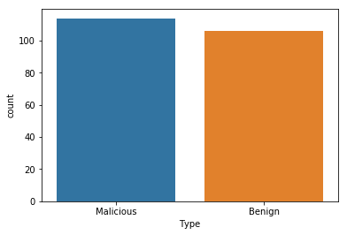

```python
sns.countplot(x="Type",data=dataFrame);
```

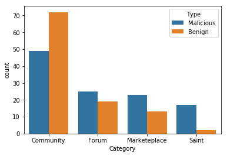

```python
sns.countplot(x="Category",data=dataFrame,hue="Type");
```

```python
# Seprating data for Malicious and Benign Applications
SMSsSentMalicious = dataFrame[dataFrame.Type == 'Malicious'].SMSsSent
notificationsSentMalicious = dataFrame[dataFrame.Type == 'Malicious'].notificationsSent
internetUsedMalicious = dataFrame[dataFrame.Type == 'Malicious'].internetUsed

SMSsSentBenign = dataFrame[dataFrame.Type != 'Malicious'].SMSsSent
notificationsSentBenign = dataFrame[dataFrame.Type != 'Malicious'].notificationsSent
internetUsedBenign = dataFrame[dataFrame.Type != 'Malicious'].internetUsed
```

```
Text(0.5,1,'Side-by-Side Histogram For Malicious and Benign Applications')
```

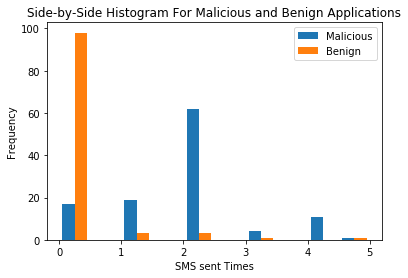

```python
# Assign colors for each type of Applications
names = ['Malicious', 'Benign']

# Make the histogram using a list of lists
plt.hist([SMSsSentMalicious, SMSsSentBenign], label=names)

# Plot formatting
plt.legend()
plt.xlabel('SMS sent Times')
plt.ylabel('Frequency')
plt.title('Side-by-Side Histogram For Malicious and Benign Applications')
```

```
Text(0.5,1,'Side-by-Side Histogram For Malicious and Benign Applications')
```

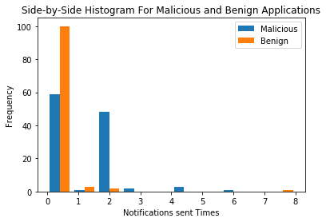

```python
# Assign colors for each type of Applications
names = ['Malicious', 'Benign']

# Make the histogram using a list of lists
plt.hist([notificationsSentMalicious, notificationsSentBenign], label=names)

# Plot formatting
plt.legend()
plt.xlabel('Notifications sent Times')
plt.ylabel('Frequency')
plt.title('Side-by-Side Histogram For Malicious and Benign Applications')
```

```
Text(0.5,1,'Side-by-Side Histogram For Malicious and Benign Applications')
```

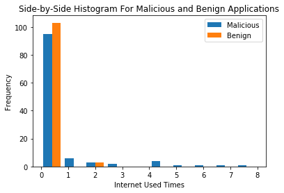

```python
# Assign colors for each type of Applications
names = ['Malicious', 'Benign']

# Make the histogram using a list of lists
plt.hist([internetUsedMalicious, internetUsedBenign], label=names)

# Plot formatting
plt.legend()
plt.xlabel('Internet Used Times')
plt.ylabel('Frequency')
plt.title('Side-by-Side Histogram For Malicious and Benign Applications')
```

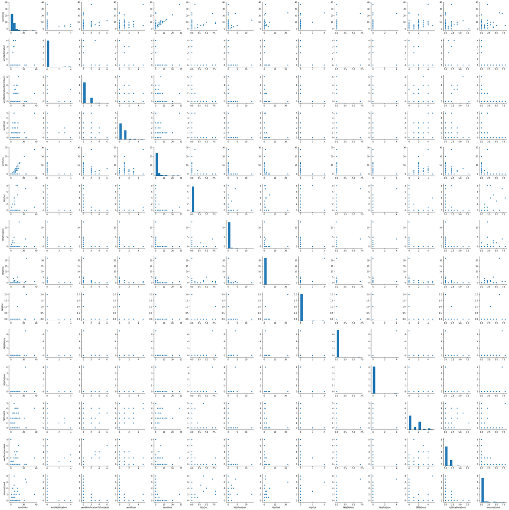

```python
sns.pairplot(dataFrame);
```

```python
dataFrame.describe()
```

|  | numSinks | sendNotification | sendNotificationToContacts | sendPush | sendSms | httpGet | httpPostJson | httpPost | httpPut | httpDelete | httpPutJson | SMSsSent | notificationsSent | internetUsed |
| --- | --- | --- | --- | --- | --- | --- | --- | --- | --- | --- | --- | --- | --- | --- |
| count | 220.000000 | 220.000000 | 220.000000 | 220.000000 | 220.00000 | 220.000000 | 220.000000 | 220.000000 | 220.000000 | 220.000000 | 220.000000 | 220.000000 | 220.000000 | 220.000000 |
| mean | 3.250000 | 0.090909 | 0.522727 | 0.522727 | 1.50000 | 0.209091 | 0.154545 | 0.186364 | 0.013636 | 0.031818 | 0.018182 | 1.004545 | 0.618182 | 0.300000 |
| std | 4.668582 | 0.557972 | 1.017846 | 0.807743 | 3.17021 | 1.056361 | 1.026466 | 1.560586 | 0.150480 | 0.471940 | 0.269680 | 1.229388 | 1.142630 | 1.102509 |
| min | 0.000000 | 0.000000 | 0.000000 | 0.000000 | 0.00000 | 0.000000 | 0.000000 | 0.000000 | 0.000000 | 0.000000 | 0.000000 | 0.000000 | 0.000000 | 0.000000 |
| 25% | 0.000000 | 0.000000 | 0.000000 | 0.000000 | 0.00000 | 0.000000 | 0.000000 | 0.000000 | 0.000000 | 0.000000 | 0.000000 | 0.000000 | 0.000000 | 0.000000 |
| 50% | 2.000000 | 0.000000 | 0.000000 | 0.000000 | 0.00000 | 0.000000 | 0.000000 | 0.000000 | 0.000000 | 0.000000 | 0.000000 | 0.000000 | 0.000000 | 0.000000 |
| 75% | 5.000000 | 0.000000 | 0.000000 | 1.000000 | 2.00000 | 0.000000 | 0.000000 | 0.000000 | 0.000000 | 0.000000 | 0.000000 | 2.000000 | 2.000000 | 0.000000 |
| max | 37.000000 | 4.000000 | 6.000000 | 5.000000 | 28.00000 | 8.000000 | 13.000000 | 22.000000 | 2.000000 | 7.000000 | 4.000000 | 5.000000 | 8.000000 | 8.000000 |

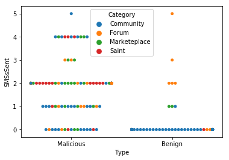

```python
sns.swarmplot(x="Type", y="SMSsSent", hue="Category", data=dataFrame)
```

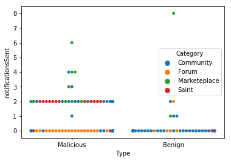

```python
sns.swarmplot(x="Type", y="notificationsSent", hue="Category", data=dataFrame)
```

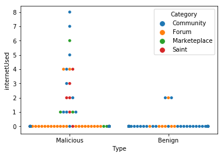

```python
sns.swarmplot(x="Type", y="internetUsed", hue="Category", data=dataFrame)
```

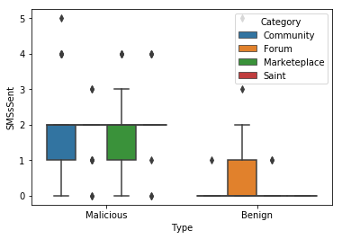

```python
sns.boxplot(data=dataFrame, x="Type", y="SMSsSent", hue ="Category");
```

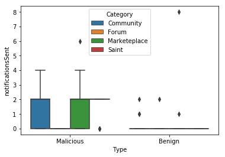

```python
sns.boxplot(data=dataFrame, x="Type", y="notificationsSent", hue ="Category");
```

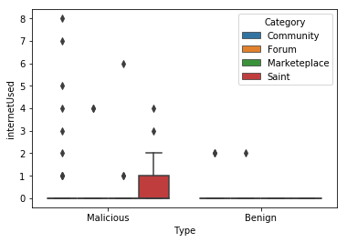

```python
sns.boxplot(data=dataFrame, x="Type", y="internetUsed", hue ="Category");
```

A bar plot represents an estimate of central tendency for a numeric variable with the height of each rectangle and provides some indication of the uncertainty around that estimate using error bars.

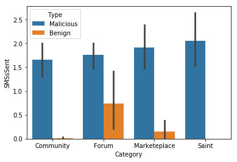

```python
#sns.boxplot(data=dataFrame, x="Type", y="SMSsSent", hue ="Category");
sns.barplot(hue="Type", y="SMSsSent", x="Category", data=dataFrame);
```

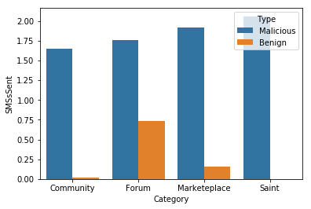

```python
#sns.boxplot(data=dataFrame, x="Type", y="SMSsSent", hue ="Category");
sns.barplot(hue="Type", y="SMSsSent", x="Category", data=dataFrame,ci=None);
```

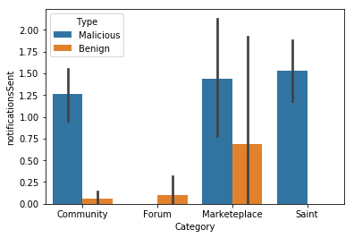

```python
sns.barplot(hue="Type", y="notificationsSent", x="Category", data=dataFrame);
```

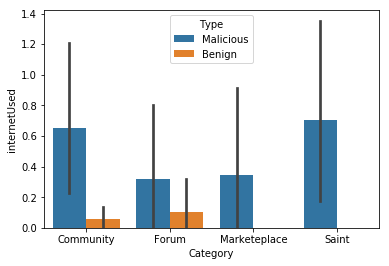

```python
sns.barplot(hue="Type", y="internetUsed", x="Category", data=dataFrame);
```

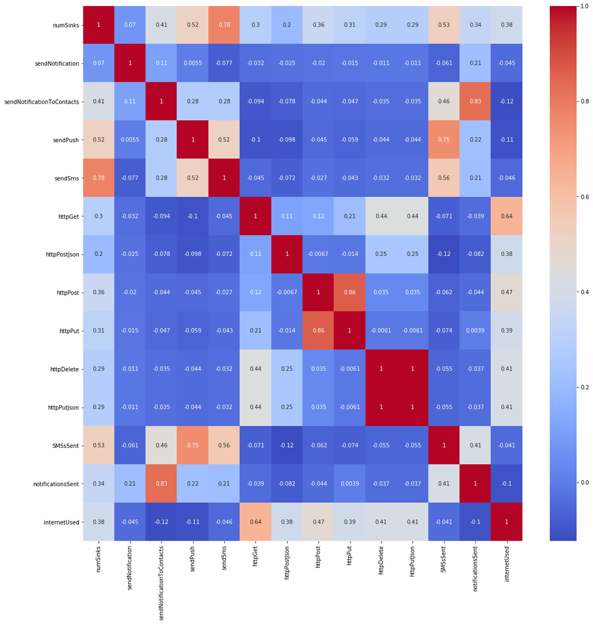

```python
plt.figure(figsize = (18,18))
sns.heatmap(dataFrame.corr(),cmap='coolwarm',annot=True)
```

```python
dataFrame.columns
```

```
Index(['App_Name', 'Type', 'Category', 'numSinks', 'sendNotification',
       'sendNotificationToContacts', 'sendPush', 'sendSms', 'httpGet',
       'httpPostJson', 'httpPost', 'httpPut', 'httpDelete', 'httpPutJson',
       'SMSsSent', 'notificationsSent', 'internetUsed'],
      dtype='object')
```

```python
dataFrame["Category"] = (dataFrame["Category"] == "Community").astype(np.int)
```

```python
dataFrame[['SMSsSent', 'notificationsSent', 'internetUsed', 'Category']].head()
```

|  | SMSsSent | notificationsSent | internetUsed | Category |
| --- | --- | --- | --- | --- |
| 0 | 0 | 1 | 0 | 1 |
| 1 | 2 | 2 | 0 | 1 |
| 2 | 2 | 0 | 0 | 1 |
| 3 | 0 | 0 | 5 | 1 |
| 4 | 2 | 2 | 0 | 1 |

```python
dataFrame.head()
```

|  | App_Name | Type | Category | numSinks | sendNotification | sendNotificationToContacts | sendPush | sendSms | httpGet | httpPostJson | httpPost | httpPut | httpDelete | httpPutJson | SMSsSent | notificationsSent | internetUsed |
| --- | --- | --- | --- | --- | --- | --- | --- | --- | --- | --- | --- | --- | --- | --- | --- | --- | --- |
| 0 | beacon-control | Malicious | 1 | 4 | 4 | 0 | 0 | 0 | 0 | 0 | 0 | 0 | 0 | 0 | 0 | 1 | 0 |
| 1 | bon-voyage | Malicious | 1 | 5 | 0 | 2 | 1 | 2 | 0 | 0 | 0 | 0 | 0 | 0 | 2 | 2 | 0 |
| 2 | close-the-valve | Malicious | 1 | 4 | 0 | 0 | 1 | 3 | 0 | 0 | 0 | 0 | 0 | 0 | 2 | 0 | 0 |
| 3 | curb-energy-monitor | Malicious | 1 | 5 | 0 | 0 | 0 | 0 | 3 | 2 | 0 | 0 | 0 | 0 | 0 | 0 | 5 |
| 4 | door-jammed-notification | Malicious | 1 | 5 | 0 | 2 | 1 | 2 | 0 | 0 | 0 | 0 | 0 | 0 | 2 | 2 | 0 |

```python
dataFrame.columns
```

```
Index(['App_Name', 'Type', 'Category', 'numSinks', 'sendNotification',
       'sendNotificationToContacts', 'sendPush', 'sendSms', 'httpGet',
       'httpPostJson', 'httpPost', 'httpPut', 'httpDelete', 'httpPutJson',
       'SMSsSent', 'notificationsSent', 'internetUsed'],
      dtype='object')
```

```python
X = dataFrame[['SMSsSent', 'notificationsSent', 'internetUsed', 'Category', 'numSinks', 'sendNotification',
       'sendNotificationToContacts', 'sendPush', 'sendSms', 'httpGet',
       'httpPostJson', 'httpPost', 'httpPut', 'httpDelete', 'httpPutJson']]
y = dataFrame.Type
```

# Training and Testing Machine Learning Algorithms on Features of IoT Applications

**Splitting the data by making two stratified 70% training and 30% testing sets. Setting the Random_state to 100. This will regenerate same set of training and testing sets whenever we rerun.**

```python
from sklearn.model_selection import train_test_split
```

```python
X_train, X_test, y_train, y_test = train_test_split(X, y, test_size = 0.30, random_state=100, stratify =y)
```

```python
y_train.describe()
```

```
count           154
unique            2
top       Malicious
freq             80
Name: Type, dtype: object
```

```python
y_test.describe()
```

```
count            66
unique            2
top       Malicious
freq             34
Name: Type, dtype: object
```

```python
from sklearn.naive_bayes import BernoulliNB
from sklearn.linear_model import LogisticRegression
from sklearn.tree import DecisionTreeClassifier
from sklearn.neighbors import KNeighborsClassifier
from sklearn import svm
from sklearn import metrics
```

# Logistic Regression

```python
objLG = LogisticRegression()
objLG.fit(X_train, y_train)
y_pred = objLG.predict(X_test)
```

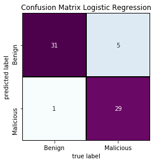

```python
faceLabels = ['Benign','Malicious']
mat = metrics.confusion_matrix(y_test, y_pred)
sns.heatmap(mat.T, square=True, annot=True, fmt='d', cbar=False,
            xticklabels = faceLabels, cmap="BuPu", linecolor='black', linewidths=1,
            yticklabels = faceLabels)
plt.xlabel('true label')
plt.ylabel('predicted label');
plt.title('Confusion Matrix Logistic Regression')
plt.show()
```

```python
print("Accuracy : ",metrics.accuracy_score(y_test, y_pred))
print(metrics.classification_report(y_test, y_pred))
```

```
Accuracy :  0.9090909090909091
             precision    recall  f1-score   support

     Benign       0.86      0.97      0.91        32
  Malicious       0.97      0.85      0.91        34

avg / total       0.92      0.91      0.91        66
```

# Decision Tree

```python
objDTE = DecisionTreeClassifier(criterion='entropy')
objDTE.fit(X_train, y_train)
y_pred = objDTE.predict(X_test)
```

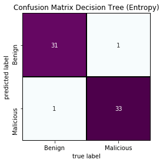

```python
faceLabels = ['Benign','Malicious']
mat = metrics.confusion_matrix(y_test, y_pred)
sns.heatmap(mat.T, square=True, annot=True, fmt='d', cbar=False,
            xticklabels = faceLabels, cmap="BuPu", linecolor='black', linewidths=1,
            yticklabels = faceLabels)
plt.xlabel('true label')
plt.ylabel('predicted label')
plt.title('Confusion Matrix Decision Tree (Entropy)')
plt.show()
```

```python
print("Accuracy : ",metrics.accuracy_score(y_test, y_pred))
print(metrics.classification_report(y_test, y_pred))
```

```
Accuracy :  0.9696969696969697
             precision    recall  f1-score   support

     Benign       0.97      0.97      0.97        32
  Malicious       0.97      0.97      0.97        34

avg / total       0.97      0.97      0.97        66
```

# Plotting the Learnt Decision Tree

```python
import graphviz
from sklearn import tree
```

```python
X.columns
```

```
Index(['SMSsSent', 'notificationsSent', 'internetUsed', 'Category', 'numSinks',
       'sendNotification', 'sendNotificationToContacts', 'sendPush', 'sendSms',
       'httpGet', 'httpPostJson', 'httpPost', 'httpPut', 'httpDelete',
       'httpPutJson'],
      dtype='object')
```

```python
featureNames = X.columns
```

```python
y.values
```

```
array(['Malicious', 'Malicious', 'Malicious', 'Malicious', 'Malicious',
       'Malicious', 'Malicious', 'Malicious', 'Malicious', 'Malicious',
       'Malicious', 'Malicious', 'Malicious', 'Malicious', 'Malicious',
       'Malicious', 'Malicious', 'Malicious', 'Malicious', 'Malicious',
       'Malicious', 'Malicious', 'Malicious', 'Malicious', 'Malicious',
       'Malicious', 'Malicious', 'Malicious', 'Malicious', 'Malicious',
       'Malicious', 'Malicious', 'Malicious', 'Malicious', 'Malicious',
       'Malicious', 'Malicious', 'Malicious', 'Malicious', 'Malicious',
       'Malicious', 'Malicious', 'Malicious', 'Malicious', 'Malicious',
       'Malicious', 'Malicious', 'Malicious', 'Malicious', 'Malicious',
       'Malicious', 'Malicious', 'Malicious', 'Malicious', 'Malicious',
       'Malicious', 'Malicious', 'Malicious', 'Malicious', 'Malicious',
       'Malicious', 'Malicious', 'Malicious', 'Malicious', 'Malicious',
       'Malicious', 'Malicious', 'Malicious', 'Malicious', 'Malicious',
       'Malicious', 'Malicious', 'Malicious', 'Malicious', 'Malicious',
       'Malicious', 'Malicious', 'Malicious', 'Malicious', 'Malicious',
       'Malicious', 'Malicious', 'Malicious', 'Malicious', 'Malicious',
       'Malicious', 'Malicious', 'Malicious', 'Malicious', 'Malicious',
       'Malicious', 'Malicious', 'Malicious', 'Malicious', 'Malicious',
       'Malicious', 'Malicious', 'Malicious', 'Malicious', 'Malicious',
       'Malicious', 'Malicious', 'Malicious', 'Malicious', 'Malicious',
       'Malicious', 'Malicious', 'Malicious', 'Malicious', 'Malicious',
       'Malicious', 'Malicious', 'Malicious', 'Malicious', 'Benign',
       'Benign', 'Benign', 'Benign', 'Benign', 'Benign', 'Benign',
       'Benign', 'Benign', 'Benign', 'Benign', 'Benign', 'Benign',
       'Benign', 'Benign', 'Benign', 'Benign', 'Benign', 'Benign',
       'Benign', 'Benign', 'Benign', 'Benign', 'Benign', 'Benign',
       'Benign', 'Benign', 'Benign', 'Benign', 'Benign', 'Benign',
       'Benign', 'Benign', 'Benign', 'Benign', 'Benign', 'Benign',
       'Benign', 'Benign', 'Benign', 'Benign', 'Benign', 'Benign',
       'Benign', 'Benign', 'Benign', 'Benign', 'Benign', 'Benign',
       'Benign', 'Benign', 'Benign', 'Benign', 'Benign', 'Benign',
       'Benign', 'Benign', 'Benign', 'Benign', 'Benign', 'Benign',
       'Benign', 'Benign', 'Benign', 'Benign', 'Benign', 'Benign',
       'Benign', 'Benign', 'Benign', 'Benign', 'Benign', 'Benign',
       'Benign', 'Benign', 'Benign', 'Benign', 'Benign', 'Benign',
       'Benign', 'Benign', 'Benign', 'Benign', 'Benign', 'Benign',
       'Benign', 'Benign', 'Benign', 'Benign', 'Benign', 'Benign',
       'Benign', 'Benign', 'Benign', 'Benign', 'Benign', 'Benign',
       'Benign', 'Benign', 'Benign', 'Benign', 'Benign', 'Benign',
       'Benign', 'Benign', 'Benign'], dtype=object)
```

```python
target_names = np.array(list(set(y.values)))
target_names
```

```
array(['Malicious', 'Benign'], dtype='<U9')
```

```python
dot_data = tree.export_graphviz(objDTE, out_file=None,
                       feature_names=featureNames,
                       class_names=target_names,
                       filled=True, rounded=True,
                       special_characters=True)
graph = graphviz.Source(dot_data)
graph
```

[figure not shown]

```python
#dot_data = tree.export_graphviz(dtree, out_file=None)
graph = graphviz.Source(dot_data)
graph.render("Decision_Tree")
```

```
'Decision_Tree.pdf'
```

**Before render specifying png format to create a png file for the decision tree.**

```python
graph.format = 'png'
graph.render("Decision_Tree")
```

```
'Decision_Tree.png'
```

# Random Forest

```python
from sklearn.ensemble import RandomForestClassifier
```

```python
rfc = RandomForestClassifier(n_estimators=600)
#n_estimators : integer, optional (default=10) The number of trees in the forest.
```

```python
rfc.fit(X_train,y_train)
y_pred = rfc.predict(X_test)
```

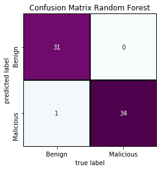

```python
faceLabels = ['Benign','Malicious']
mat = metrics.confusion_matrix(y_test, y_pred)
sns.heatmap(mat.T, square=True, annot=True, fmt='d', cbar=False,
            xticklabels = faceLabels, cmap="BuPu", linecolor='black', linewidths=1,
            yticklabels = faceLabels)
plt.xlabel('true label')
plt.ylabel('predicted label');
plt.title('Confusion Matrix Random Forest')
plt.show()
```

```python
print("Accuracy : ",metrics.accuracy_score(y_test, y_pred))
print(metrics.classification_report(y_test, y_pred))
```

```
Accuracy :  0.9848484848484849
             precision    recall  f1-score   support

     Benign       1.00      0.97      0.98        32
  Malicious       0.97      1.00      0.99        34

avg / total       0.99      0.98      0.98        66
```

# Support Vector Machine

```python
from sklearn import svm
```

```python
clf = svm.SVC()
clf.fit(X_train,y_train)
y_pred = clf.predict(X_test)
```

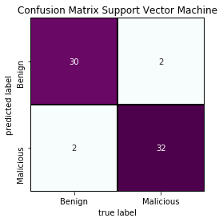

```python
faceLabels = ['Benign','Malicious']
mat = metrics.confusion_matrix(y_test, y_pred)
sns.heatmap(mat.T, square=True, annot=True, fmt='d', cbar=False,
            xticklabels = faceLabels, cmap="BuPu", linecolor='black', linewidths=1,
            yticklabels = faceLabels)
plt.xlabel('true label')
plt.ylabel('predicted label');
plt.title('Confusion Matrix Support Vector Machine')
plt.show()
```

```python
print("Accuracy : ",metrics.accuracy_score(y_test, y_pred))
print(metrics.classification_report(y_test, y_pred))
```

```
Accuracy :  0.9393939393939394
             precision    recall  f1-score   support

     Benign       0.94      0.94      0.94        32
  Malicious       0.94      0.94      0.94        34

avg / total       0.94      0.94      0.94        66
```

```python
#import xgboost as xgb
```

# 10-Fold Cross Validation

```python
#Imort the library for k fold cross validation
from sklearn.model_selection import cross_val_score
```

```python
#Import LogisticRegression and instantiate its object
from sklearn.linear_model import LogisticRegression
logreg = LogisticRegression()
```

```python
print(cross_val_score(logreg, X, y, cv=10, scoring='accuracy').mean())
```

```
0.9321193299454169
```

```python
objDtCV = DecisionTreeClassifier(criterion='entropy')
```

```python
print(cross_val_score(objDtCV, X, y, cv=10, scoring='accuracy').mean())
```

```
0.9590156220591004
```